Data and example taken from: https://becarioprecario.bitbucket.io/inla-gitbook/ch-temporal.html#sec:spacetime

# Setup

## Load packages

```r
library(INLA)
library(DClusterm)
library(tidyverse)
data(brainNM)
```

## Utility functions

@param code model code as a character string

@return name of the loaded DLL

```r
tmb_compile_and_load <- function(code) {
  f <- tempfile(fileext = ".cpp")
  writeLines(mod, f)
  TMB::compile(f)
  dyn.load(TMB::dynlib(tools::file_path_sans_ext(f)))
  basename(tools::file_path_sans_ext(f))
}


nm.adj <- poly2nb(brainst@sp)
adj.mat <- as(nb2mat(nm.adj, style = "B"), "Matrix")

data <- brainst@data
```

Note that area ID = 11 does not have any observed events and very low expected cases. This creates some issues later for the improper models.

```r
filter(data, ID == 11)
```

```
##    Observed   Expected SMR Year FIPS ID      IDLANL  IDLANLre
## 1         0 0.07779381   0 1973  021 11 0.004467493 0.1772291
## 2         0 0.07602697   0 1974  021 11 0.004467493 0.1772291
## 3         0 0.07459628   0 1975  021 11 0.004467493 0.1772291
## 4         0 0.07591790   0 1976  021 11 0.004467493 0.1772291
## 5         0 0.07376734   0 1977  021 11 0.004467493 0.1772291
## 6         0 0.07218504   0 1978  021 11 0.004467493 0.1772291
## 7         0 0.07234843   0 1979  021 11 0.004467493 0.1772291
## 8         0 0.07070030   0 1980  021 11 0.004467493 0.1772291
## 9         0 0.06890410   0 1981  021 11 0.004467493 0.1772291
## 10        0 0.06721256   0 1982  021 11 0.004467493 0.1772291
## 11        0 0.06648948   0 1983  021 11 0.004467493 0.1772291
## 12        0 0.06701812   0 1984  021 11 0.004467493 0.1772291
## 13        0 0.06229518   0 1985  021 11 0.004467493 0.1772291
## 14        0 0.06396584   0 1986  021 11 0.004467493 0.1772291
## 15        0 0.06285902   0 1987  021 11 0.004467493 0.1772291
## 16        0 0.06300778   0 1988  021 11 0.004467493 0.1772291
## 17        0 0.06766094   0 1989  021 11 0.004467493 0.1772291
## 18        0 0.06703746   0 1990  021 11 0.004467493 0.1772291
## 19        0 0.06758709   0 1991  021 11 0.004467493 0.1772291
```

Code factor versions of ID variables

```r
data$ID <- as.integer(data$ID)
data$IDf <- factor(sprintf("%02d", data$ID))
data$Yearf <- factor(data$Year, unique(data$Year))

data$ID.Year <- data$Year - 1973 + 1
data$ID2 <- data$ID

data$area.year <- interaction(data$IDf, data$Year)
data$id.area.year <- as.integer(data$area.year)



# Prior of precision
prec.prior <- list(prec = list(param = c(0.001, 0.001)))
rho.prior <- list(rho = list(param = c(0, 0.15)))
diagval <- INLA:::inla.set.f.default()$diagonal

brain.st <- inla(Observed ~ 1 + f(Year, model = "rw1",
                                  hyper = prec.prior) +
                   f(as.numeric(ID), model = "besag", graph = adj.mat,
                     hyper = prec.prior),
                 data = data, E = Expected, family = "poisson",
                 control.predictor = list(compute = TRUE, link = 1))

summary(brain.st)
```

```
##
## Call:
##    c("inla.core(formula = formula, family = family, contrasts = contrasts, ", " data = data, quantiles = quantiles, E = E, offset = offset, ", " scale = scale, weights = weights, Ntrials = Ntrials, strata = strata, ",
##    " lp.scale = lp.scale, link.covariates = link.covariates, verbose = verbose, ", " lincomb = lincomb, selection = selection, control.compute = control.compute, ", " control.predictor = control.predictor,
##    control.family = control.family, ", " control.inla = control.inla, control.fixed = control.fixed, ", " control.mode = control.mode, control.expert = control.expert, ", " control.hazard = control.hazard,
##    control.lincomb = control.lincomb, ", " control.update = control.update, control.lp.scale = control.lp.scale, ", " control.pardiso = control.pardiso, only.hyperparam = only.hyperparam, ", " inla.call = inla.call,
##    inla.arg = inla.arg, num.threads = num.threads, ", " blas.num.threads = blas.num.threads, keep = keep, working.directory = working.directory, ", " silent = silent, inla.mode = inla.mode, safe = FALSE, debug = debug,
##    ", " .parent.frame = .parent.frame)")
## Time used:
##     Pre = 3.15, Running = 0.451, Post = 0.016, Total = 3.62
## Fixed effects:
##               mean    sd 0.025quant 0.5quant 0.975quant mode kld
## (Intercept) -0.048 0.038     -0.126   -0.047      0.025   NA   0
##
## Random effects:
##   Name     Model
##     Year RW1 model
##    as.numeric(ID) Besags ICAR model
##
## Model hyperparameters:
##                                mean     sd 0.025quant 0.5quant 0.975quant mode
## Precision for Year           500.80 554.54      56.97   335.62    1958.54   NA
## Precision for as.numeric(ID)  59.22  74.05       6.94    37.17     248.24   NA
##
## Marginal log-Likelihood:  -824.58
##  is computed
## Posterior summaries for the linear predictor and the fitted values are computed
## (Posterior marginals needs also 'control.compute=list(return.marginals.predictor=TRUE)')
```

```r
names(inla.models()$group)
```

```
## [1] "exchangeable"    "exchangeablepos" "ar1"             "ar"              "rw1"             "rw2"             "besag"           "iid"
```

Use options control.inla = list(strategy = “gaussian”, int.strategy = “eb”) so that we are doing the same thing as in TMB.

INLA defaults

- Intercept: flat prior
- Fixed effects: N(0, prec = 0.001)

```r
brain.st2 <- inla(Observed ~ 1 +
                    f(as.numeric(ID2), model = "besag", graph = adj.mat,
                      group = ID.Year, control.group = list(model = "rw1"),
                      hyper = prec.prior),
                  data = data, E = Expected, family = "poisson",
                  control.compute = list(config = TRUE),
                  control.inla = list(strategy = "gaussian", int.strategy = "eb"),
                  control.predictor = list(compute = TRUE, link = 1))
```

## Model 1: intercept only

INLA default is a improper flat prior on the intercept

```r
mod <- '
#include <TMB.hpp>

template<class Type>
Type objective_function<Type>::operator() ()
{

  DATA_VECTOR(y);
  DATA_VECTOR(E);

  Type val(0);

  PARAMETER(beta0);
  // beta0 ~ 1

  vector<Type> mu(beta0 + log(E));
  val -= dpois(y, exp(mu), true).sum();

  return val;
}
'

dll <- tmb_compile_and_load(mod)

tmbdata <- list(y = data$Observed,
                E = data$Expected)
tmbpar <- list(beta0 = 0)

obj <- TMB::MakeADFun(data = tmbdata,
                     parameters = tmbpar,
                     random = c(),
                     DLL = dll)
```

```
## Constructing atomic D_lgamma
```

```r
tmbfit <- nlminb(obj$par, obj$fn, obj$gr)
```

```
## outer mgc:  5.218048e-15
```

```r
sdr1 <- TMB::sdreport(obj)
```

```
## outer mgc:  5.218048e-15
## outer mgc:  1.175588
## outer mgc:  1.174413
```

```r
inlafit <- inla(Observed ~ 1,
                data = data, E = Expected, family = "poisson",
                control.inla = list(strategy = "gaussian", int.strategy = "eb"))

mgcvfit1 <- gam(Observed ~ 1, data = data, offset = log(Expected), family = "poisson")
```

```
## Error in gam(Observed ~ 1, data = data, offset = log(Expected), family = "poisson"): could not find function "gam"
```

```r
summary(sdr1)
```

```
##       Estimate Std. Error
## beta0        0   0.029173
```

```r
summary(inlafit)
```

```
##
## Call:
##    c("inla.core(formula = formula, family = family, contrasts = contrasts, ", " data = data, quantiles = quantiles, E = E, offset = offset, ", " scale = scale, weights = weights, Ntrials = Ntrials, strata = strata, ",
##    " lp.scale = lp.scale, link.covariates = link.covariates, verbose = verbose, ", " lincomb = lincomb, selection = selection, control.compute = control.compute, ", " control.predictor = control.predictor,
##    control.family = control.family, ", " control.inla = control.inla, control.fixed = control.fixed, ", " control.mode = control.mode, control.expert = control.expert, ", " control.hazard = control.hazard,
##    control.lincomb = control.lincomb, ", " control.update = control.update, control.lp.scale = control.lp.scale, ", " control.pardiso = control.pardiso, only.hyperparam = only.hyperparam, ", " inla.call = inla.call,
##    inla.arg = inla.arg, num.threads = num.threads, ", " blas.num.threads = blas.num.threads, keep = keep, working.directory = working.directory, ", " silent = silent, inla.mode = inla.mode, safe = FALSE, debug = debug,
##    ", " .parent.frame = .parent.frame)")
## Time used:
##     Pre = 2.59, Running = 0.189, Post = 0.00669, Total = 2.78
## Fixed effects:
##             mean    sd 0.025quant 0.5quant 0.975quant mode kld
## (Intercept)    0 0.029     -0.057        0      0.057   NA   0
##
## Marginal log-Likelihood:  -794.43
##  is computed
## Posterior summaries for the linear predictor and the fitted values are computed
## (Posterior marginals needs also 'control.compute=list(return.marginals.predictor=TRUE)')
```

```r
inlafit$summary.fixed
```

```
##                      mean         sd  0.025quant      0.5quant 0.975quant mode kld
## (Intercept) -5.271518e-07 0.02917156 -0.05717573 -5.271518e-07 0.05717467   NA   0
```

## Model 2: ICAR model

```r
mod <- '
#include <TMB.hpp>

template<class Type>
Type objective_function<Type>::operator() ()
{

  DATA_VECTOR(y);
  DATA_VECTOR(E);

  DATA_SPARSE_MATRIX(Z_space);
  DATA_SPARSE_MATRIX(Q); // Structure matrix for ICAR area model
  DATA_SCALAR(Qrank);


  Type val(0);

  PARAMETER(beta0);
  // beta0 ~ 1

  PARAMETER(log_prec_space);
  // Note: dgamma() is parameterised as (shape, scale); INLA parameterised as (shape, rate)
  val -= dlgamma(log_prec_space, Type(0.001), Type(1.0 / 0.001), true);

  PARAMETER_VECTOR(u_space);
  val -=  Qrank * 0.5 * log_prec_space -
             0.5 * exp(log_prec_space) * (u_space * (Q * u_space)).sum();
  val -= dnorm(u_space.sum(), Type(0.0), Type(0.001) * u_space.size(), true); // soft sum-to-zero constraint

  vector<Type> mu(beta0 +
                  Z_space * u_space +
                  log(E));
  val -= dpois(y, exp(mu), true).sum();

  return val;
}
'

dll <- tmb_compile_and_load(mod)

Q <- diag(rowSums(adj.mat)) - adj.mat
Qadj <- Q + Matrix::Diagonal(ncol(Q), rep(1e-6, ncol(Q)))

tmbdata <- list(y = data$Observed,
                E = data$Expected,
                Z_space = Matrix::sparse.model.matrix(~0 + IDf, data),
                Q = Qadj,
                Qrank = as.integer(rankMatrix(Q)))

tmbpar <- list(beta0 = 0,
               log_prec_space = 0,
               u_space = numeric(ncol(tmbdata$Z_space)))

obj <- TMB::MakeADFun(data = tmbdata,
                      parameters = tmbpar,
                      random = c("beta0", "u_space"),
                      DLL = dll)
```

```
## Constructing atomic D_lgamma
## Constructing atomic D_lgamma
```

```r
tmbfit <- nlminb(obj$par, obj$fn, obj$gr,
                 control = list(iter.max = 1000,
                                eval.max = 1000))
```

[output not shown]

```r
tmbfit <- optim(obj$par, obj$fn, obj$gr, method = "BFGS")
```

[output not shown]

```r
sdr2 <- TMB::sdreport(obj)
```

```
## iter: 1  mgc: 7.987008e-10
## outer mgc:  4.565784e-08
## iter: 1  value: 735.7085 mgc: 0.0124512 ustep: 1
## iter: 2  value: 735.7085 mgc: 4.806646e-07 ustep: 1
## mgc: 9.85878e-14
## outer mgc:  0.00122959
## iter: 1  value: 735.7337 mgc: 0.01243876 ustep: 1
## iter: 2  value: 735.7337 mgc: 4.808129e-07 ustep: 1
## mgc: 4.485301e-14
## outer mgc:  0.001230331
```

```r
summary(sdr2, "all")
```

```
##                    Estimate Std. Error
## log_prec_space  3.454993755 0.90168419
## beta0          -0.036929365 0.03758052
## u_space         0.116341634 0.05679451
## u_space        -0.005569479 0.09728607
## u_space        -0.003047975 0.07857896
## u_space        -0.012811869 0.10193937
## u_space         0.019197311 0.10817920
## u_space        -0.012068927 0.08628529
## u_space        -0.047357624 0.08086184
## u_space        -0.119175956 0.09817941
## u_space        -0.104867950 0.10879945
## u_space         0.006599596 0.08429197
## u_space         0.001514533 0.09252039
## u_space        -0.106317999 0.14601458
## u_space        -0.136769001 0.10502048
## u_space        -0.028572076 0.07155156
## u_space         0.099932294 0.10772916
## u_space        -0.113386078 0.11062324
## u_space         0.095412258 0.10147128
## u_space         0.015925590 0.08228574
## u_space        -0.097450140 0.08612561
## u_space         0.010179504 0.07498311
## u_space         0.068422967 0.07927720
## u_space        -0.017357517 0.08534305
## u_space         0.084443415 0.07571724
## u_space         0.010845101 0.09890691
## u_space         0.027969043 0.06806072
## u_space         0.087735790 0.06953996
## u_space        -0.032312032 0.07470064
## u_space         0.038042081 0.08827612
## u_space         0.002791407 0.10506727
## u_space         0.044646923 0.07100095
## u_space         0.006475032 0.11286903
## u_space         0.100590145 0.08345504
```

```r
prec.prior <- list(prec = list(param = c(0.001, 0.001)))

inlafit <- inla(Observed ~ f(as.integer(IDf), model = "besag",
                             hyper = prec.prior, graph = adj.mat, constr = TRUE,
                             diagonal = diagval),
                data = data, E = Expected, family = "poisson",
                control.inla = list(strategy = "gaussian", int.strategy = "eb"),
                control.compute = list(config = TRUE))


summary(inlafit)
```

```
##
## Call:
##    c("inla.core(formula = formula, family = family, contrasts = contrasts, ", " data = data, quantiles = quantiles, E = E, offset = offset, ", " scale = scale, weights = weights, Ntrials = Ntrials, strata = strata, ",
##    " lp.scale = lp.scale, link.covariates = link.covariates, verbose = verbose, ", " lincomb = lincomb, selection = selection, control.compute = control.compute, ", " control.predictor = control.predictor,
##    control.family = control.family, ", " control.inla = control.inla, control.fixed = control.fixed, ", " control.mode = control.mode, control.expert = control.expert, ", " control.hazard = control.hazard,
##    control.lincomb = control.lincomb, ", " control.update = control.update, control.lp.scale = control.lp.scale, ", " control.pardiso = control.pardiso, only.hyperparam = only.hyperparam, ", " inla.call = inla.call,
##    inla.arg = inla.arg, num.threads = num.threads, ", " blas.num.threads = blas.num.threads, keep = keep, working.directory = working.directory, ", " silent = silent, inla.mode = inla.mode, safe = FALSE, debug = debug,
##    ", " .parent.frame = .parent.frame)")
## Time used:
##     Pre = 2.61, Running = 0.225, Post = 0.0113, Total = 2.85
## Fixed effects:
##               mean    sd 0.025quant 0.5quant 0.975quant mode kld
## (Intercept) -0.037 0.036     -0.108   -0.037      0.034   NA   0
##
## Random effects:
##   Name     Model
##     as.integer(IDf) Besags ICAR model
##
## Model hyperparameters:
##                                mean    sd 0.025quant 0.5quant 0.975quant mode
## Precision for as.integer(IDf) 65.81 90.27       7.68    39.27     289.83   NA
##
## Marginal log-Likelihood:  -818.47
##  is computed
## Posterior summaries for the linear predictor and the fitted values are computed
## (Posterior marginals needs also 'control.compute=list(return.marginals.predictor=TRUE)')
```

```r
inlafit$internal.summary.hyperpar
```

```
##                                       mean        sd 0.025quant 0.5quant 0.975quant mode
## Log precision for as.integer(IDf) 3.725732 0.9250272   2.039271 3.670429   5.669284   NA
```

```r
inlafit$misc$configs$config[[1]]$theta
```

```
## Log precision for as.integer(IDf)
##                          3.451179
```

```r
summary(sdr, "fixed")
```

```
## Error in h(simpleError(msg, call)): error in evaluating the argument 'object' in selecting a method for function 'summary': object 'sdr' not found
```

```r
inlafit$summary.fixed
```

```
##                    mean         sd 0.025quant    0.5quant 0.975quant mode kld
## (Intercept) -0.03697399 0.03607288 -0.1076755 -0.03697399 0.03372755   NA   0
```

```r
inlafit$summary.random[[1]]
```

```
##    ID         mean         sd  0.025quant     0.5quant 0.975quant mode kld
## 1   1  0.116437313 0.05207489  0.01437241  0.116437313 0.21850222   NA   0
## 2   2 -0.005559634 0.09742002 -0.19649937 -0.005559634 0.18538010   NA   0
## 3   3 -0.002906658 0.07123610 -0.14252685 -0.002906658 0.13671353   NA   0
## 4   4 -0.012914007 0.09919297 -0.20732865 -0.012914007 0.18150064   NA   0
## 5   5  0.019297658 0.10565959 -0.18779132  0.019297658 0.22638664   NA   0
## 6   6 -0.012049529 0.08630895 -0.18121197 -0.012049529 0.15711291   NA   0
## 7   7 -0.047331610 0.08069508 -0.20549107 -0.047331610 0.11082785   NA   0
## 8   8 -0.119321422 0.09203425 -0.29970524 -0.119321422 0.06106240   NA   0
## 9   9 -0.105070921 0.09775493 -0.29666705 -0.105070921 0.08652521   NA   0
## 10 10  0.006614886 0.08435794 -0.15872364  0.006614886 0.17195341   NA   0
## 11 11  0.001468852 0.09204380 -0.17893368  0.001468852 0.18187138   NA   0
## 12 12 -0.106496157 0.13999620 -0.38088367 -0.106496157 0.16789136   NA   0
## 13 13 -0.136983312 0.09205921 -0.31741606 -0.136983312 0.04344943   NA   0
## 14 14 -0.028615939 0.07091071 -0.16759838 -0.028615939 0.11036651   NA   0
```

[output cut: 18 more lines]

```r
plot(inlafit$summary.random[[1]][ , 2], summary(sdr, "random")[-1, 1])
```

```
## Error in h(simpleError(msg, call)): error in evaluating the argument 'y' in selecting a method for function 'plot': error in evaluating the argument 'object' in selecting a method for function 'summary': object 'sdr' not found
```

```r
abline(0, 1, col = "red")
```

```
## Error in int_abline(a = a, b = b, h = h, v = v, untf = untf, ...): plot.new has not been called yet
```

```r
plot(inlafit$summary.random[[1]][ , 3], summary(sdr, "random")[-1, 2])
```

```
## Error in h(simpleError(msg, call)): error in evaluating the argument 'y' in selecting a method for function 'plot': error in evaluating the argument 'object' in selecting a method for function 'summary': object 'sdr' not found
```

```r
abline(0, 1, col = "red")
```

```
## Error in int_abline(a = a, b = b, h = h, v = v, untf = untf, ...): plot.new has not been called yet
```

#### INLA with custom Cmatrix

```r
diagval <- INLA:::inla.set.f.default()$diagonal

inlafitC <- inla(Observed ~ f(as.integer(IDf), model = "generic0", Cmatrix = Q,
                              hyper = prec.prior, diagonal = diagval, constr = TRUE),
                 data = data, E = Expected, family = "poisson",
                 control.inla = list(strategy = "gaussian", int.strategy = "eb"),
                 control.compute = list(config = TRUE))
```

These match:

```r
summary(inlafit)
```

```
##
## Call:
##    c("inla.core(formula = formula, family = family, contrasts = contrasts, ", " data = data, quantiles = quantiles, E = E, offset = offset, ", " scale = scale, weights = weights, Ntrials = Ntrials, strata = strata, ",
##    " lp.scale = lp.scale, link.covariates = link.covariates, verbose = verbose, ", " lincomb = lincomb, selection = selection, control.compute = control.compute, ", " control.predictor = control.predictor,
##    control.family = control.family, ", " control.inla = control.inla, control.fixed = control.fixed, ", " control.mode = control.mode, control.expert = control.expert, ", " control.hazard = control.hazard,
##    control.lincomb = control.lincomb, ", " control.update = control.update, control.lp.scale = control.lp.scale, ", " control.pardiso = control.pardiso, only.hyperparam = only.hyperparam, ", " inla.call = inla.call,
##    inla.arg = inla.arg, num.threads = num.threads, ", " blas.num.threads = blas.num.threads, keep = keep, working.directory = working.directory, ", " silent = silent, inla.mode = inla.mode, safe = FALSE, debug = debug,
##    ", " .parent.frame = .parent.frame)")
## Time used:
##     Pre = 2.61, Running = 0.225, Post = 0.0113, Total = 2.85
## Fixed effects:
##               mean    sd 0.025quant 0.5quant 0.975quant mode kld
## (Intercept) -0.037 0.036     -0.108   -0.037      0.034   NA   0
##
## Random effects:
##   Name     Model
##     as.integer(IDf) Besags ICAR model
##
## Model hyperparameters:
##                                mean    sd 0.025quant 0.5quant 0.975quant mode
## Precision for as.integer(IDf) 65.81 90.27       7.68    39.27     289.83   NA
##
## Marginal log-Likelihood:  -818.47
##  is computed
## Posterior summaries for the linear predictor and the fitted values are computed
## (Posterior marginals needs also 'control.compute=list(return.marginals.predictor=TRUE)')
```

```r
summary(inlafitC)
```

```
##
## Call:
##    c("inla.core(formula = formula, family = family, contrasts = contrasts, ", " data = data, quantiles = quantiles, E = E, offset = offset, ", " scale = scale, weights = weights, Ntrials = Ntrials, strata = strata, ",
##    " lp.scale = lp.scale, link.covariates = link.covariates, verbose = verbose, ", " lincomb = lincomb, selection = selection, control.compute = control.compute, ", " control.predictor = control.predictor,
##    control.family = control.family, ", " control.inla = control.inla, control.fixed = control.fixed, ", " control.mode = control.mode, control.expert = control.expert, ", " control.hazard = control.hazard,
##    control.lincomb = control.lincomb, ", " control.update = control.update, control.lp.scale = control.lp.scale, ", " control.pardiso = control.pardiso, only.hyperparam = only.hyperparam, ", " inla.call = inla.call,
##    inla.arg = inla.arg, num.threads = num.threads, ", " blas.num.threads = blas.num.threads, keep = keep, working.directory = working.directory, ", " silent = silent, inla.mode = inla.mode, safe = FALSE, debug = debug,
##    ", " .parent.frame = .parent.frame)")
## Time used:
##     Pre = 2.89, Running = 0.264, Post = 0.0125, Total = 3.16
## Fixed effects:
##               mean    sd 0.025quant 0.5quant 0.975quant mode kld
## (Intercept) -0.037 0.036     -0.108   -0.037      0.034   NA   0
##
## Random effects:
##   Name     Model
##     as.integer(IDf) Generic0 model
##
## Model hyperparameters:
##                                mean    sd 0.025quant 0.5quant 0.975quant mode
## Precision for as.integer(IDf) 65.81 90.27       7.68    39.27     289.83   NA
##
## Marginal log-Likelihood:  -818.47
##  is computed
## Posterior summaries for the linear predictor and the fitted values are computed
## (Posterior marginals needs also 'control.compute=list(return.marginals.predictor=TRUE)')
```

By setting `constr = TRUE` above, INLA infers the rank deficiency of one for the `Cmatrix`.

```r
grep("rank", inlafitC$logfile, value = TRUE)
```

```
## [1] "                computed/guessed rank-deficiency = [1]"
```

#### With `constr = FALSE`

If I change `constr = FALSE`, for the ICAR model INLA still calculates the rank deficiency of 1 based on the number of connected components of the graph. But for the `"generic0"` version, INLA no longer detects rank deficiency of the `Cmatrix`.

```r
inlafit_unconstr <- inla(Observed ~ f(as.integer(IDf), model = "besag",
                                      hyper = prec.prior, graph = adj.mat, constr = FALSE,
                                      diagonal = diagval),
                         data = data, E = Expected, family = "poisson",
                         control.inla = list(strategy = "gaussian", int.strategy = "eb"),
                         control.compute = list(config = TRUE))

inlafitC_unconstr_bad <- inla(Observed ~ f(as.integer(IDf), model = "generic0", Cmatrix = Q,
                                           hyper = prec.prior, diagonal = diagval, constr = FALSE),
                              data = data, E = Expected, family = "poisson",
                              control.inla = list(strategy = "gaussian", int.strategy = "eb"),
                              control.compute = list(config = TRUE))

grep("rank", inlafit_unconstr$logfile, value = TRUE)
```

```
## [1] "                rank-deficiency is *defined* [1]"
```

```r
grep("rank", inlafitC_unconstr_bad$logfile, value = TRUE)
```

```
## [1] "                computed/guessed rank-deficiency = [0]"
```

Consequently, the precision estimate is different:

```r
summary(inlafit_unconstr)
```

```
##
## Call:
##    c("inla.core(formula = formula, family = family, contrasts = contrasts, ", " data = data, quantiles = quantiles, E = E, offset = offset, ", " scale = scale, weights = weights, Ntrials = Ntrials, strata = strata, ",
##    " lp.scale = lp.scale, link.covariates = link.covariates, verbose = verbose, ", " lincomb = lincomb, selection = selection, control.compute = control.compute, ", " control.predictor = control.predictor,
##    control.family = control.family, ", " control.inla = control.inla, control.fixed = control.fixed, ", " control.mode = control.mode, control.expert = control.expert, ", " control.hazard = control.hazard,
##    control.lincomb = control.lincomb, ", " control.update = control.update, control.lp.scale = control.lp.scale, ", " control.pardiso = control.pardiso, only.hyperparam = only.hyperparam, ", " inla.call = inla.call,
##    inla.arg = inla.arg, num.threads = num.threads, ", " blas.num.threads = blas.num.threads, keep = keep, working.directory = working.directory, ", " silent = silent, inla.mode = inla.mode, safe = FALSE, debug = debug,
##    ", " .parent.frame = .parent.frame)")
## Time used:
##     Pre = 3.02, Running = 0.217, Post = 0.0104, Total = 3.25
## Fixed effects:
##               mean     sd 0.025quant 0.5quant 0.975quant mode kld
## (Intercept) -0.037 17.676    -34.681   -0.037     34.608   NA   0
##
## Random effects:
##   Name     Model
##     as.integer(IDf) Besags ICAR model
##
## Model hyperparameters:
##                                mean    sd 0.025quant 0.5quant 0.975quant mode
## Precision for as.integer(IDf) 67.52 93.54       7.81    40.08     299.39   NA
##
## Marginal log-Likelihood:  -812.89
##  is computed
## Posterior summaries for the linear predictor and the fitted values are computed
## (Posterior marginals needs also 'control.compute=list(return.marginals.predictor=TRUE)')
```

```r
summary(inlafitC_unconstr_bad)
```

```
##
## Call:
##    c("inla.core(formula = formula, family = family, contrasts = contrasts, ", " data = data, quantiles = quantiles, E = E, offset = offset, ", " scale = scale, weights = weights, Ntrials = Ntrials, strata = strata, ",
##    " lp.scale = lp.scale, link.covariates = link.covariates, verbose = verbose, ", " lincomb = lincomb, selection = selection, control.compute = control.compute, ", " control.predictor = control.predictor,
##    control.family = control.family, ", " control.inla = control.inla, control.fixed = control.fixed, ", " control.mode = control.mode, control.expert = control.expert, ", " control.hazard = control.hazard,
##    control.lincomb = control.lincomb, ", " control.update = control.update, control.lp.scale = control.lp.scale, ", " control.pardiso = control.pardiso, only.hyperparam = only.hyperparam, ", " inla.call = inla.call,
##    inla.arg = inla.arg, num.threads = num.threads, ", " blas.num.threads = blas.num.threads, keep = keep, working.directory = working.directory, ", " silent = silent, inla.mode = inla.mode, safe = FALSE, debug = debug,
##    ", " .parent.frame = .parent.frame)")
## Time used:
##     Pre = 2.67, Running = 0.213, Post = 0.0113, Total = 2.89
## Fixed effects:
##               mean     sd 0.025quant 0.5quant 0.975quant mode kld
## (Intercept) -0.031 17.678     -34.68   -0.031     34.618   NA   0
##
## Random effects:
##   Name     Model
##     as.integer(IDf) Generic0 model
##
## Model hyperparameters:
##                                 mean     sd 0.025quant 0.5quant 0.975quant mode
## Precision for as.integer(IDf) 167.00 361.37      10.99    74.06     909.84   NA
##
## Marginal log-Likelihood:  -811.87
##  is computed
## Posterior summaries for the linear predictor and the fitted values are computed
## (Posterior marginals needs also 'control.compute=list(return.marginals.predictor=TRUE)')
```

We need to specify `f(..., rankdef = 1)` for the results to align

```r
inlafitC_unconstr <- inla(Observed ~ f(as.integer(IDf), model = "generic0", Cmatrix = Q,
                                       hyper = prec.prior, diagonal = diagval, constr = FALSE, rankdef = 1),
                          data = data, E = Expected, family = "poisson",
                          control.inla = list(strategy = "gaussian", int.strategy = "eb"),
                          control.compute = list(config = TRUE))

grep("rank", inlafitC_unconstr$logfile, value = TRUE)
```

```
## [1] "                rank-deficiency is *defined* [1]"
```

```r
summary(inlafit_unconstr)
```

```
##
## Call:
##    c("inla.core(formula = formula, family = family, contrasts = contrasts, ", " data = data, quantiles = quantiles, E = E, offset = offset, ", " scale = scale, weights = weights, Ntrials = Ntrials, strata = strata, ",
##    " lp.scale = lp.scale, link.covariates = link.covariates, verbose = verbose, ", " lincomb = lincomb, selection = selection, control.compute = control.compute, ", " control.predictor = control.predictor,
##    control.family = control.family, ", " control.inla = control.inla, control.fixed = control.fixed, ", " control.mode = control.mode, control.expert = control.expert, ", " control.hazard = control.hazard,
##    control.lincomb = control.lincomb, ", " control.update = control.update, control.lp.scale = control.lp.scale, ", " control.pardiso = control.pardiso, only.hyperparam = only.hyperparam, ", " inla.call = inla.call,
##    inla.arg = inla.arg, num.threads = num.threads, ", " blas.num.threads = blas.num.threads, keep = keep, working.directory = working.directory, ", " silent = silent, inla.mode = inla.mode, safe = FALSE, debug = debug,
##    ", " .parent.frame = .parent.frame)")
## Time used:
##     Pre = 3.02, Running = 0.217, Post = 0.0104, Total = 3.25
## Fixed effects:
##               mean     sd 0.025quant 0.5quant 0.975quant mode kld
## (Intercept) -0.037 17.676    -34.681   -0.037     34.608   NA   0
##
## Random effects:
##   Name     Model
##     as.integer(IDf) Besags ICAR model
##
## Model hyperparameters:
##                                mean    sd 0.025quant 0.5quant 0.975quant mode
## Precision for as.integer(IDf) 67.52 93.54       7.81    40.08     299.39   NA
##
## Marginal log-Likelihood:  -812.89
##  is computed
## Posterior summaries for the linear predictor and the fitted values are computed
## (Posterior marginals needs also 'control.compute=list(return.marginals.predictor=TRUE)')
```

```r
summary(inlafitC_unconstr)
```

```
##
## Call:
##    c("inla.core(formula = formula, family = family, contrasts = contrasts, ", " data = data, quantiles = quantiles, E = E, offset = offset, ", " scale = scale, weights = weights, Ntrials = Ntrials, strata = strata, ",
##    " lp.scale = lp.scale, link.covariates = link.covariates, verbose = verbose, ", " lincomb = lincomb, selection = selection, control.compute = control.compute, ", " control.predictor = control.predictor,
##    control.family = control.family, ", " control.inla = control.inla, control.fixed = control.fixed, ", " control.mode = control.mode, control.expert = control.expert, ", " control.hazard = control.hazard,
##    control.lincomb = control.lincomb, ", " control.update = control.update, control.lp.scale = control.lp.scale, ", " control.pardiso = control.pardiso, only.hyperparam = only.hyperparam, ", " inla.call = inla.call,
##    inla.arg = inla.arg, num.threads = num.threads, ", " blas.num.threads = blas.num.threads, keep = keep, working.directory = working.directory, ", " silent = silent, inla.mode = inla.mode, safe = FALSE, debug = debug,
##    ", " .parent.frame = .parent.frame)")
## Time used:
##     Pre = 3.03, Running = 0.216, Post = 0.0103, Total = 3.26
## Fixed effects:
##               mean     sd 0.025quant 0.5quant 0.975quant mode kld
## (Intercept) -0.037 17.676    -34.681   -0.037     34.608   NA   0
##
## Random effects:
##   Name     Model
##     as.integer(IDf) Generic0 model
##
## Model hyperparameters:
##                                mean    sd 0.025quant 0.5quant 0.975quant mode
## Precision for as.integer(IDf) 67.52 93.54       7.81    40.08     299.39   NA
##
## Marginal log-Likelihood:  -812.89
##  is computed
## Posterior summaries for the linear predictor and the fitted values are computed
## (Posterior marginals needs also 'control.compute=list(return.marginals.predictor=TRUE)')
```

#### MRF in `mgcv`

```r
rownames(Q) <- colnames(Q) <- levels(data$IDf)

mgcvfit2 <- gam(Observed ~ 0 + s(IDf, bs = "mrf", xt = list(penalty = as.matrix(Q))),
                data = data, offset = log(Expected), family = "poisson")

sm <- smoothCon(s(IDf, bs = "mrf", xt = list(penalty = as.matrix(Q))), data,
                scale.penalty = FALSE)

sm_abs <- smoothCon(s(IDf, bs = "mrf", xt = list(penalty = as.matrix(Q))), data,
                absorb.cons = TRUE, scale.penalty = FALSE)

vcov(mgcvfit2)

mgcvfit2 <-
```

```
## Error: <text>:15:0: unexpected end of input
## 13:
## 14: mgcvfit2 <-
##    ^
```

### Model 2b: express as TMB GMRF

```r
mod <- '
#include <TMB.hpp>

template<class Type>
Type objective_function<Type>::operator() ()
{

  using namespace density;

  DATA_VECTOR(y);
  DATA_VECTOR(E);

  DATA_SPARSE_MATRIX(Z_space);
  DATA_SPARSE_MATRIX(Q); // Structure matrix for ICAR area model
  DATA_SCALAR(Qrank);


  Type val(0);

  PARAMETER(beta0);
  // beta0 ~ 1

  PARAMETER(log_prec_space);
  // Note: dgamma() is parameterised as (shape, scale); INLA parameterised as (shape, rate)
  val -= dlgamma(log_prec_space, Type(0.001), Type(1.0 / 0.001), true);

  PARAMETER_VECTOR(u_space);
  val +=  SCALE(GMRF(Q), exp(-0.5 * log_prec_space))(u_space);
  val -= -(Q.cols() - Qrank) * 0.5 * (log_prec_space - log(2 * PI)); // adjust GMRF for rank deficiency
  val -= dnorm(sum(u_space), Type(0.0), Type(0.001) * u_space.size(), true); // soft sum-to-zero constraint

  vector<Type> mu(beta0 +
                  Z_space * u_space +
                  log(E));
  val -= dpois(y, exp(mu), true).sum();

  return val;
}
'

dll <- tmb_compile_and_load(mod)

Q <- diag(rowSums(adj.mat)) - adj.mat

tmbdata <- list(y = data$Observed,
                E = data$Expected,
                Z_space = Matrix::sparse.model.matrix(~0 + IDf, data),
                Q = Q,
                Qrank = as.integer(rankMatrix(Q)))

tmbpar <- list(beta0 = 0,
               log_prec_space = 0,
               u_space = numeric(ncol(tmbdata$Z_space)))

obj <- TMB::MakeADFun(data = tmbdata,
                      parameters = tmbpar,
                      random = c("beta0", "u_space"),
                      DLL = dll)
```

```
## Constructing atomic D_lgamma
## Constructing atomic D_lgamma
```

```r
tmbfit <- nlminb(obj$par, obj$fn, obj$gr,
                 control = list(iter.max = 1000,
                                eval.max = 1000))
```

[output not shown]

```r
tmbfit <- optim(obj$par, obj$fn, obj$gr, method = "BFGS")
```

[output not shown]

```r
sdr2b <- TMB::sdreport(obj)
```

```
## iter: 1  mgc: 7.987261e-10
## outer mgc:  4.565786e-08
## iter: 1  value: 761.3238 mgc: 0.01245121 ustep: 1
## iter: 2  value: 761.3238 mgc: 4.806641e-07 ustep: 1
## mgc: 1.518785e-13
## outer mgc:  0.00122959
## iter: 1  value: 761.3489 mgc: 0.01243876 ustep: 1
## iter: 2  value: 761.3489 mgc: 4.808122e-07 ustep: 1
## mgc: 3.091971e-14
## outer mgc:  0.00123033
```

```r
summary(sdr2b, "all")
```

```
##                    Estimate Std. Error
## log_prec_space  3.454994987 0.90168437
## beta0          -0.036929359 0.03758052
## u_space         0.116341626 0.05679451
## u_space        -0.005569504 0.09728603
## u_space        -0.003048042 0.07857893
## u_space        -0.012811814 0.10193935
## u_space         0.019197287 0.10817919
## u_space        -0.012068942 0.08628526
## u_space        -0.047357667 0.08086183
## u_space        -0.119175959 0.09817940
## u_space        -0.104867964 0.10879944
## u_space         0.006599599 0.08429194
## u_space         0.001514570 0.09252036
## u_space        -0.106318067 0.14601458
## u_space        -0.136768980 0.10502046
## u_space        -0.028572076 0.07155153
## u_space         0.099932313 0.10772913
## u_space        -0.113386096 0.11062322
## u_space         0.095412270 0.10147126
## u_space         0.015925639 0.08228571
## u_space        -0.097450131 0.08612558
## u_space         0.010179499 0.07498308
## u_space         0.068422990 0.07927717
## u_space        -0.017357545 0.08534302
## u_space         0.084443436 0.07571722
## u_space         0.010845181 0.09890689
## u_space         0.027969057 0.06806070
## u_space         0.087735791 0.06953994
## u_space        -0.032312076 0.07470062
## u_space         0.038042045 0.08827609
## u_space         0.002791464 0.10506725
## u_space         0.044646927 0.07100092
## u_space         0.006475053 0.11286901
## u_space         0.100590115 0.08345502
```

Hyper parameters

```r
c(inlafit$misc$theta.mode,
  sqrt(diag(inlafit$misc$cov.intern)))
```

```
## [1] 3.4511795 0.9189193
```

```r
summary(sdr2, "fixed")
```

```
##                Estimate Std. Error
## log_prec_space 3.454994  0.9016842
```

```r
summary(sdr2b, "fixed")
```

```
##                Estimate Std. Error
## log_prec_space 3.454995  0.9016844
```

Intercept

```r
inlafit$summary.fixed[ , 1:2]
```

```
##                    mean         sd
## (Intercept) -0.03697399 0.03607288
```

```r
summary(sdr2, "random")[1, ]
```

```
##    Estimate  Std. Error
## -0.03692936  0.03758052
```

```r
summary(sdr2b, "random")[1, ]
```

```
##    Estimate  Std. Error
## -0.03692936  0.03758052
```

Random effects

```r
inlafit$summary.random[[1]]
```

```
##    ID         mean         sd  0.025quant     0.5quant 0.975quant mode kld
## 1   1  0.116437313 0.05207489  0.01437241  0.116437313 0.21850222   NA   0
## 2   2 -0.005559634 0.09742002 -0.19649937 -0.005559634 0.18538010   NA   0
## 3   3 -0.002906658 0.07123610 -0.14252685 -0.002906658 0.13671353   NA   0
## 4   4 -0.012914007 0.09919297 -0.20732865 -0.012914007 0.18150064   NA   0
## 5   5  0.019297658 0.10565959 -0.18779132  0.019297658 0.22638664   NA   0
## 6   6 -0.012049529 0.08630895 -0.18121197 -0.012049529 0.15711291   NA   0
## 7   7 -0.047331610 0.08069508 -0.20549107 -0.047331610 0.11082785   NA   0
## 8   8 -0.119321422 0.09203425 -0.29970524 -0.119321422 0.06106240   NA   0
## 9   9 -0.105070921 0.09775493 -0.29666705 -0.105070921 0.08652521   NA   0
## 10 10  0.006614886 0.08435794 -0.15872364  0.006614886 0.17195341   NA   0
## 11 11  0.001468852 0.09204380 -0.17893368  0.001468852 0.18187138   NA   0
## 12 12 -0.106496157 0.13999620 -0.38088367 -0.106496157 0.16789136   NA   0
## 13 13 -0.136983312 0.09205921 -0.31741606 -0.136983312 0.04344943   NA   0
## 14 14 -0.028615939 0.07091071 -0.16759838 -0.028615939 0.11036651   NA   0
```

[output cut: 18 more lines]

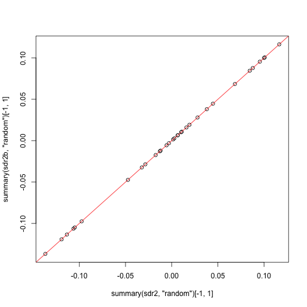

```r
plot(summary(sdr2, "random")[-1, 1], summary(sdr2b, "random")[-1, 1])
abline(0, 1, col = "red")
```

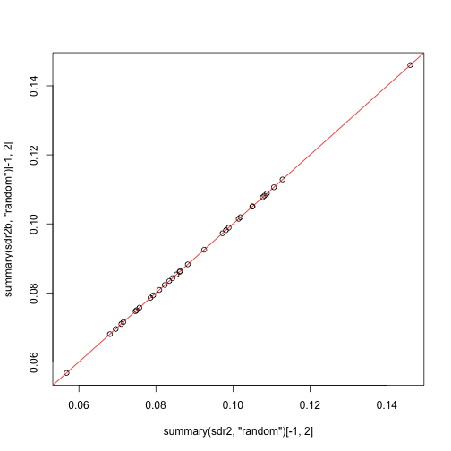

```r
plot(summary(sdr2, "random")[-1, 2], summary(sdr2b, "random")[-1, 2])
abline(0, 1, col = "red")
```

### Model 2c: non-centered parameterisation

```r
mod <- '
#include <TMB.hpp>

template<class Type>
Type objective_function<Type>::operator() ()
{

  using namespace density;

  DATA_VECTOR(y);
  DATA_VECTOR(E);

  DATA_SPARSE_MATRIX(Z_space);
  DATA_SPARSE_MATRIX(Q); // Structure matrix for ICAR area model

  Type val(0);

  PARAMETER(beta0);
  // beta0 ~ 1

  PARAMETER(log_prec_space);
  // Note: TMB dlgamma() is parameterised as (shape, scale); INLA parameterised as (shape, rate)
  val -= dlgamma(log_prec_space, Type(0.001), Type(1.0 / 0.001), true);
  Type sigma_space(exp(-0.5 * log_prec_space));

  PARAMETER_VECTOR(u_raw_space);
  vector<Type> u_space(u_raw_space * sigma_space);

  val += GMRF(Q)(u_raw_space);
  val -= dnorm(sum(u_raw_space), Type(0.0), Type(0.001) * u_raw_space.size(), true); // soft sum-to-zero constraint

  vector<Type> mu(beta0 +
                  Z_space * u_space +
                  log(E));
  val -= dpois(y, exp(mu), true).sum();

  ADREPORT(u_space);

  return val;
}
'

dll <- tmb_compile_and_load(mod)

Q <- diag(rowSums(adj.mat)) - adj.mat

tmbdata <- list(y = data$Observed,
                E = data$Expected,
                Z_space = Matrix::sparse.model.matrix(~0 + IDf, data),
                Q = Q)


tmbpar <- list(beta0 = 0,
               log_prec_space = 0,
               u_raw_space = numeric(ncol(tmbdata$Z_space)))

obj <- TMB::MakeADFun(data = tmbdata,
                      parameters = tmbpar,
                      random = c("beta0", "u_raw_space"),
                      DLL = dll)
```

```
## Constructing atomic D_lgamma
## Constructing atomic D_lgamma
```

```r
tmbfit <- nlminb(obj$par, obj$fn, obj$gr)
```

[output not shown]

```r
tmbfit <- optim(obj$par, obj$fn, obj$gr, method = "BFGS")
```

[output not shown]

```r
sdr2c <- TMB::sdreport(obj)
```

```
## iter: 1  mgc: 9.279628e-10
## outer mgc:  4.565742e-08
## iter: 1  value: 815.8107 mgc: 0.02371781 ustep: 1
## iter: 2  value: 815.8107 mgc: 5.580063e-07 ustep: 1
## mgc: 3.282929e-13
## outer mgc:  0.00122959
## iter: 1  value: 815.8048 mgc: 0.02373214 ustep: 1
## iter: 2  value: 815.8048 mgc: 5.590232e-07 ustep: 1
## mgc: 3.214096e-14
## outer mgc:  0.00123033
## outer mgc:  0.1777286
```

```r
summary(sdr2c, "all")
```

```
##                    Estimate Std. Error
## log_prec_space  3.454994987 0.90168437
## beta0          -0.036929359 0.03756763
## u_raw_space     0.654602649 0.33726113
## u_raw_space    -0.031337125 0.54787505
## u_raw_space    -0.017149977 0.44543008
## u_raw_space    -0.072086386 0.56673687
## u_raw_space     0.108014605 0.59986703
## u_raw_space    -0.067906575 0.48803808
## u_raw_space    -0.266460556 0.47922819
## u_raw_space    -0.670550182 0.52848137
## u_raw_space    -0.590045449 0.54931439
## u_raw_space     0.037133014 0.47381670
## u_raw_space     0.008521815 0.52100250
## u_raw_space    -0.598204534 0.78715827
## u_raw_space    -0.769538295 0.52103017
## u_raw_space    -0.160762378 0.39855590
## u_raw_space     0.562274733 0.56902599
## u_raw_space    -0.637973196 0.55679270
## u_raw_space     0.536842461 0.54035944
## u_raw_space     0.089606496 0.46989550
## u_raw_space    -0.548308598 0.43937933
## u_raw_space     0.057275521 0.41905655
## u_raw_space     0.384985769 0.43348488
## u_raw_space    -0.097663196 0.48763002
## u_raw_space     0.475125702 0.41226262
## u_raw_space     0.061021017 0.56424288
## u_raw_space     0.157369459 0.38196837
## u_raw_space     0.493650321 0.35728735
## u_raw_space    -0.181805700 0.43069509
## u_raw_space     0.214045686 0.47321300
## u_raw_space     0.015706330 0.59240296
## u_raw_space     0.251208428 0.39374926
## u_raw_space     0.036432249 0.63544269
## u_raw_space     0.565975895 0.39142775
## u_space         0.116341626 0.05678598
## u_space        -0.005569504 0.09728106
## u_space        -0.003048042 0.07857277
## u_space        -0.012811814 0.10193460
## u_space         0.019197287 0.10817471
```

[output cut: 12 more lines]

```
## u_space         0.015925639 0.08227983
## u_space        -0.097450131 0.08611995
## u_space         0.010179499 0.07497663
## u_space         0.068422990 0.07927106
## u_space        -0.017357545 0.08533735
## u_space         0.084443436 0.07571082
## u_space         0.010845181 0.09890199
## u_space         0.027969057 0.06805358
## u_space         0.087735791 0.06953298
## u_space        -0.032312076 0.07469413
## u_space         0.038042045 0.08827060
## u_space         0.002791464 0.10506264
## u_space         0.044646927 0.07099410
## u_space         0.006475053 0.11286472
## u_space         0.100590115 0.08344921
```

Hyper parameters

```r
summary(sdr2, "fixed")
```

```
##                Estimate Std. Error
## log_prec_space 3.454994  0.9016842
```

```r
summary(sdr2b, "fixed")
```

```
##                Estimate Std. Error
## log_prec_space 3.454995  0.9016844
```

```r
summary(sdr2c, "fixed")
```

```
##                Estimate Std. Error
## log_prec_space 3.454995  0.9016844
```

Intercept

```r
summary(sdr2, "random")[1, ]
```

```
##    Estimate  Std. Error
## -0.03692936  0.03758052
```

```r
summary(sdr2b, "random")[1, ]
```

```
##    Estimate  Std. Error
## -0.03692936  0.03758052
```

```r
summary(sdr2c, "random")[1, ]
```

```
##    Estimate  Std. Error
## -0.03692936  0.03756763
```

Random effects

```r
inlafit$summary.random[[1]]
```

```
##    ID         mean         sd  0.025quant     0.5quant 0.975quant mode kld
## 1   1  0.116437313 0.05207489  0.01437241  0.116437313 0.21850222   NA   0
## 2   2 -0.005559634 0.09742002 -0.19649937 -0.005559634 0.18538010   NA   0
## 3   3 -0.002906658 0.07123610 -0.14252685 -0.002906658 0.13671353   NA   0
## 4   4 -0.012914007 0.09919297 -0.20732865 -0.012914007 0.18150064   NA   0
## 5   5  0.019297658 0.10565959 -0.18779132  0.019297658 0.22638664   NA   0
## 6   6 -0.012049529 0.08630895 -0.18121197 -0.012049529 0.15711291   NA   0
## 7   7 -0.047331610 0.08069508 -0.20549107 -0.047331610 0.11082785   NA   0
## 8   8 -0.119321422 0.09203425 -0.29970524 -0.119321422 0.06106240   NA   0
## 9   9 -0.105070921 0.09775493 -0.29666705 -0.105070921 0.08652521   NA   0
## 10 10  0.006614886 0.08435794 -0.15872364  0.006614886 0.17195341   NA   0
## 11 11  0.001468852 0.09204380 -0.17893368  0.001468852 0.18187138   NA   0
## 12 12 -0.106496157 0.13999620 -0.38088367 -0.106496157 0.16789136   NA   0
## 13 13 -0.136983312 0.09205921 -0.31741606 -0.136983312 0.04344943   NA   0
## 14 14 -0.028615939 0.07091071 -0.16759838 -0.028615939 0.11036651   NA   0
```

[output cut: 18 more lines]

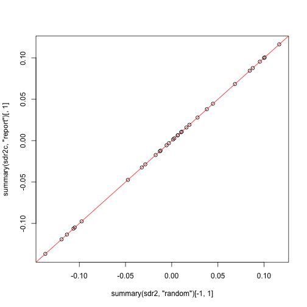

```r
plot(summary(sdr2, "random")[-1, 1], summary(sdr2c, "report")[ , 1])
abline(0, 1, col = "red")
```

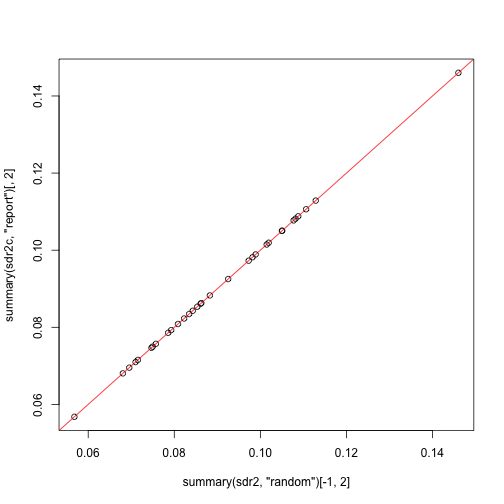

```r
plot(summary(sdr2, "random")[-1 , 2], summary(sdr2c, "report")[ , 2])
abline(0, 1, col = "red")
```

### Model 2d: explicit sum-to-zero constraint

```r
mod <- '
#include <TMB.hpp>

template<class Type>
Type objective_function<Type>::operator() ()
{

  using namespace density;

  DATA_VECTOR(y);
  DATA_VECTOR(E);

  DATA_MATRIX(L_space);
  DATA_SPARSE_MATRIX(Z_space);
  DATA_SPARSE_MATRIX(Q); // Structure matrix for ICAR area model

  Type val(0);

  PARAMETER(beta0);
  // beta0 ~ 1

  PARAMETER(log_prec_space);
  // Note: TMB dlgamma() is parameterised as (shape, scale); INLA parameterised as (shape, rate)
  val -= dlgamma(log_prec_space, Type(0.001), Type(1.0 / 0.001), true);
  Type sigma_space(exp(-0.5 * log_prec_space));

  PARAMETER_VECTOR(u_raw_space);
  vector<Type> u_space(L_space * u_raw_space * sigma_space);

  val += GMRF(Q)(u_raw_space);

  vector<Type> mu(beta0 +
                  Z_space * u_space +
                  log(E));
  val -= dpois(y, exp(mu), true).sum();

  ADREPORT(u_space);

  return val;
}
'

dll <- tmb_compile_and_load(mod)

Q <- diag(rowSums(adj.mat)) - adj.mat

Aconstr <- matrix(1, ncol = ncol(Q))
qrc <- qr(t(Aconstr))
L_space <- qr.Q(qrc,complete=TRUE)[ , (nrow(Aconstr)+1):ncol(Aconstr)]

tmbdata <- list(y = data$Observed,
                E = data$Expected,
                L_space = L_space,
                Z_space = Matrix::sparse.model.matrix(~0 + IDf, data),
                Q = as(t(L_space) %*% Q %*% L_space, "dgCMatrix"))

tmbpar <- list(beta0 = 0,
               log_prec_space = 0,
               u_raw_space = numeric(ncol(tmbdata$L_space)))

obj <- TMB::MakeADFun(data = tmbdata,
                      parameters = tmbpar,
                      random = c("beta0", "u_raw_space"),
                      DLL = dll)
```

```
## Constructing atomic D_lgamma
## Constructing atomic D_lgamma
```

```r
tmbfit <- nlminb(obj$par, obj$fn, obj$gr)
```

[output not shown]

```r
tmbfit <- optim(obj$par, obj$fn, obj$gr, method = "BFGS")
```

[output not shown]

```r
sdr2d <- TMB::sdreport(obj)
```

```
## iter: 1  mgc: 9.28096e-10
## outer mgc:  4.565747e-08
## iter: 1  value: 799.3607 mgc: 0.02371781 ustep: 1
## iter: 2  value: 799.3607 mgc: 5.580061e-07 ustep: 1
## mgc: 9.298118e-14
## outer mgc:  0.00122959
## iter: 1  value: 799.3549 mgc: 0.02373214 ustep: 1
## iter: 2  value: 799.3549 mgc: 5.590231e-07 ustep: 1
## mgc: 3.269607e-14
## outer mgc:  0.00123033
## outer mgc:  0.1730089
```

```r
summary(sdr2d, "all")
```

```
##                    Estimate Std. Error
## log_prec_space  3.454994987 0.90168437
## beta0          -0.036929359 0.03756721
## u_raw_space    -0.129672258 0.55359812
## u_raw_space    -0.115485110 0.45926020
## u_raw_space    -0.170421519 0.56898733
## u_raw_space     0.009679472 0.60688641
## u_raw_space    -0.166241708 0.49738198
## u_raw_space    -0.364795689 0.48822660
## u_raw_space    -0.768885316 0.53531388
## u_raw_space    -0.688380582 0.55490584
## u_raw_space    -0.061202119 0.47949625
## u_raw_space    -0.089813318 0.52550349
## u_raw_space    -0.696539668 0.79430338
## u_raw_space    -0.867873428 0.52611323
## u_raw_space    -0.259097512 0.40466413
## u_raw_space     0.463939600 0.56743101
## u_raw_space    -0.736308330 0.56267201
## u_raw_space     0.438507327 0.53706820
## u_raw_space    -0.008728638 0.46974419
## u_raw_space    -0.646643731 0.44469116
## u_raw_space    -0.041059613 0.42860983
## u_raw_space     0.286650636 0.43162132
## u_raw_space    -0.195998330 0.49815087
## u_raw_space     0.376790569 0.40343930
## u_raw_space    -0.037314116 0.55630210
## u_raw_space     0.059034326 0.38294564
## u_raw_space     0.395315187 0.34950243
## u_raw_space    -0.280140833 0.44160091
## u_raw_space     0.115710553 0.48020219
## u_raw_space    -0.082628803 0.59232582
## u_raw_space     0.152873294 0.39027695
## u_raw_space    -0.061902884 0.64200395
## u_raw_space     0.467640762 0.38800606
## u_space         0.116341626 0.05678571
## u_space        -0.005569504 0.09728089
## u_space        -0.003048042 0.07857257
## u_space        -0.012811814 0.10193444
## u_space         0.019197287 0.10817456
## u_space        -0.012068942 0.08627946
```

[output cut: 11 more lines]

```
## u_space         0.015925639 0.08227964
## u_space        -0.097450131 0.08611977
## u_space         0.010179499 0.07497642
## u_space         0.068422990 0.07927086
## u_space        -0.017357545 0.08533716
## u_space         0.084443436 0.07571062
## u_space         0.010845181 0.09890183
## u_space         0.027969057 0.06805335
## u_space         0.087735791 0.06953275
## u_space        -0.032312076 0.07469392
## u_space         0.038042045 0.08827042
## u_space         0.002791464 0.10506249
## u_space         0.044646927 0.07099388
## u_space         0.006475053 0.11286458
## u_space         0.100590115 0.08344902
```

Hyper parameters

```r
c(inlafit$misc$theta.mode,
  sqrt(diag(inlafit$misc$cov.intern)))
```

```
## [1] 3.4511795 0.9189193
```

```r
summary(sdr2, "fixed")
```

```
##                Estimate Std. Error
## log_prec_space 3.454994  0.9016842
```

```r
summary(sdr2d, "fixed")
```

```
##                Estimate Std. Error
## log_prec_space 3.454995  0.9016844
```

Intercept

```r
inlafit$summary.fixed[ , 1:2]
```

```
##                    mean         sd
## (Intercept) -0.03697399 0.03607288
```

```r
summary(sdr2, "random")[1, ]
```

```
##    Estimate  Std. Error
## -0.03692936  0.03758052
```

```r
summary(sdr2d, "random")[1, ]
```

```
##    Estimate  Std. Error
## -0.03692936  0.03756721
```

Random effects

```r
inlafit$summary.random[[1]]
```

```
##    ID         mean         sd  0.025quant     0.5quant 0.975quant mode kld
## 1   1  0.116437313 0.05207489  0.01437241  0.116437313 0.21850222   NA   0
## 2   2 -0.005559634 0.09742002 -0.19649937 -0.005559634 0.18538010   NA   0
## 3   3 -0.002906658 0.07123610 -0.14252685 -0.002906658 0.13671353   NA   0
## 4   4 -0.012914007 0.09919297 -0.20732865 -0.012914007 0.18150064   NA   0
## 5   5  0.019297658 0.10565959 -0.18779132  0.019297658 0.22638664   NA   0
## 6   6 -0.012049529 0.08630895 -0.18121197 -0.012049529 0.15711291   NA   0
## 7   7 -0.047331610 0.08069508 -0.20549107 -0.047331610 0.11082785   NA   0
## 8   8 -0.119321422 0.09203425 -0.29970524 -0.119321422 0.06106240   NA   0
## 9   9 -0.105070921 0.09775493 -0.29666705 -0.105070921 0.08652521   NA   0
## 10 10  0.006614886 0.08435794 -0.15872364  0.006614886 0.17195341   NA   0
## 11 11  0.001468852 0.09204380 -0.17893368  0.001468852 0.18187138   NA   0
## 12 12 -0.106496157 0.13999620 -0.38088367 -0.106496157 0.16789136   NA   0
## 13 13 -0.136983312 0.09205921 -0.31741606 -0.136983312 0.04344943   NA   0
## 14 14 -0.028615939 0.07091071 -0.16759838 -0.028615939 0.11036651   NA   0
```

[output cut: 18 more lines]

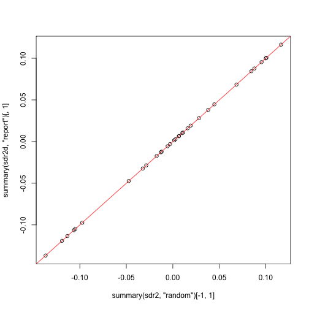

```r
plot(summary(sdr2, "random")[-1, 1], summary(sdr2d, "report")[ , 1])
abline(0, 1, col = "red")
```

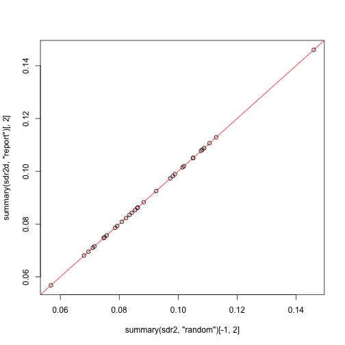

```r
plot(summary(sdr2, "random")[-1 , 2], summary(sdr2d, "report")[ , 2])
abline(0, 1, col = "red")
```

## Model 3: RW1 time trend

```r
mod <- '
#include <TMB.hpp>

template<class Type>
Type objective_function<Type>::operator() ()
{

  using namespace density;

  DATA_VECTOR(y);
  DATA_VECTOR(E);

  DATA_SPARSE_MATRIX(Z_time);
  DATA_SPARSE_MATRIX(R_time); // Structure matrix for RW1

  Type val(0);

  PARAMETER(beta0);
  // beta0 ~ 1

  PARAMETER(log_prec_time);
  val -= dlgamma(log_prec_time, Type(0.001), Type(1.0 / 0.001), true);
  Type sigma_time(exp(-0.5 * log_prec_time));

  PARAMETER_VECTOR(u_raw_time);
  vector<Type> u_time(u_raw_time * sigma_time);

  val += GMRF(R_time)(u_raw_time);
  val -= dnorm(sum(u_raw_time), Type(0.0), Type(0.001) * u_raw_time.size(), true); // soft sum-to-zero constraint

  vector<Type> mu(beta0 +
                  Z_time * u_time +
                  log(E));
  val -= dpois(y, exp(mu), true).sum();

  ADREPORT(u_time);

  return val;
}
'

dll <- tmb_compile_and_load(mod)

Q <- diag(rowSums(adj.mat)) - adj.mat

D_time <- diff(diag(length(levels(data$Yearf))), differences = 1)
R_time <- Matrix::Matrix(t(D_time) %*% D_time)
R_time_adj <- R_time + Matrix::Diagonal(ncol(R_time), 1e-6)

tmbdata <- list(y = data$Observed,
                E = data$Expected,
                Z_time = Matrix::sparse.model.matrix(~0 + Yearf, data),
                R_time = R_time_adj)

tmbpar <- list(beta0 = 0,
               log_prec_time = 0,
               u_raw_time = numeric(ncol(tmbdata$Z_time)))

obj <- TMB::MakeADFun(data = tmbdata,
                      parameters = tmbpar,
                      random = c("beta0", "u_raw_time"),
                      DLL = dll)
```

```
## Error in getParameterOrder(data, parameters, new.env(), DLL = DLL): Error when reading the variable: 'R_time'. Please check data and parameters.
```

```r
tmbfit <- nlminb(obj$par, obj$fn, obj$gr)
```

[output not shown]

```r
sdr3 <- TMB::sdreport(obj)
```

```
## iter: 1  mgc: 9.28096e-10
## outer mgc:  4.565747e-08
## iter: 1  value: 799.3607 mgc: 0.02371781 ustep: 1
## iter: 2  value: 799.3607 mgc: 5.580061e-07 ustep: 1
## mgc: 9.298118e-14
## outer mgc:  0.00122959
## iter: 1  value: 799.3549 mgc: 0.02373214 ustep: 1
## iter: 2  value: 799.3549 mgc: 5.590231e-07 ustep: 1
## mgc: 3.269607e-14
## outer mgc:  0.00123033
## outer mgc:  0.1730089
```

```r
summary(sdr3, "all")
```

```
##                    Estimate Std. Error
## log_prec_space  3.454994987 0.90168437
## beta0          -0.036929359 0.03756721
## u_raw_space    -0.129672258 0.55359812
## u_raw_space    -0.115485110 0.45926020
## u_raw_space    -0.170421519 0.56898733
## u_raw_space     0.009679472 0.60688641
## u_raw_space    -0.166241708 0.49738198
## u_raw_space    -0.364795689 0.48822660
## u_raw_space    -0.768885316 0.53531388
## u_raw_space    -0.688380582 0.55490584
## u_raw_space    -0.061202119 0.47949625
## u_raw_space    -0.089813318 0.52550349
## u_raw_space    -0.696539668 0.79430338
## u_raw_space    -0.867873428 0.52611323
## u_raw_space    -0.259097512 0.40466413
## u_raw_space     0.463939600 0.56743101
## u_raw_space    -0.736308330 0.56267201
## u_raw_space     0.438507327 0.53706820
## u_raw_space    -0.008728638 0.46974419
## u_raw_space    -0.646643731 0.44469116
## u_raw_space    -0.041059613 0.42860983
## u_raw_space     0.286650636 0.43162132
## u_raw_space    -0.195998330 0.49815087
## u_raw_space     0.376790569 0.40343930
## u_raw_space    -0.037314116 0.55630210
## u_raw_space     0.059034326 0.38294564
## u_raw_space     0.395315187 0.34950243
## u_raw_space    -0.280140833 0.44160091
## u_raw_space     0.115710553 0.48020219
## u_raw_space    -0.082628803 0.59232582
## u_raw_space     0.152873294 0.39027695
## u_raw_space    -0.061902884 0.64200395
## u_raw_space     0.467640762 0.38800606
## u_space         0.116341626 0.05678571
## u_space        -0.005569504 0.09728089
## u_space        -0.003048042 0.07857257
## u_space        -0.012811814 0.10193444
## u_space         0.019197287 0.10817456
## u_space        -0.012068942 0.08627946
```

[output cut: 11 more lines]

```
## u_space         0.015925639 0.08227964
## u_space        -0.097450131 0.08611977
## u_space         0.010179499 0.07497642
## u_space         0.068422990 0.07927086
## u_space        -0.017357545 0.08533716
## u_space         0.084443436 0.07571062
## u_space         0.010845181 0.09890183
## u_space         0.027969057 0.06805335
## u_space         0.087735791 0.06953275
## u_space        -0.032312076 0.07469392
## u_space         0.038042045 0.08827042
## u_space         0.002791464 0.10506249
## u_space         0.044646927 0.07099388
## u_space         0.006475053 0.11286458
## u_space         0.100590115 0.08344902
```

```r
inlafit <- inla(Observed ~ f(Year, model = "rw1", hyper = prec.prior),
                data = data, E = Expected, family = "poisson",
                control.inla = list(strategy = "gaussian", int.strategy = "eb"),
                control.compute = list(config = TRUE))

summary(inlafit)
```

```
##
## Call:
##    c("inla.core(formula = formula, family = family, contrasts = contrasts, ", " data = data, quantiles = quantiles, E = E, offset = offset, ", " scale = scale, weights = weights, Ntrials = Ntrials, strata = strata, ",
##    " lp.scale = lp.scale, link.covariates = link.covariates, verbose = verbose, ", " lincomb = lincomb, selection = selection, control.compute = control.compute, ", " control.predictor = control.predictor,
##    control.family = control.family, ", " control.inla = control.inla, control.fixed = control.fixed, ", " control.mode = control.mode, control.expert = control.expert, ", " control.hazard = control.hazard,
##    control.lincomb = control.lincomb, ", " control.update = control.update, control.lp.scale = control.lp.scale, ", " control.pardiso = control.pardiso, only.hyperparam = only.hyperparam, ", " inla.call = inla.call,
##    inla.arg = inla.arg, num.threads = num.threads, ", " blas.num.threads = blas.num.threads, keep = keep, working.directory = working.directory, ", " silent = silent, inla.mode = inla.mode, safe = FALSE, debug = debug,
##    ", " .parent.frame = .parent.frame)")
## Time used:
##     Pre = 2.82, Running = 0.274, Post = 0.0153, Total = 3.11
## Fixed effects:
##              mean   sd 0.025quant 0.5quant 0.975quant mode kld
## (Intercept) -0.01 0.03     -0.068    -0.01      0.048   NA   0
##
## Random effects:
##   Name     Model
##     Year RW1 model
##
## Model hyperparameters:
##                      mean     sd 0.025quant 0.5quant 0.975quant mode
## Precision for Year 482.69 522.63      54.92   327.37    1862.03   NA
##
## Marginal log-Likelihood:  -800.46
##  is computed
## Posterior summaries for the linear predictor and the fitted values are computed
## (Posterior marginals needs also 'control.compute=list(return.marginals.predictor=TRUE)')
```

Hyper parameters

```r
c(inlafit$misc$theta.mode,
  sqrt(diag(inlafit$misc$cov.intern)))
```

```
## [1] 5.8189878 0.9323871
```

```r
summary(sdr3, "fixed")
```

```
##                Estimate Std. Error
## log_prec_space 3.454995  0.9016844
```

Intercept

```r
inlafit$summary.fixed[ , 1:2]
```

```
##                    mean         sd
## (Intercept) -0.01024356 0.02966374
```

```r
summary(sdr3, "random")[1, ]
```

```
##    Estimate  Std. Error
## -0.03692936  0.03756721
```

Random effects

```r
inlafit$summary.random[[1]]
```

```
##      ID         mean         sd   0.025quant     0.5quant 0.975quant mode kld
## 1  1973 -0.014239596 0.07269637 -0.156721854 -0.014239596 0.12824266   NA   0
## 2  1974 -0.021178410 0.06215265 -0.142995363 -0.021178410 0.10063854   NA   0
## 3  1975 -0.049724243 0.05651240 -0.160486517 -0.049724243 0.06103803   NA   0
## 4  1976 -0.078399917 0.05366461 -0.183580621 -0.078399917 0.02678079   NA   0
## 5  1977 -0.080026116 0.05221921 -0.182373882 -0.080026116 0.02232165   NA   0
## 6  1978 -0.079874860 0.05151256 -0.180837618 -0.079874860 0.02108790   NA   0
## 7  1979 -0.085359586 0.05118689 -0.185684043 -0.085359586 0.01496487   NA   0
## 8  1980 -0.074949333 0.05100794 -0.174923058 -0.074949333 0.02502439   NA   0
## 9  1981 -0.075254306 0.05091849 -0.175052713 -0.075254306 0.02454410   NA   0
## 10 1982 -0.040956067 0.05074352 -0.140411539 -0.040956067 0.05849941   NA   0
## 11 1983 -0.011886745 0.05057747 -0.111016768 -0.011886745 0.08724328   NA   0
## 12 1984  0.007470229 0.05045496 -0.091419672  0.007470229 0.10636013   NA   0
## 13 1985  0.060477888 0.05027619 -0.038061626  0.060477888 0.15901740   NA   0
## 14 1986  0.081815923 0.05026290 -0.016697549  0.081815923 0.18032940   NA   0
## 15 1987  0.080664023 0.05050557 -0.018325084  0.080664023 0.17965313   NA   0
## 16 1988  0.093226538 0.05109523 -0.006918273  0.093226538 0.19337135   NA   0
## 17 1989  0.104889904 0.05263082  0.001735394  0.104889904 0.20804441   NA   0
## 18 1990  0.086627651 0.05657857 -0.024264301  0.086627651 0.19751960   NA   0
## 19 1991  0.096677023 0.06564387 -0.031982602  0.096677023 0.22533665   NA   0
```

```r
plot(inlafit$summary.random[[1]][ , 2], summary(sdr3, "report")[ , 1])
```

```
## Error in xy.coords(x, y, xlabel, ylabel, log): 'x' and 'y' lengths differ
```

```r
abline(0, 1, col = "red")
```

```
## Error in int_abline(a = a, b = b, h = h, v = v, untf = untf, ...): plot.new has not been called yet
```

```r
plot(inlafit$summary.random[[1]][ , 3], summary(sdr3, "report")[ , 2])
```

```
## Error in xy.coords(x, y, xlabel, ylabel, log): 'x' and 'y' lengths differ
```

```r
abline(0, 1, col = "red")
```

```
## Error in int_abline(a = a, b = b, h = h, v = v, untf = untf, ...): plot.new has not been called yet
```

#### INLA with custom Cmatrix

```r
inlafitC <- inla(Observed ~ f(ID.Year, model = "generic0", Cmatrix = R_time,
                              hyper = prec.prior, diagonal = diagval, constr = TRUE),
                 data = data, E = Expected, family = "poisson",
                 control.inla = list(strategy = "gaussian", int.strategy = "eb"),
                 control.compute = list(config = TRUE))
```

These match:

```r
summary(inlafit)
```

```
##
## Call:
##    c("inla.core(formula = formula, family = family, contrasts = contrasts, ", " data = data, quantiles = quantiles, E = E, offset = offset, ", " scale = scale, weights = weights, Ntrials = Ntrials, strata = strata, ",
##    " lp.scale = lp.scale, link.covariates = link.covariates, verbose = verbose, ", " lincomb = lincomb, selection = selection, control.compute = control.compute, ", " control.predictor = control.predictor,
##    control.family = control.family, ", " control.inla = control.inla, control.fixed = control.fixed, ", " control.mode = control.mode, control.expert = control.expert, ", " control.hazard = control.hazard,
##    control.lincomb = control.lincomb, ", " control.update = control.update, control.lp.scale = control.lp.scale, ", " control.pardiso = control.pardiso, only.hyperparam = only.hyperparam, ", " inla.call = inla.call,
##    inla.arg = inla.arg, num.threads = num.threads, ", " blas.num.threads = blas.num.threads, keep = keep, working.directory = working.directory, ", " silent = silent, inla.mode = inla.mode, safe = FALSE, debug = debug,
##    ", " .parent.frame = .parent.frame)")
## Time used:
##     Pre = 2.82, Running = 0.274, Post = 0.0153, Total = 3.11
## Fixed effects:
##              mean   sd 0.025quant 0.5quant 0.975quant mode kld
## (Intercept) -0.01 0.03     -0.068    -0.01      0.048   NA   0
##
## Random effects:
##   Name     Model
##     Year RW1 model
##
## Model hyperparameters:
##                      mean     sd 0.025quant 0.5quant 0.975quant mode
## Precision for Year 482.69 522.63      54.92   327.37    1862.03   NA
##
## Marginal log-Likelihood:  -800.46
##  is computed
## Posterior summaries for the linear predictor and the fitted values are computed
## (Posterior marginals needs also 'control.compute=list(return.marginals.predictor=TRUE)')
```

```r
summary(inlafitC)
```

```
##
## Call:
##    c("inla.core(formula = formula, family = family, contrasts = contrasts, ", " data = data, quantiles = quantiles, E = E, offset = offset, ", " scale = scale, weights = weights, Ntrials = Ntrials, strata = strata, ",
##    " lp.scale = lp.scale, link.covariates = link.covariates, verbose = verbose, ", " lincomb = lincomb, selection = selection, control.compute = control.compute, ", " control.predictor = control.predictor,
##    control.family = control.family, ", " control.inla = control.inla, control.fixed = control.fixed, ", " control.mode = control.mode, control.expert = control.expert, ", " control.hazard = control.hazard,
##    control.lincomb = control.lincomb, ", " control.update = control.update, control.lp.scale = control.lp.scale, ", " control.pardiso = control.pardiso, only.hyperparam = only.hyperparam, ", " inla.call = inla.call,
##    inla.arg = inla.arg, num.threads = num.threads, ", " blas.num.threads = blas.num.threads, keep = keep, working.directory = working.directory, ", " silent = silent, inla.mode = inla.mode, safe = FALSE, debug = debug,
##    ", " .parent.frame = .parent.frame)")
## Time used:
##     Pre = 2.91, Running = 0.245, Post = 0.0121, Total = 3.17
## Fixed effects:
##              mean   sd 0.025quant 0.5quant 0.975quant mode kld
## (Intercept) -0.01 0.03     -0.068    -0.01      0.048   NA   0
##
## Random effects:
##   Name     Model
##     ID.Year Generic0 model
##
## Model hyperparameters:
##                         mean     sd 0.025quant 0.5quant 0.975quant mode
## Precision for ID.Year 482.69 522.63      54.92   327.37    1862.03   NA
##
## Marginal log-Likelihood:  -800.46
##  is computed
## Posterior summaries for the linear predictor and the fitted values are computed
## (Posterior marginals needs also 'control.compute=list(return.marginals.predictor=TRUE)')
```

### Model 3b: Explicit sum-to-zero constraint

```r
mod <- '
#include <TMB.hpp>

template<class Type>
Type objective_function<Type>::operator() ()
{

  using namespace density;

  DATA_VECTOR(y);
  DATA_VECTOR(E);

  DATA_MATRIX(L_time);
  DATA_SPARSE_MATRIX(Z_time);
  DATA_SPARSE_MATRIX(LRL_time); // Structure matrix for RW1

  Type val(0);

  PARAMETER(beta0);
  // beta0 ~ 1

  PARAMETER(log_prec_time);
  val -= dlgamma(log_prec_time, Type(0.001), Type(1.0 / 0.001), true);
  Type sigma_time(exp(-0.5 * log_prec_time));

  PARAMETER_VECTOR(u_raw_time);
  vector<Type> u_time(L_time * u_raw_time * sigma_time);

  val += GMRF(LRL_time)(u_raw_time);

  vector<Type> mu(beta0 +
                  Z_time * u_time +
                  log(E));
  val -= dpois(y, exp(mu), true).sum();

  ADREPORT(u_time);

  return val;
}
'


dll <- tmb_compile_and_load(mod)

Aconstr <- matrix(1, ncol = ncol(R_time))
qrc <- qr(t(Aconstr))
L_time <- qr.Q(qrc, complete=TRUE)[ , (nrow(Aconstr)+1):ncol(Aconstr)]

tmbdata <- list(y = data$Observed,
                E = data$Expected,
                L_time = L_time,
                Z_time = Matrix::sparse.model.matrix(~0 + Yearf, data),
                LRL_time = as(t(L_time) %*% R_time %*% L_time, "dgCMatrix"))

tmbpar <- list(beta0 = 0,
               log_prec_time = 0,
               u_raw_time = numeric(ncol(tmbdata$L_time)))

obj <- TMB::MakeADFun(data = tmbdata,
                      parameters = tmbpar,
                      random = c("beta0", "u_raw_time"),
                      DLL = dll)
```

```
## Constructing atomic D_lgamma
## Constructing atomic D_lgamma
```

```r
tmbfit <- nlminb(obj$par, obj$fn, obj$gr)
```

```
## Constructing atomic D_lgamma
## Optimizing tape... Done
## iter: 1  value: 801.4406 mgc: 16.98151 ustep: 1
## iter: 2  value: 801.3052 mgc: 11.98234 ustep: 1
## iter: 3  value: 801.3051 mgc: 0.129481 ustep: 1
## iter: 4  value: 801.3051 mgc: 2.825587e-05 ustep: 1
## iter: 5  mgc: 2.972289e-12
## iter: 1  mgc: 2.972289e-12
## Matching hessian patterns... Done
## outer mgc:  8.376381
## iter: 1  value: 801.8229 mgc: 11.50974 ustep: 1
## iter: 2  value: 801.8208 mgc: 1.584894 ustep: 1
## iter: 3  value: 801.8208 mgc: 0.001950711 ustep: 1
## iter: 4  mgc: 4.163226e-09
## iter: 1  value: 806.5366 mgc: 18.10231 ustep: 1
## iter: 2  value: 806.5315 mgc: 3.087566 ustep: 1
## iter: 3  value: 806.5315 mgc: 0.004885654 ustep: 1
## iter: 4  value: 806.5315 mgc: 1.401383e-08 ustep: 1
## mgc: 1.371125e-14
## iter: 1  mgc: 1.371125e-14
## outer mgc:  2.246708
## iter: 1  value: 809.0774 mgc: 9.130744 ustep: 1
## iter: 2  value: 809.0771 mgc: 0.7500938 ustep: 1
## iter: 3  value: 809.0771 mgc: 0.0003121461 ustep: 1
## iter: 4  mgc: 7.099721e-11
## iter: 1  mgc: 7.099721e-11
## outer mgc:  0.404291
## iter: 1  value: 809.6202 mgc: 2.330868 ustep: 1
## iter: 2  value: 809.6202 mgc: 0.03839271 ustep: 1
## iter: 3  value: 809.6202 mgc: 8.582616e-07 ustep: 1
## iter: 4  mgc: 1.205702e-13
## iter: 1  mgc: 1.205702e-13
## outer mgc:  0.03673776
## iter: 1  value: 809.6754 mgc: 0.2417217 ustep: 1
## iter: 2  value: 809.6754 mgc: 0.0003854534 ustep: 1
## iter: 3  mgc: 8.67999e-11
## iter: 1  mgc: 8.67999e-11
## outer mgc:  7.619606e-05
## iter: 1  value: 809.6753 mgc: 0.0005025133 ustep: 1
## iter: 2  mgc: 1.654864e-09
## iter: 1  mgc: 1.654864e-09
## outer mgc:  5.435952e-08
## iter: 1  mgc: 1.654864e-09
```

```r
sdr3b <- TMB::sdreport(obj)
```

```
## iter: 1  mgc: 1.654864e-09
## outer mgc:  5.435952e-08
## iter: 1  value: 809.677 mgc: 0.007547473 ustep: 1
## iter: 2  value: 809.677 mgc: 3.732298e-07 ustep: 1
## iter: 3  mgc: 6.661338e-14
## outer mgc:  0.001145627
## iter: 1  value: 809.6736 mgc: 0.007552832 ustep: 1
## iter: 2  value: 809.6736 mgc: 3.739172e-07 ustep: 1
## iter: 3  mgc: 5.462297e-14
## outer mgc:  0.001145682
## outer mgc:  0.0524351
```

```r
summary(sdr3b, "all")
```

```
##                   Estimate Std. Error
## log_prec_time  5.819926913 0.93427166
## beta0         -0.010241374 0.02970886
## u_raw_time    -0.340303008 1.08871281
## u_raw_time    -0.863917041 1.01430121
## u_raw_time    -1.389911868 0.98495013
## u_raw_time    -1.419793635 1.01129192
## u_raw_time    -1.417025875 1.02889253
## u_raw_time    -1.517564716 1.02165287
## u_raw_time    -1.326533189 1.02575823
## u_raw_time    -1.331942219 1.02043588
## u_raw_time    -0.702666799 1.02105504
## u_raw_time    -0.169232317 1.02507324
## u_raw_time     0.186108464 1.05960919
## u_raw_time     1.158601663 1.03925667
## u_raw_time     1.550224579 1.07184424
## u_raw_time     1.529308478 1.16580106
## u_raw_time     1.759865065 1.20395636
## u_raw_time     1.973874589 1.23106156
## u_raw_time     1.638993208 1.39117791
## u_raw_time     1.823317259 1.49064774
## u_time        -0.014265303 0.07695862
## u_time        -0.021200916 0.06595329
## u_time        -0.049726215 0.05652280
## u_time        -0.078381214 0.05690575
## u_time        -0.080009105 0.05498376
## u_time        -0.079858324 0.05412832
## u_time        -0.085335451 0.05656950
## u_time        -0.074928488 0.05504278
## u_time        -0.075223160 0.05956872
## u_time        -0.040941670 0.05268751
## u_time        -0.011881375 0.05082891
## u_time         0.007476781 0.05085719
## u_time         0.060455994 0.05487941
## u_time         0.081790718 0.05624031
## u_time         0.080651256 0.05204878
## u_time         0.093211453 0.05330813
## u_time         0.104870204 0.05632900
## u_time         0.086626630 0.05658407
## u_time         0.096668184 0.06623955
```

Hyper parameters

```r
c(inlafit$misc$theta.mode,
  sqrt(diag(inlafit$misc$cov.intern)))
```

```
## [1] 5.8189878 0.9323871
```

```r
summary(sdr3, "fixed")
```

```
##                Estimate Std. Error
## log_prec_space 3.454995  0.9016844
```

```r
summary(sdr3b, "fixed")
```

```
##               Estimate Std. Error
## log_prec_time 5.819927  0.9342717
```

Intercept

```r
inlafit$summary.fixed[ , 1:2]
```

```
##                    mean         sd
## (Intercept) -0.01024356 0.02966374
```

```r
summary(sdr3, "random")[1, ]
```

```
##    Estimate  Std. Error
## -0.03692936  0.03756721
```

```r
summary(sdr3b, "random")[1, ]
```

```
##    Estimate  Std. Error
## -0.01024137  0.02970886
```

Random effects

```r
inlafit$summary.random[[1]]
```

```
##      ID         mean         sd   0.025quant     0.5quant 0.975quant mode kld
## 1  1973 -0.014239596 0.07269637 -0.156721854 -0.014239596 0.12824266   NA   0
## 2  1974 -0.021178410 0.06215265 -0.142995363 -0.021178410 0.10063854   NA   0
## 3  1975 -0.049724243 0.05651240 -0.160486517 -0.049724243 0.06103803   NA   0
## 4  1976 -0.078399917 0.05366461 -0.183580621 -0.078399917 0.02678079   NA   0
## 5  1977 -0.080026116 0.05221921 -0.182373882 -0.080026116 0.02232165   NA   0
## 6  1978 -0.079874860 0.05151256 -0.180837618 -0.079874860 0.02108790   NA   0
## 7  1979 -0.085359586 0.05118689 -0.185684043 -0.085359586 0.01496487   NA   0
## 8  1980 -0.074949333 0.05100794 -0.174923058 -0.074949333 0.02502439   NA   0
## 9  1981 -0.075254306 0.05091849 -0.175052713 -0.075254306 0.02454410   NA   0
## 10 1982 -0.040956067 0.05074352 -0.140411539 -0.040956067 0.05849941   NA   0
## 11 1983 -0.011886745 0.05057747 -0.111016768 -0.011886745 0.08724328   NA   0
## 12 1984  0.007470229 0.05045496 -0.091419672  0.007470229 0.10636013   NA   0
## 13 1985  0.060477888 0.05027619 -0.038061626  0.060477888 0.15901740   NA   0
## 14 1986  0.081815923 0.05026290 -0.016697549  0.081815923 0.18032940   NA   0
## 15 1987  0.080664023 0.05050557 -0.018325084  0.080664023 0.17965313   NA   0
## 16 1988  0.093226538 0.05109523 -0.006918273  0.093226538 0.19337135   NA   0
## 17 1989  0.104889904 0.05263082  0.001735394  0.104889904 0.20804441   NA   0
## 18 1990  0.086627651 0.05657857 -0.024264301  0.086627651 0.19751960   NA   0
## 19 1991  0.096677023 0.06564387 -0.031982602  0.096677023 0.22533665   NA   0
```

```r
plot(summary(sdr3, "report")[ , 1], summary(sdr3b, "report")[ , 1])
```

```
## Error in xy.coords(x, y, xlabel, ylabel, log): 'x' and 'y' lengths differ
```

```r
abline(0, 1, col = "red")
```

```
## Error in int_abline(a = a, b = b, h = h, v = v, untf = untf, ...): plot.new has not been called yet
```

```r
plot(summary(sdr3, "report")[ , 2], summary(sdr3b, "report")[ , 2])
```

```
## Error in xy.coords(x, y, xlabel, ylabel, log): 'x' and 'y' lengths differ
```

```r
abline(0, 1, col = "red")
```

```
## Error in int_abline(a = a, b = b, h = h, v = v, untf = untf, ...): plot.new has not been called yet
```

## Model 4: RW1 time + ICAR space

```r
mod <- '
#include <TMB.hpp>

template<class Type>
Type objective_function<Type>::operator() ()
{

  using namespace density;

  DATA_VECTOR(y);
  DATA_VECTOR(E);

  DATA_SPARSE_MATRIX(Z_time);
  DATA_SPARSE_MATRIX(R_time);

  DATA_SPARSE_MATRIX(Z_space);
  DATA_SPARSE_MATRIX(R_space);

  Type val(0);

  PARAMETER(beta0);
  // beta0 ~ 1

  PARAMETER(log_prec_time);
  val -= dlgamma(log_prec_time, Type(0.001), Type(1.0 / 0.001), true);
  Type sigma_time(exp(-0.5 * log_prec_time));

  PARAMETER_VECTOR(u_raw_time);
  vector<Type> u_time(u_raw_time * sigma_time);

  val += GMRF(R_time)(u_raw_time);
  val -= dnorm(sum(u_raw_time), Type(0.0), Type(0.001) * u_raw_time.size(), true); // soft sum-to-zero constraint

  PARAMETER(log_prec_space);
  val -= dlgamma(log_prec_space, Type(0.001), Type(1.0 / 0.001), true);
  Type sigma_space(exp(-0.5 * log_prec_space));

  PARAMETER_VECTOR(u_raw_space);
  vector<Type> u_space(u_raw_space * sigma_space);

  val += GMRF(R_space)(u_raw_space);
  val -= dnorm(sum(u_raw_space), Type(0.0), Type(0.001) * u_raw_space.size(), true); // soft sum-to-zero constraint

  vector<Type> mu(beta0 +
                  Z_time * u_time +
                  Z_space * u_space +
                  log(E));
  val -= dpois(y, exp(mu), true).sum();

  ADREPORT(u_time);
  ADREPORT(u_space);

  return val;
}
'

dll <- tmb_compile_and_load(mod)

R_space <- diag(rowSums(adj.mat)) - adj.mat
R_space_adj <- R_space + Matrix::Diagonal(ncol(R_space), diagval)

D_time <- diff(diag(length(levels(data$Yearf))), differences = 1)
R_time <- Matrix::Matrix(t(D_time) %*% D_time)
R_time_adj <- R_time + Matrix::Diagonal(ncol(R_time), diagval)

tmbdata <- list(y = data$Observed,
                E = data$Expected,
                Z_time = Matrix::sparse.model.matrix(~0 + Yearf, data),
                R_time = R_time_adj,
                Z_space = Matrix::sparse.model.matrix(~0 + IDf, data),
                R_space = R_space_adj)

tmbpar <- list(beta0 = 0,
               log_prec_time = 0,
               u_raw_time = numeric(ncol(tmbdata$Z_time)),
               log_prec_space = 0,
               u_raw_space = numeric(ncol(tmbdata$Z_space)))

obj <- TMB::MakeADFun(data = tmbdata,
                      parameters = tmbpar,
                      random = c("beta0", "u_raw_time", "u_raw_space"),
                      DLL = dll)
```

```
## Error in getParameterOrder(data, parameters, new.env(), DLL = DLL): Error when reading the variable: 'R_time'. Please check data and parameters.
```

```r
tmbfit <- nlminb(obj$par, obj$fn, obj$gr)
```

```
## iter: 1  value: 1538.265 mgc: 1619.554 ustep: 1
## iter: 2  value: 908.1977 mgc: 1595.887 ustep: 1
## iter: 3  value: 808.3789 mgc: 423.4493 ustep: 1
## iter: 4  value: 801.3893 mgc: 75.01439 ustep: 1
## iter: 5  value: 801.3052 mgc: 6.088415 ustep: 1
## iter: 6  value: 801.3051 mgc: 0.0819104 ustep: 1
## iter: 7  value: 801.3051 mgc: 2.030783e-05 ustep: 1
## iter: 8  mgc: 1.79079e-12
## iter: 1  value: 1538.265 mgc: 1619.554 ustep: 1
## iter: 2  value: 908.1977 mgc: 1595.887 ustep: 1
## iter: 3  value: 808.3789 mgc: 423.4493 ustep: 1
## iter: 4  value: 801.3893 mgc: 75.01439 ustep: 1
## iter: 5  value: 801.3052 mgc: 6.088415 ustep: 1
## iter: 6  value: 801.3051 mgc: 0.0819104 ustep: 1
## iter: 7  value: 801.3051 mgc: 2.030783e-05 ustep: 1
## iter: 8  mgc: 1.79079e-12
## outer mgc:  8.376381
## iter: 1  value: 852.7793 mgc: 536.9752 ustep: 1
## iter: 2  value: 802.984 mgc: 331.8761 ustep: 1
## iter: 3  value: 801.822 mgc: 41.36834 ustep: 1
## iter: 4  value: 801.8208 mgc: 1.108246 ustep: 1
## iter: 5  value: 801.8208 mgc: 0.001142266 ustep: 1
## iter: 6  mgc: 2.03021e-09
## iter: 1  value: 806.5481 mgc: 29.49886 ustep: 1
## iter: 2  value: 806.5315 mgc: 5.180749 ustep: 1
## iter: 3  value: 806.5315 mgc: 0.01590025 ustep: 1
## iter: 4  value: 806.5315 mgc: 2.187437e-07 ustep: 1
## mgc: 2.525757e-14
## iter: 1  value: 806.5481 mgc: 29.49886 ustep: 1
## iter: 2  value: 806.5315 mgc: 5.180749 ustep: 1
## iter: 3  value: 806.5315 mgc: 0.01590025 ustep: 1
## iter: 4  value: 806.5315 mgc: 2.187437e-07 ustep: 1
## mgc: 2.525757e-14
## outer mgc:  2.246708
## iter: 1  value: 809.0771 mgc: 3.040783 ustep: 1
## iter: 2  value: 809.0771 mgc: 0.06387844 ustep: 1
## iter: 3  value: 809.0771 mgc: 2.458166e-06 ustep: 1
## iter: 4  mgc: 9.481305e-14
## iter: 1  value: 809.0771 mgc: 3.040783 ustep: 1
## iter: 2  value: 809.0771 mgc: 0.06387844 ustep: 1
## iter: 3  value: 809.0771 mgc: 2.458166e-06 ustep: 1
## iter: 4  mgc: 9.481305e-14
## outer mgc:  0.404291
## iter: 1  value: 809.6202 mgc: 0.2450647 ustep: 1
## iter: 2  value: 809.6202 mgc: 0.0003961701 ustep: 1
## iter: 3  mgc: 9.207901e-11
## iter: 1  value: 809.6202 mgc: 0.2450647 ustep: 1
## iter: 2  value: 809.6202 mgc: 0.0003961701 ustep: 1
## iter: 3  mgc: 9.207901e-11
## outer mgc:  0.03673776
## iter: 1  value: 809.6754 mgc: 0.0005024952 ustep: 1
## iter: 2  mgc: 1.654574e-09
## iter: 1  value: 809.6754 mgc: 0.0005024952 ustep: 1
## iter: 2  mgc: 1.654574e-09
## outer mgc:  7.619606e-05
## iter: 1  mgc: 1.646618e-09
## iter: 1  mgc: 1.646618e-09
## outer mgc:  5.435826e-08
## iter: 1  mgc: 1.646618e-09
```

```r
sdr4 <- TMB::sdreport(obj)
```

```
## iter: 1  mgc: 1.646618e-09
## outer mgc:  5.435826e-08
## iter: 1  value: 809.677 mgc: 0.007547473 ustep: 1
## iter: 2  value: 809.677 mgc: 3.732297e-07 ustep: 1
## iter: 3  mgc: 5.995204e-15
## outer mgc:  0.001145627
## iter: 1  value: 809.6736 mgc: 0.007552832 ustep: 1
## iter: 2  value: 809.6736 mgc: 3.739173e-07 ustep: 1
## iter: 3  mgc: 8.038015e-14
## outer mgc:  0.001145682
## outer mgc:  0.0524351
```

```r
summary(sdr4, "all")
```

```
##                   Estimate Std. Error
## log_prec_time  5.819926913 0.93427166
## beta0         -0.010241374 0.02970886
## u_raw_time    -0.340303008 1.08871281
## u_raw_time    -0.863917041 1.01430121
## u_raw_time    -1.389911868 0.98495013
## u_raw_time    -1.419793635 1.01129192
## u_raw_time    -1.417025875 1.02889253
## u_raw_time    -1.517564716 1.02165287
## u_raw_time    -1.326533189 1.02575823
## u_raw_time    -1.331942219 1.02043588
## u_raw_time    -0.702666799 1.02105504
## u_raw_time    -0.169232317 1.02507324
## u_raw_time     0.186108464 1.05960919
## u_raw_time     1.158601663 1.03925667
## u_raw_time     1.550224579 1.07184424
## u_raw_time     1.529308478 1.16580106
## u_raw_time     1.759865065 1.20395636
## u_raw_time     1.973874589 1.23106156
## u_raw_time     1.638993208 1.39117791
## u_raw_time     1.823317259 1.49064774
## u_time        -0.014265303 0.07695862
## u_time        -0.021200916 0.06595329
## u_time        -0.049726215 0.05652280
## u_time        -0.078381214 0.05690575
## u_time        -0.080009105 0.05498376
## u_time        -0.079858324 0.05412832
## u_time        -0.085335451 0.05656950
## u_time        -0.074928488 0.05504278
## u_time        -0.075223160 0.05956872
## u_time        -0.040941670 0.05268751
## u_time        -0.011881375 0.05082891
## u_time         0.007476781 0.05085719
## u_time         0.060455994 0.05487941
## u_time         0.081790718 0.05624031
## u_time         0.080651256 0.05204878
## u_time         0.093211453 0.05330813
## u_time         0.104870204 0.05632900
## u_time         0.086626630 0.05658407
## u_time         0.096668184 0.06623955
```

```r
inlafit <- inla(Observed ~
                  f(Year, model = "rw1", hyper = prec.prior) +
                  f(as.integer(IDf), model = "besag", hyper = prec.prior, graph = adj.mat),
                data = data, E = Expected, family = "poisson",
                control.inla = list(strategy = "gaussian", int.strategy = "eb"),
                control.compute = list(config = TRUE))


summary(inlafit)
```

```
##
## Call:
##    c("inla.core(formula = formula, family = family, contrasts = contrasts, ", " data = data, quantiles = quantiles, E = E, offset = offset, ", " scale = scale, weights = weights, Ntrials = Ntrials, strata = strata, ",
##    " lp.scale = lp.scale, link.covariates = link.covariates, verbose = verbose, ", " lincomb = lincomb, selection = selection, control.compute = control.compute, ", " control.predictor = control.predictor,
##    control.family = control.family, ", " control.inla = control.inla, control.fixed = control.fixed, ", " control.mode = control.mode, control.expert = control.expert, ", " control.hazard = control.hazard,
##    control.lincomb = control.lincomb, ", " control.update = control.update, control.lp.scale = control.lp.scale, ", " control.pardiso = control.pardiso, only.hyperparam = only.hyperparam, ", " inla.call = inla.call,
##    inla.arg = inla.arg, num.threads = num.threads, ", " blas.num.threads = blas.num.threads, keep = keep, working.directory = working.directory, ", " silent = silent, inla.mode = inla.mode, safe = FALSE, debug = debug,
##    ", " .parent.frame = .parent.frame)")
## Time used:
##     Pre = 3.1, Running = 0.271, Post = 0.0146, Total = 3.38
## Fixed effects:
##               mean    sd 0.025quant 0.5quant 0.975quant mode kld
## (Intercept) -0.046 0.036     -0.118   -0.046      0.025   NA   0
##
## Random effects:
##   Name     Model
##     Year RW1 model
##    as.integer(IDf) Besags ICAR model
##
## Model hyperparameters:
##                                 mean     sd 0.025quant 0.5quant 0.975quant mode
## Precision for Year            500.80 554.54      56.97   335.62    1958.54   NA
## Precision for as.integer(IDf)  59.22  74.05       6.94    37.17     248.24   NA
##
## Marginal log-Likelihood:  -824.58
##  is computed
## Posterior summaries for the linear predictor and the fitted values are computed
## (Posterior marginals needs also 'control.compute=list(return.marginals.predictor=TRUE)')
```

Hyper parameters

```r
cbind("mean" = inlafit$misc$theta.mode,
      "se" = sqrt(diag(inlafit$misc$cov.intern)))
```

```
##          mean        se
## [1,] 5.821663 0.9330135
## [2,] 3.485399 0.8865806
```

```r
summary(sdr4, "fixed")
```

```
##               Estimate Std. Error
## log_prec_time 5.819927  0.9342717
```

Intercept

```r
inlafit$summary.fixed[ , 1:2]
```

```
##                    mean         sd
## (Intercept) -0.04632663 0.03634364
```

```r
summary(sdr4, "random")[1, ]
```

```
##    Estimate  Std. Error
## -0.01024137  0.02970886
```

Random effects

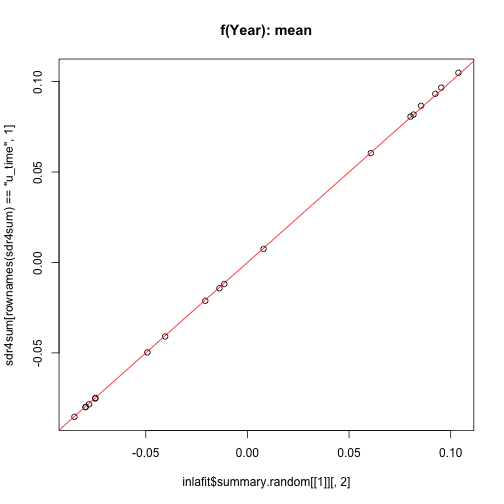

```r
sdr4sum <- summary(sdr4, "all")

plot(inlafit$summary.random[[1]][ , 2], sdr4sum[rownames(sdr4sum) == "u_time", 1],
     main = "f(Year): mean")
abline(0, 1, col = "red")
```

```r
plot(inlafit$summary.random[[1]][ , 3], sdr4sum[rownames(sdr4sum) == "u_time", 2],
     main = "f(Year): sd")
abline(0, 1, col = "red")


plot(inlafit$summary.random[[2]][ , 2], sdr4sum[rownames(sdr4sum) == "u_space", 1],
     main = "f(area): mean")
```

```
## Error in xy.coords(x, y, xlabel, ylabel, log): 'x' and 'y' lengths differ
```

```r
abline(0, 1, col = "red")

plot(inlafit$summary.random[[2]][ , 3], sdr4sum[rownames(sdr4sum) == "u_space", 2],
     main = "f(area): sd")
```

```
## Error in xy.coords(x, y, xlabel, ylabel, log): 'x' and 'y' lengths differ
```

[figure not shown]

```r
abline(0, 1, col = "red")
```

#### INLA with custom Cmatrix

```r
inlafitC <- inla(Observed ~
                   f(ID.Year, model = "generic0", Cmatrix = R_time,
                     hyper = prec.prior, diagonal = diagval, constr = TRUE) +
                   f(as.integer(IDf), model = "generic0", Cmatrix = R_space,
                     hyper = prec.prior, diagonal = diagval, constr = TRUE),
                 data = data, E = Expected, family = "poisson",
                 control.inla = list(strategy = "gaussian", int.strategy = "eb"),
                 control.compute = list(config = TRUE))
```

These match:

```r
summary(inlafit)
```

```
##
## Call:
##    c("inla.core(formula = formula, family = family, contrasts = contrasts, ", " data = data, quantiles = quantiles, E = E, offset = offset, ", " scale = scale, weights = weights, Ntrials = Ntrials, strata = strata, ",
##    " lp.scale = lp.scale, link.covariates = link.covariates, verbose = verbose, ", " lincomb = lincomb, selection = selection, control.compute = control.compute, ", " control.predictor = control.predictor,
##    control.family = control.family, ", " control.inla = control.inla, control.fixed = control.fixed, ", " control.mode = control.mode, control.expert = control.expert, ", " control.hazard = control.hazard,
##    control.lincomb = control.lincomb, ", " control.update = control.update, control.lp.scale = control.lp.scale, ", " control.pardiso = control.pardiso, only.hyperparam = only.hyperparam, ", " inla.call = inla.call,
##    inla.arg = inla.arg, num.threads = num.threads, ", " blas.num.threads = blas.num.threads, keep = keep, working.directory = working.directory, ", " silent = silent, inla.mode = inla.mode, safe = FALSE, debug = debug,
##    ", " .parent.frame = .parent.frame)")
## Time used:
##     Pre = 3.1, Running = 0.271, Post = 0.0146, Total = 3.38
## Fixed effects:
##               mean    sd 0.025quant 0.5quant 0.975quant mode kld
## (Intercept) -0.046 0.036     -0.118   -0.046      0.025   NA   0
##
## Random effects:
##   Name     Model
##     Year RW1 model
##    as.integer(IDf) Besags ICAR model
##
## Model hyperparameters:
##                                 mean     sd 0.025quant 0.5quant 0.975quant mode
## Precision for Year            500.80 554.54      56.97   335.62    1958.54   NA
## Precision for as.integer(IDf)  59.22  74.05       6.94    37.17     248.24   NA
##
## Marginal log-Likelihood:  -824.58
##  is computed
## Posterior summaries for the linear predictor and the fitted values are computed
## (Posterior marginals needs also 'control.compute=list(return.marginals.predictor=TRUE)')
```

```r
summary(inlafitC)
```

```
##
## Call:
##    c("inla.core(formula = formula, family = family, contrasts = contrasts, ", " data = data, quantiles = quantiles, E = E, offset = offset, ", " scale = scale, weights = weights, Ntrials = Ntrials, strata = strata, ",
##    " lp.scale = lp.scale, link.covariates = link.covariates, verbose = verbose, ", " lincomb = lincomb, selection = selection, control.compute = control.compute, ", " control.predictor = control.predictor,
##    control.family = control.family, ", " control.inla = control.inla, control.fixed = control.fixed, ", " control.mode = control.mode, control.expert = control.expert, ", " control.hazard = control.hazard,
##    control.lincomb = control.lincomb, ", " control.update = control.update, control.lp.scale = control.lp.scale, ", " control.pardiso = control.pardiso, only.hyperparam = only.hyperparam, ", " inla.call = inla.call,
##    inla.arg = inla.arg, num.threads = num.threads, ", " blas.num.threads = blas.num.threads, keep = keep, working.directory = working.directory, ", " silent = silent, inla.mode = inla.mode, safe = FALSE, debug = debug,
##    ", " .parent.frame = .parent.frame)")
## Time used:
##     Pre = 3.2, Running = 0.247, Post = 0.0175, Total = 3.47
## Fixed effects:
##               mean    sd 0.025quant 0.5quant 0.975quant mode kld
## (Intercept) -0.046 0.036     -0.118   -0.046      0.025   NA   0
##
## Random effects:
##   Name     Model
##     ID.Year Generic0 model
##    as.integer(IDf) Generic0 model
##
## Model hyperparameters:
##                                 mean     sd 0.025quant 0.5quant 0.975quant mode
## Precision for ID.Year         500.80 554.54      56.97   335.62    1958.54   NA
## Precision for as.integer(IDf)  59.22  74.05       6.94    37.17     248.24   NA
##
## Marginal log-Likelihood:  -824.58
##  is computed
## Posterior summaries for the linear predictor and the fitted values are computed
## (Posterior marginals needs also 'control.compute=list(return.marginals.predictor=TRUE)')
```

### Model 4b: Explicity sum-to-zero constraint

```r
mod <- '
#include <TMB.hpp>

template<class Type>
Type objective_function<Type>::operator() ()
{

  using namespace density;

  DATA_VECTOR(y);
  DATA_VECTOR(E);

  DATA_MATRIX(L_time);
  DATA_SPARSE_MATRIX(Z_time);
  DATA_SPARSE_MATRIX(LRL_time);

  DATA_MATRIX(L_space);
  DATA_SPARSE_MATRIX(Z_space);
  DATA_SPARSE_MATRIX(LRL_space);

  Type val(0);

  PARAMETER(beta0);
  // beta0 ~ 1

  PARAMETER(log_prec_time);
  val -= dlgamma(log_prec_time, Type(0.001), Type(1.0 / 0.001), true);
  Type sigma_time(exp(-0.5 * log_prec_time));

  PARAMETER_VECTOR(u_raw_time);
  vector<Type> u_time(L_time * u_raw_time * sigma_time);

  val += GMRF(LRL_time)(u_raw_time);

  PARAMETER(log_prec_space);
  val -= dlgamma(log_prec_space, Type(0.001), Type(1.0 / 0.001), true);
  Type sigma_space(exp(-0.5 * log_prec_space));

  PARAMETER_VECTOR(u_raw_space);
  vector<Type> u_space(L_space * u_raw_space * sigma_space);

  val += GMRF(LRL_space)(u_raw_space);

  vector<Type> mu(beta0 +
                  Z_time * u_time +
                  Z_space * u_space +
                  log(E));
  val -= dpois(y, exp(mu), true).sum();

  ADREPORT(u_time);
  ADREPORT(u_space);

  return val;
  using namespace density;
}
'

dll <- tmb_compile_and_load(mod)

Aconstr <- matrix(1, ncol = ncol(R_time))
qrc <- qr(t(Aconstr))
L_time <- qr.Q(qrc, complete=TRUE)[ , (nrow(Aconstr)+1):ncol(Aconstr)]

Aconstr <- matrix(1, ncol = ncol(R_space))
qrc <- qr(t(Aconstr))
L_space <- qr.Q(qrc, complete=TRUE)[ , (nrow(Aconstr)+1):ncol(Aconstr)]

tmbdata <- list(y = data$Observed,
                E = data$Expected,
                L_time = L_time,
                Z_time = Matrix::sparse.model.matrix(~0 + Yearf, data),
                LRL_time = as(t(L_time) %*% R_time %*% L_time, "dgCMatrix"),
                L_space = L_space,
                Z_space = Matrix::sparse.model.matrix(~0 + IDf, data),
                LRL_space = as(t(L_space) %*% R_space %*% L_space, "dgCMatrix"))

tmbpar <- list(beta0 = 0,
               log_prec_time = 0,
               u_raw_time = numeric(ncol(tmbdata$L_time)),
               log_prec_space = 0,
               u_raw_space = numeric(ncol(tmbdata$L_space)))

obj <- TMB::MakeADFun(data = tmbdata,
                      parameters = tmbpar,
                      random = c("beta0", "u_raw_time", "u_raw_space"),
                      DLL = dll)
```

```
## Constructing atomic D_lgamma
## Constructing atomic D_lgamma
```

```r
tmbfit <- nlminb(obj$par, obj$fn, obj$gr)
```

```
## Constructing atomic D_lgamma
## Optimizing tape... Done
## iter: 1  value: 798.5575 mgc: 21.99795 ustep: 1
## iter: 2  value: 798.0394 mgc: 26.33284 ustep: 1
## iter: 3  value: 798.0391 mgc: 0.4822713 ustep: 1
## iter: 4  value: 798.0391 mgc: 0.0003210132 ustep: 1
## iter: 5  mgc: 2.571279e-10
## iter: 1  mgc: 2.571279e-10
## Matching hessian patterns... Done
## outer mgc:  9.076859
## iter: 1  value: 800.262 mgc: 41.63097 ustep: 1
## iter: 2  value: 800.258 mgc: 2.485876 ustep: 1
## iter: 3  value: 800.258 mgc: 0.003972591 ustep: 1
## iter: 4  value: 800.258 mgc: 1.466055e-08 ustep: 1
## mgc: 2.124967e-13
## iter: 1  value: 810.1012 mgc: 72.8217 ustep: 1
## iter: 2  value: 810.0654 mgc: 7.163703 ustep: 1
## iter: 3  value: 810.0654 mgc: 0.03395478 ustep: 1
## iter: 4  value: 810.0654 mgc: 9.275332e-07 ustep: 1
## iter: 5  mgc: 1.403322e-13
## iter: 1  mgc: 1.403322e-13
## outer mgc:  4.498217
## iter: 1  value: 819.1639 mgc: 30.00507 ustep: 1
## iter: 2  value: 819.1616 mgc: 1.834127 ustep: 1
## iter: 3  value: 819.1616 mgc: 0.002039729 ustep: 1
## iter: 4  mgc: 2.700823e-09
## iter: 1  mgc: 2.700823e-09
## outer mgc:  1.017717
## iter: 1  value: 817.4997 mgc: 7.955022 ustep: 1
## iter: 2  value: 817.4997 mgc: 0.1791618 ustep: 1
## iter: 3  value: 817.4997 mgc: 1.94016e-05 ustep: 1
## iter: 4  mgc: 2.772158e-13
## iter: 1  mgc: 2.772158e-13
## outer mgc:  0.1286695
## iter: 1  value: 817.2866 mgc: 1.048298 ustep: 1
## iter: 2  value: 817.2866 mgc: 0.004285551 ustep: 1
## iter: 3  value: 817.2866 mgc: 1.130804e-08 ustep: 1
## mgc: 5.48693e-15
## iter: 1  mgc: 5.48693e-15
## outer mgc:  0.008569371
## iter: 1  value: 817.2779 mgc: 0.02410415 ustep: 1
## iter: 2  value: 817.2779 mgc: 1.930974e-05 ustep: 1
## iter: 3  mgc: 1.62711e-13
## iter: 1  mgc: 1.62711e-13
## outer mgc:  0.001461876
## iter: 1  value: 817.2799 mgc: 0.0174535 ustep: 1
## iter: 2  value: 817.2799 mgc: 3.562761e-07 ustep: 1
## mgc: 4.842134e-14
## iter: 1  mgc: 4.842134e-14
## outer mgc:  0.000468085
## iter: 1  value: 817.2811 mgc: 0.009436144 ustep: 1
## iter: 2  value: 817.2811 mgc: 8.548541e-08 ustep: 1
## mgc: 1.377102e-13
## iter: 1  mgc: 1.377102e-13
## outer mgc:  1.237475e-05
## iter: 1  value: 817.2811 mgc: 0.0001491972 ustep: 1
## iter: 2  mgc: 4.928061e-11
## iter: 1  mgc: 4.928061e-11
## outer mgc:  6.139063e-07
## iter: 1  mgc: 4.928061e-11
```

```r
sdr4b <- TMB::sdreport(obj)
```

```
## iter: 1  mgc: 4.928061e-11
## outer mgc:  6.139063e-07
## iter: 1  value: 817.2828 mgc: 0.007486521 ustep: 1
## iter: 2  value: 817.2828 mgc: 3.666077e-07 ustep: 1
## iter: 3  mgc: 1.125914e-13
## outer mgc:  0.001138868
## iter: 1  value: 817.2794 mgc: 0.007491823 ustep: 1
## iter: 2  value: 817.2794 mgc: 3.672827e-07 ustep: 1
## iter: 3  mgc: 1.98324e-13
## outer mgc:  0.001140044
## iter: 1  value: 817.284 mgc: 0.0234453 ustep: 1
## iter: 2  value: 817.284 mgc: 5.484283e-07 ustep: 1
## mgc: 8.678388e-14
## outer mgc:  0.001215115
## iter: 1  value: 817.2782 mgc: 0.02345946 ustep: 1
## iter: 2  value: 817.2782 mgc: 5.4943e-07 ustep: 1
## mgc: 1.098288e-13
## outer mgc:  0.001215559
## outer mgc:  0.1727976
```

```r
summary(sdr4b, "all")
```

```
##                    Estimate Std. Error
## log_prec_time   5.822729548 0.93680967
## log_prec_space  3.457439129 0.90709267
## beta0          -0.046644559 0.03791256
## u_raw_time     -0.334372321 1.08902386
## u_raw_time     -0.857805175 1.01451716
## u_raw_time     -1.384457744 0.98512123
## u_raw_time     -1.416341022 1.01121223
## u_raw_time     -1.415143350 1.02871232
## u_raw_time     -1.516860877 1.02158704
## u_raw_time     -1.325856123 1.02578862
## u_raw_time     -1.328882041 1.02104164
## u_raw_time     -0.696509402 1.02171736
## u_raw_time     -0.161414991 1.02578080
## u_raw_time      0.193453668 1.06013743
## u_raw_time      1.162676120 1.03964265
## u_raw_time      1.549263863 1.07187015
## u_raw_time      1.521775558 1.16543231
## u_raw_time      1.746051661 1.20331021
## u_raw_time      1.954769970 1.23023795
## u_raw_time      1.617165540 1.38996419
## u_raw_time      1.799825745 1.48957066
## u_raw_space    -0.131964194 0.55383894
## u_raw_space    -0.106128123 0.45926960
## u_raw_space    -0.164341403 0.56927074
## u_raw_space     0.027605551 0.60732287
## u_raw_space    -0.157950348 0.49748500
## u_raw_space    -0.383200014 0.48854847
## u_raw_space    -0.757333719 0.53534114
## u_raw_space    -0.689390261 0.55533996
## u_raw_space    -0.056795930 0.47960162
## u_raw_space    -0.084298639 0.52565804
## u_raw_space    -0.697549540 0.79491179
## u_raw_space    -0.853806886 0.52610019
## u_raw_space    -0.257735909 0.40464243
## u_raw_space     0.458399682 0.56761940
## u_raw_space    -0.741697122 0.56301058
## u_raw_space     0.434508184 0.53742877
## u_raw_space    -0.008262779 0.46988521
## u_raw_space    -0.647602524 0.44465076
```

[output cut: 49 more lines]

```
## u_space         0.015909817 0.08219893
## u_space        -0.097580376 0.08627444
## u_space         0.011750866 0.07502375
## u_space         0.067296614 0.07916307
## u_space        -0.015063372 0.08539172
## u_space         0.083349979 0.07565134
## u_space         0.006724648 0.09935686
## u_space         0.027813373 0.06796984
## u_space         0.086121832 0.06919868
## u_space        -0.032976308 0.07462168
## u_space         0.037482843 0.08816465
## u_space         0.002570430 0.10499146
## u_space         0.044087849 0.07086826
## u_space         0.008066735 0.11278183
## u_space         0.099493030 0.08331491
```

Hyper parameters

```r
cbind(inlafit$misc$theta.mode,
  sqrt(diag(inlafit$misc$cov.intern)))
```

```
##          [,1]      [,2]
## [1,] 5.821663 0.9330135
## [2,] 3.485399 0.8865806
```

```r
summary(sdr4, "fixed")
```

```
##               Estimate Std. Error
## log_prec_time 5.819927  0.9342717
```

```r
summary(sdr4b, "fixed")
```

```
##                Estimate Std. Error
## log_prec_time  5.822730  0.9368097
## log_prec_space 3.457439  0.9070927
```

Intercept

```r
inlafit$summary.fixed[ , 1:2]
```

```
##                    mean         sd
## (Intercept) -0.04632663 0.03634364
```

```r
summary(sdr4, "random")[1, ]
```

```
##    Estimate  Std. Error
## -0.01024137  0.02970886
```

```r
summary(sdr4b, "random")[1, ]
```

```
##    Estimate  Std. Error
## -0.04664456  0.03791256
```

Random effects

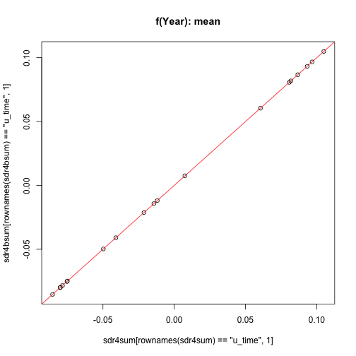

```r
sdr4bsum <- summary(sdr4, "all")

plot(sdr4sum[rownames(sdr4sum) == "u_time", 1],
     sdr4bsum[rownames(sdr4bsum) == "u_time", 1],
     main = "f(Year): mean")
abline(0, 1, col = "red")
```

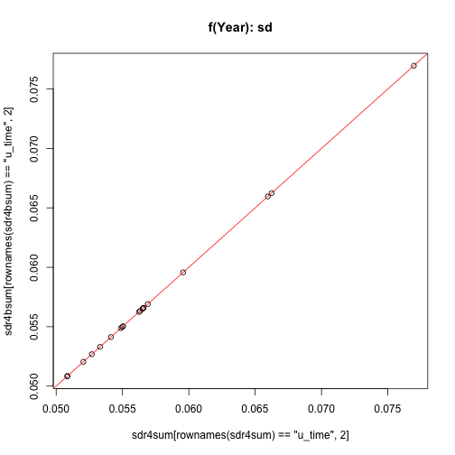

```r
plot(sdr4sum[rownames(sdr4sum) == "u_time", 2],
     sdr4bsum[rownames(sdr4bsum) == "u_time", 2],
     main = "f(Year): sd")
abline(0, 1, col = "red")
```

```r
plot(sdr4sum[rownames(sdr4sum) == "u_space", 1],
     sdr4bsum[rownames(sdr4bsum) == "u_space", 1],
     main = "f(area): mean")
```

```
## Error in plot.window(...): need finite 'xlim' values
```

```r
abline(0, 1, col = "red")

plot(sdr4sum[rownames(sdr4sum) == "u_space", 2],
     sdr4bsum[rownames(sdr4bsum) == "u_space", 2],
     main = "f(area): sd")
```

```
## Error in plot.window(...): need finite 'xlim' values
```

```r
abline(0, 1, col = "red")
```

## Model 5: ICAR space x IID time

INLA automatically applies a sum-to-zero constraint for the spatial field at each time. This is too many constraints for an intercept plus interaction only model because it imposes that the average is the intercept at each time, and hence there is no time trend in the model.

The correct specification for this model should probably be a single sum-to-zero constraint to account for the lost degree of freedom from the intercept term

```r
mod <- '
#include <TMB.hpp>

template<class Type>
Type objective_function<Type>::operator() ()
{

  using namespace density;

  DATA_VECTOR(y);
  DATA_VECTOR(E);

  DATA_SPARSE_MATRIX(Z_space_time);
  DATA_SPARSE_MATRIX(R_time);
  DATA_SPARSE_MATRIX(R_space);

  Type val(0);

  PARAMETER(beta0);
  // beta0 ~ 1

  PARAMETER(log_prec_space_time);
  val -= dlgamma(log_prec_space_time, Type(0.001), Type(1.0 / 0.001), true);
  Type sigma_space_time(exp(-0.5 * log_prec_space_time));

  PARAMETER_ARRAY(u_raw_space_time);
  vector<Type> u_space_time(u_raw_space_time * sigma_space_time);

  val += SEPARABLE(GMRF(R_time), GMRF(R_space))(u_raw_space_time);
  for (int i = 0; i < u_raw_space_time.cols(); i++) {
     val -= dnorm(u_raw_space_time.col(i).sum(), Type(0), Type(0.001) * u_raw_space_time.rows(), true);
  }

  vector<Type> mu(beta0 +
                  Z_space_time * u_space_time +
                  log(E));
  val -= dpois(y, exp(mu), true).sum();

  ADREPORT(u_space_time);

  return val;
}
'


dll <- tmb_compile_and_load(mod)


R_space <- diag(rowSums(adj.mat)) - adj.mat
R_space_scaled <- inla.scale.model(R_space, constr = list(A = matrix(1, ncol = ncol(R_space)), e = 0))
R_space_adj <- R_space + Matrix::Diagonal(ncol(R_space), 1e-6)
R_space_scaled_adj <- R_space_scaled + Matrix::Diagonal(ncol(R_space_scaled), 1e-6)

R_time <- Matrix::sparseMatrix(1:19, 1:19, x = rep(1L, 19))

tmbdata <- list(y = data$Observed,
                E = data$Expected,
                Z_space_time = Matrix::sparse.model.matrix(~0 + IDf:Yearf, data),
                R_time = R_time,
                R_space = R_space_adj)

tmbpar <- list(beta0 = 0,
               log_prec_space_time = 0,
               u_raw_space_time = array(0, c(nrow(tmbdata$R_space), nrow(tmbdata$R_time))))

obj <- TMB::MakeADFun(data = tmbdata,
                      parameters = tmbpar,
                      random = c("beta0", "u_raw_space_time"),
                      DLL = dll)
```

```
## Constructing atomic D_lgamma
## Constructing atomic D_lgamma
```

```r
tmbfit <- nlminb(obj$par, obj$fn, obj$gr)
```

```
## Constructing atomic D_lgamma
## Optimizing tape... Done
## iter: 1  value: 964.8885 mgc: 10.896 ustep: 1
## iter: 2  value: 963.3585 mgc: 38.99139 ustep: 1
## iter: 3  value: 963.3539 mgc: 1.153985 ustep: 1
## iter: 4  value: 963.3539 mgc: 0.003459808 ustep: 1
## iter: 5  value: 963.3539 mgc: 3.167988e-07 ustep: 1
## iter: 6  mgc: 5.382361e-13
## iter: 1  mgc: 5.382361e-13
## Matching hessian patterns... Done
## outer mgc:  32.31067
## iter: 1  value: 998.675 mgc: 44.04501 ustep: 1
## iter: 2  value: 998.6728 mgc: 1.632966 ustep: 1
## iter: 3  value: 998.6728 mgc: 0.001903568 ustep: 1
## iter: 4  mgc: 6.258526e-09
## iter: 1  mgc: 6.258526e-09
## outer mgc:  13.02122
## iter: 1  value: 1015.11 mgc: 18.05683 ustep: 1
## iter: 2  value: 1015.11 mgc: 0.2913617 ustep: 1
## iter: 3  value: 1015.11 mgc: 4.661652e-05 ustep: 1
## iter: 4  mgc: 2.052414e-12
## iter: 1  mgc: 2.052414e-12
## outer mgc:  6.081217
## iter: 1  value: 1025.227 mgc: 10.36666 ustep: 1
## iter: 2  value: 1025.227 mgc: 0.104909 ustep: 1
## iter: 3  value: 1025.227 mgc: 4.9472e-06 ustep: 1
## iter: 4  mgc: 4.235501e-13
## iter: 1  mgc: 4.235501e-13
## outer mgc:  2.703557
## iter: 1  value: 1030.975 mgc: 5.550054 ustep: 1
## iter: 2  value: 1030.975 mgc: 0.04026854 ustep: 1
## iter: 3  value: 1030.975 mgc: 7.44526e-07 ustep: 1
## mgc: 3.58269e-13
## iter: 1  mgc: 3.58269e-13
## outer mgc:  1.22287
## iter: 1  value: 1034.461 mgc: 3.187373 ustep: 1
## iter: 2  value: 1034.461 mgc: 0.01906048 ustep: 1
## iter: 3  value: 1034.461 mgc: 1.617603e-07 ustep: 1
## mgc: 3.496925e-13
## iter: 1  mgc: 3.496925e-13
```

[output cut: 18 more lines]

```
## iter: 2  value: 1038.715 mgc: 0.0001561552 ustep: 1
## iter: 3  mgc: 1.044154e-11
## iter: 1  mgc: 1.044154e-11
## outer mgc:  0.004029734
## iter: 1  value: 1038.76 mgc: 0.03491532 ustep: 1
## iter: 2  value: 1038.76 mgc: 5.846023e-06 ustep: 1
## iter: 3  mgc: 2.304268e-13
## iter: 1  mgc: 2.304268e-13
## outer mgc:  0.0002377232
## iter: 1  value: 1038.763 mgc: 0.002172366 ustep: 1
## iter: 2  value: 1038.763 mgc: 2.289432e-08 ustep: 1
## mgc: 2.394751e-13
## iter: 1  mgc: 2.394751e-13
## outer mgc:  2.488307e-06
## iter: 1  mgc: 2.394751e-13
```

```r
sdr5 <- TMB::sdreport(obj)
```

```
## iter: 1  mgc: 2.394751e-13
## outer mgc:  2.488307e-06
## iter: 1  value: 1038.767 mgc: 0.003218664 ustep: 1
## iter: 2  value: 1038.767 mgc: 5.026887e-08 ustep: 1
## mgc: 5.009326e-13
## outer mgc:  0.0003457662
## iter: 1  value: 1038.759 mgc: 0.003220435 ustep: 1
## iter: 2  value: 1038.759 mgc: 5.037964e-08 ustep: 1
## mgc: 5.093703e-13
## outer mgc:  0.0003513833
## outer mgc:  0.1440174
```

```r
summary(sdr5, "all")
```

```
##                          Estimate Std. Error
## log_prec_space_time  3.875642e+00 1.69376067
## beta0               -5.221556e-03 0.03087570
## u_raw_space_time     1.308886e-01 0.55247732
## u_raw_space_time    -4.285736e-02 0.59498647
## u_raw_space_time    -8.313194e-02 0.53112358
## u_raw_space_time     2.183067e-02 0.64685309
## u_raw_space_time    -2.420405e-02 0.79633707
## u_raw_space_time    -1.755869e-02 0.52215069
## u_raw_space_time    -2.887748e-01 0.73554616
## u_raw_space_time    -1.032285e-01 0.71275944
## u_raw_space_time    -1.193131e-01 0.70252654
## u_raw_space_time     1.006872e-02 0.49533710
## u_raw_space_time     3.315063e-02 0.56396085
## u_raw_space_time    -1.004277e-01 0.92801559
## u_raw_space_time    -9.336400e-02 0.71626007
## u_raw_space_time    -5.157709e-02 0.43276821
## u_raw_space_time     9.007125e-02 0.68328891
## u_raw_space_time    -1.865883e-01 0.72777583
## u_raw_space_time     1.698843e-01 0.70649390
## u_raw_space_time     7.492797e-02 0.52536011
## u_raw_space_time    -1.196505e-01 0.55607880
## u_raw_space_time    -9.305697e-03 0.47152689
## u_raw_space_time     1.313731e-01 0.54522772
## u_raw_space_time    -6.911261e-02 0.57214033
## u_raw_space_time     1.129330e-01 0.51394219
## u_raw_space_time     1.858706e-01 0.72184983
## u_raw_space_time     9.579130e-02 0.47127808
## u_raw_space_time     1.254013e-01 0.47368989
## u_raw_space_time    -1.312330e-01 0.51615232
## u_raw_space_time    -2.017725e-02 0.50658819
## u_raw_space_time     8.297281e-02 0.70014488
## u_raw_space_time     7.243029e-02 0.42369564
## u_raw_space_time    -8.054346e-04 0.69395080
## u_raw_space_time     1.237210e-01 0.49052084
## u_raw_space_time     1.144052e-01 0.54995256
## u_raw_space_time    -2.483533e-02 0.59437092
## u_raw_space_time    -7.904423e-02 0.53060391
## u_raw_space_time     3.176839e-02 0.64697515
## u_raw_space_time    -2.398830e-02 0.79611944
```

[output cut: 447 more lines]

```
## u_raw_space_time    -2.480508e-01 0.81642867
## u_raw_space_time    -3.878061e-02 0.52164841
## u_raw_space_time     1.814277e-01 0.70429589
## u_raw_space_time    -6.188561e-02 0.70599562
## u_raw_space_time     1.499198e-01 0.70308516
## u_raw_space_time    -1.589970e-02 0.49496455
## u_raw_space_time    -6.055889e-02 0.56406832
## u_raw_space_time     7.362700e-02 0.92284588
## u_raw_space_time    -9.589638e-02 0.71207357
## u_raw_space_time     4.439027e-02 0.43190833
## u_raw_space_time     9.029376e-02 0.68074666
## u_raw_space_time     6.905991e-02 0.71016709
## u_raw_space_time    -1.186071e-01 0.69875735
## u_raw_space_time    -2.204057e-02 0.52107365
##  [ reached getOption("max.print") -- omitted 718 rows ]
```

```r
inlafit <- inla(Observed ~
                  f(as.integer(IDf), model = "besag", hyper = prec.prior, scale.model = FALSE,
                    graph = adj.mat, diagonal = 1e-6,
                    group = ID.Year, control.group = list(model = "iid")),
                data = data, E = Expected, family = "poisson",
                control.inla = list(strategy = "gaussian", int.strategy = "eb"),
                control.compute = list(config = TRUE))

summary(inlafit)
```

```
##
## Call:
##    c("inla.core(formula = formula, family = family, contrasts = contrasts, ", " data = data, quantiles = quantiles, E = E, offset = offset, ", " scale = scale, weights = weights, Ntrials = Ntrials, strata = strata, ",
##    " lp.scale = lp.scale, link.covariates = link.covariates, verbose = verbose, ", " lincomb = lincomb, selection = selection, control.compute = control.compute, ", " control.predictor = control.predictor,
##    control.family = control.family, ", " control.inla = control.inla, control.fixed = control.fixed, ", " control.mode = control.mode, control.expert = control.expert, ", " control.hazard = control.hazard,
##    control.lincomb = control.lincomb, ", " control.update = control.update, control.lp.scale = control.lp.scale, ", " control.pardiso = control.pardiso, only.hyperparam = only.hyperparam, ", " inla.call = inla.call,
##    inla.arg = inla.arg, num.threads = num.threads, ", " blas.num.threads = blas.num.threads, keep = keep, working.directory = working.directory, ", " silent = silent, inla.mode = inla.mode, safe = FALSE, debug = debug,
##    ", " .parent.frame = .parent.frame)")
## Time used:
##     Pre = 2.62, Running = 0.321, Post = 0.0191, Total = 2.96
## Fixed effects:
##               mean   sd 0.025quant 0.5quant 0.975quant mode kld
## (Intercept) -0.005 0.03     -0.063   -0.005      0.053   NA   0
##
## Random effects:
##   Name     Model
##     as.integer(IDf) Besags ICAR model
##
## Model hyperparameters:
##                                 mean      sd 0.025quant 0.5quant 0.975quant mode
## Precision for as.integer(IDf) 359.96 1250.87      22.33   121.43    2294.40   NA
##
## Marginal log-Likelihood:  -1197.30
##  is computed
## Posterior summaries for the linear predictor and the fitted values are computed
## (Posterior marginals needs also 'control.compute=list(return.marginals.predictor=TRUE)')
```

Hyper parameter comparison

```r
cbind("mean" = inlafit$misc$theta.mode,
      "se" = sqrt(diag(inlafit$misc$cov.intern)))
```

```
##          mean       se
## [1,] 3.895976 1.933834
```

```r
summary(sdr5, "fixed")
```

```
##                     Estimate Std. Error
## log_prec_space_time 3.875642   1.693761
```

Fixed effects (Intercept)

```r
inlafit$summary.fixed[ , 1:2]
```

```
##                     mean         sd
## (Intercept) -0.005125148 0.02977067
```

```r
summary(sdr5, "random")[1, , drop = FALSE]
```

```
##           Estimate Std. Error
## beta0 -0.005221556  0.0308757
```

Random effects mean and standard deviation

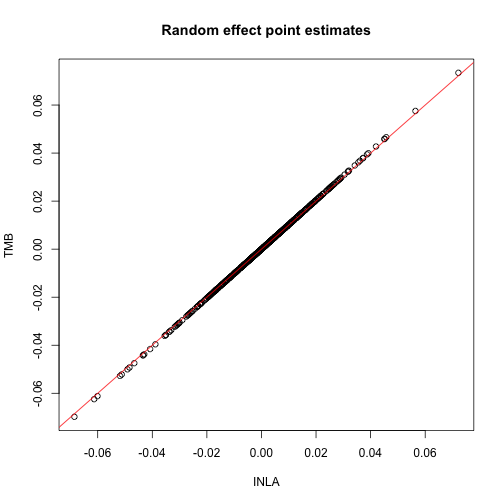

```r
plot(inlafit$summary.random[[1]][,2], summary(sdr5, "report")[,1],
     xlab = "INLA", ylab = "TMB", main = "Random effect point estimates")
abline(0, 1, col = "red")
```

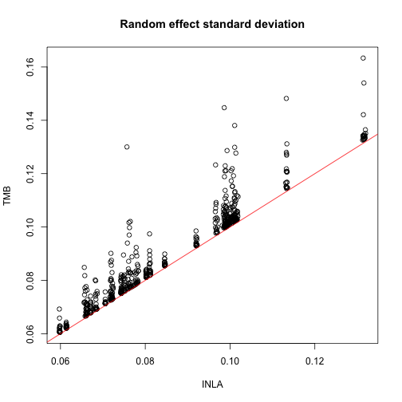

```r
plot(inlafit$summary.random[[1]][,3], summary(sdr5, "report")[,2],
     xlab = "INLA", ylab = "TMB", main = "Random effect standard deviation")
abline(0, 1, col = "red")
```

#### INLA with custom Cmatrix

```r
R_space_time <- kronecker(R_time, R_space)

Aconstr <- t(model.matrix(~0+factor(ID.Year), data[order(data$id.area.year), ]))

inlafitC <- inla(Observed ~
                   f(id.area.year, model = "generic0", Cmatrix = R_space_time,
                     hyper = prec.prior, diagonal = 1e-6,
                     extraconstr = list(A = Aconstr, e = numeric(nrow(Aconstr)))),
                 data = data, E = Expected, family = "poisson",
                 control.inla = list(strategy = "gaussian", int.strategy = "eb"),
                 control.compute = list(config = TRUE))
```

These match:

```r
summary(inlafit)
```

```
##
## Call:
##    c("inla.core(formula = formula, family = family, contrasts = contrasts, ", " data = data, quantiles = quantiles, E = E, offset = offset, ", " scale = scale, weights = weights, Ntrials = Ntrials, strata = strata, ",
##    " lp.scale = lp.scale, link.covariates = link.covariates, verbose = verbose, ", " lincomb = lincomb, selection = selection, control.compute = control.compute, ", " control.predictor = control.predictor,
##    control.family = control.family, ", " control.inla = control.inla, control.fixed = control.fixed, ", " control.mode = control.mode, control.expert = control.expert, ", " control.hazard = control.hazard,
##    control.lincomb = control.lincomb, ", " control.update = control.update, control.lp.scale = control.lp.scale, ", " control.pardiso = control.pardiso, only.hyperparam = only.hyperparam, ", " inla.call = inla.call,
##    inla.arg = inla.arg, num.threads = num.threads, ", " blas.num.threads = blas.num.threads, keep = keep, working.directory = working.directory, ", " silent = silent, inla.mode = inla.mode, safe = FALSE, debug = debug,
##    ", " .parent.frame = .parent.frame)")
## Time used:
##     Pre = 2.62, Running = 0.321, Post = 0.0191, Total = 2.96
## Fixed effects:
##               mean   sd 0.025quant 0.5quant 0.975quant mode kld
## (Intercept) -0.005 0.03     -0.063   -0.005      0.053   NA   0
##
## Random effects:
##   Name     Model
##     as.integer(IDf) Besags ICAR model
##
## Model hyperparameters:
##                                 mean      sd 0.025quant 0.5quant 0.975quant mode
## Precision for as.integer(IDf) 359.96 1250.87      22.33   121.43    2294.40   NA
##
## Marginal log-Likelihood:  -1197.30
##  is computed
## Posterior summaries for the linear predictor and the fitted values are computed
## (Posterior marginals needs also 'control.compute=list(return.marginals.predictor=TRUE)')
```

```r
summary(inlafitC)
```

```
##
## Call:
##    c("inla.core(formula = formula, family = family, contrasts = contrasts, ", " data = data, quantiles = quantiles, E = E, offset = offset, ", " scale = scale, weights = weights, Ntrials = Ntrials, strata = strata, ",
##    " lp.scale = lp.scale, link.covariates = link.covariates, verbose = verbose, ", " lincomb = lincomb, selection = selection, control.compute = control.compute, ", " control.predictor = control.predictor,
##    control.family = control.family, ", " control.inla = control.inla, control.fixed = control.fixed, ", " control.mode = control.mode, control.expert = control.expert, ", " control.hazard = control.hazard,
##    control.lincomb = control.lincomb, ", " control.update = control.update, control.lp.scale = control.lp.scale, ", " control.pardiso = control.pardiso, only.hyperparam = only.hyperparam, ", " inla.call = inla.call,
##    inla.arg = inla.arg, num.threads = num.threads, ", " blas.num.threads = blas.num.threads, keep = keep, working.directory = working.directory, ", " silent = silent, inla.mode = inla.mode, safe = FALSE, debug = debug,
##    ", " .parent.frame = .parent.frame)")
## Time used:
##     Pre = 2.77, Running = 0.317, Post = 0.0237, Total = 3.11
## Fixed effects:
##               mean   sd 0.025quant 0.5quant 0.975quant mode kld
## (Intercept) -0.005 0.03     -0.063   -0.005      0.053   NA   0
##
## Random effects:
##   Name     Model
##     id.area.year Generic0 model
##
## Model hyperparameters:
##                              mean      sd 0.025quant 0.5quant 0.975quant mode
## Precision for id.area.year 359.96 1250.87      22.33   121.43    2294.40   NA
##
## Marginal log-Likelihood:  -1197.30
##  is computed
## Posterior summaries for the linear predictor and the fitted values are computed
## (Posterior marginals needs also 'control.compute=list(return.marginals.predictor=TRUE)')
```

### Model 5b: Express GMRF as kronecker product

```r
mod <- '
#include <TMB.hpp>

template<class Type>
Type objective_function<Type>::operator() ()
{

  using namespace density;

  DATA_VECTOR(y);
  DATA_VECTOR(E);

  DATA_MATRIX(Aconstr)
  DATA_SPARSE_MATRIX(Z_space_time);
  DATA_SPARSE_MATRIX(R_space_time);

  Type val(0);

  PARAMETER(beta0);
  // beta0 ~ 1

  PARAMETER(log_prec_space_time);
  val -= dlgamma(log_prec_space_time, Type(0.001), Type(1.0 / 0.001), true);
  Type sigma_space_time(exp(-0.5 * log_prec_space_time));

  PARAMETER_ARRAY(u_raw_space_time);
  vector<Type> u_raw_space_time_v(u_raw_space_time);
  vector<Type> u_space_time(u_raw_space_time_v * sigma_space_time);

  val += GMRF(R_space_time)(u_raw_space_time);
  val -= dnorm(Aconstr * u_raw_space_time_v, Type(0), Type(0.001) * u_raw_space_time.rows(), true).sum();  // soft sum-to-zero constraint

  vector<Type> mu(beta0 +
                  Z_space_time * u_space_time +
                  log(E));
  val -= dpois(y, exp(mu), true).sum();

  ADREPORT(u_space_time);

  return val;
}
'

dll <- tmb_compile_and_load(mod)

R_space_time_adj <- R_space_time + Matrix::Diagonal(ncol(R_space_time), diagval)


tmbdata <- list(y = data$Observed,
                E = data$Expected,
                Aconstr = Aconstr,
                Z_space_time = Matrix::sparse.model.matrix(~0 + IDf:Yearf, data),
                R_space_time = R_space_time_adj)

tmbpar <- list(beta0 = 0,
               log_prec_space_time = 0,
               u_raw_space_time = array(0, c(nrow(tmbdata$R_space), nrow(tmbdata$R_time))))

obj <- TMB::MakeADFun(data = tmbdata,
                      parameters = tmbpar,
                      random = c("beta0", "u_raw_space_time"),
                      DLL = dll)
```

```
## Constructing atomic D_lgamma
## Constructing atomic D_lgamma
```

```r
tmbfit <- nlminb(obj$par, obj$fn, obj$gr)
```

```
## Constructing atomic D_lgamma
## Optimizing tape... Done
## iter: 1  value: 976.9358 mgc: 10.896 ustep: 1
## iter: 2  value: 975.4039 mgc: 39.03532 ustep: 1
## iter: 3  value: 975.3993 mgc: 1.15536 ustep: 1
## iter: 4  value: 975.3993 mgc: 0.003459076 ustep: 1
## iter: 5  value: 975.3993 mgc: 3.167393e-07 ustep: 1
## iter: 6  mgc: 1.904032e-14
## iter: 1  mgc: 1.904032e-14
## Matching hessian patterns... Done
## outer mgc:  32.28756
## iter: 1  value: 1010.796 mgc: 44.08625 ustep: 1
## iter: 2  value: 1010.794 mgc: 1.636173 ustep: 1
## iter: 3  value: 1010.794 mgc: 0.001912249 ustep: 1
## iter: 4  mgc: 6.332186e-09
## iter: 1  mgc: 6.332186e-09
## outer mgc:  13.00973
## iter: 1  value: 1027.254 mgc: 18.06808 ustep: 1
## iter: 2  value: 1027.254 mgc: 0.2917251 ustep: 1
## iter: 3  value: 1027.254 mgc: 4.678608e-05 ustep: 1
## iter: 4  mgc: 1.986633e-12
## iter: 1  mgc: 1.986633e-12
## outer mgc:  6.075695
## iter: 1  value: 1037.383 mgc: 10.37342 ustep: 1
## iter: 2  value: 1037.383 mgc: 0.1050032 ustep: 1
## iter: 3  value: 1037.383 mgc: 4.95604e-06 ustep: 1
## iter: 4  mgc: 1.187106e-13
## iter: 1  mgc: 1.187106e-13
## outer mgc:  2.700598
## iter: 1  value: 1043.137 mgc: 5.552721 ustep: 1
## iter: 2  value: 1043.137 mgc: 0.040271 ustep: 1
## iter: 3  value: 1043.137 mgc: 7.445354e-07 ustep: 1
## mgc: 2.597922e-14
## iter: 1  mgc: 2.597922e-14
## outer mgc:  1.221189
## iter: 1  value: 1046.626 mgc: 3.188249 ustep: 1
## iter: 2  value: 1046.626 mgc: 0.01904842 ustep: 1
## iter: 3  value: 1046.626 mgc: 1.615516e-07 ustep: 1
## mgc: 1.405542e-13
## iter: 1  mgc: 1.405542e-13
```

[output cut: 18 more lines]

```
## iter: 2  value: 1050.877 mgc: 0.0001541613 ustep: 1
## iter: 3  mgc: 1.023648e-11
## iter: 1  mgc: 1.023648e-11
## outer mgc:  0.003984532
## iter: 1  value: 1050.922 mgc: 0.03455395 ustep: 1
## iter: 2  value: 1050.922 mgc: 5.710624e-06 ustep: 1
## iter: 3  mgc: 1.49214e-13
## iter: 1  mgc: 1.49214e-13
## outer mgc:  0.0002332206
## iter: 1  value: 1050.924 mgc: 0.002132292 ustep: 1
## iter: 2  value: 1050.924 mgc: 2.199584e-08 ustep: 1
## mgc: 2.331468e-15
## iter: 1  mgc: 2.331468e-15
## outer mgc:  2.409922e-06
## iter: 1  mgc: 2.331468e-15
```

```r
sdr5b <- TMB::sdreport(obj)
```

```
## iter: 1  mgc: 2.331468e-15
## outer mgc:  2.409922e-06
## iter: 1  value: 1050.929 mgc: 0.003233438 ustep: 1
## iter: 2  value: 1050.929 mgc: 5.058934e-08 ustep: 1
## mgc: 2.220446e-14
## outer mgc:  0.0003473145
## iter: 1  value: 1050.92 mgc: 0.003235218 ustep: 1
## iter: 2  value: 1050.92 mgc: 5.070078e-08 ustep: 1
## mgc: 9.25926e-14
## outer mgc:  0.0003527791
## outer mgc:  0.1443106
```

```r
summary(sdr5b, "all")
```

```
##                          Estimate Std. Error
## log_prec_space_time  3.8715748006 1.69019544
## beta0               -0.0052445905 0.03088873
## u_raw_space_time     0.1311370709 0.55260594
## u_raw_space_time    -0.0428548132 0.59525451
## u_raw_space_time    -0.0831857252 0.53138813
## u_raw_space_time     0.0218988990 0.64708667
## u_raw_space_time    -0.0241687172 0.79648261
## u_raw_space_time    -0.0175082821 0.52247525
## u_raw_space_time    -0.2891936119 0.73562418
## u_raw_space_time    -0.1033044691 0.71290466
## u_raw_space_time    -0.1194218163 0.70268647
## u_raw_space_time     0.0101508183 0.49569318
## u_raw_space_time     0.0332521681 0.56425399
## u_raw_space_time    -0.1004831612 0.92810146
## u_raw_space_time    -0.0934290579 0.71640608
## u_raw_space_time    -0.0515910873 0.43316219
## u_raw_space_time     0.0902472504 0.68347840
## u_raw_space_time    -0.1868167318 0.72790119
## u_raw_space_time     0.1702189965 0.70665573
## u_raw_space_time     0.0750947798 0.52566009
## u_raw_space_time    -0.1197617340 0.55632175
## u_raw_space_time    -0.0092619062 0.47188749
## u_raw_space_time     0.1316353764 0.54548172
## u_raw_space_time    -0.0691559484 0.57239868
## u_raw_space_time     0.1131554717 0.51420071
## u_raw_space_time     0.1862311497 0.72200410
## u_raw_space_time     0.0960180560 0.47163079
## u_raw_space_time     0.1256582998 0.47398914
## u_raw_space_time    -0.1313770287 0.51642613
## u_raw_space_time    -0.0201448080 0.50692338
## u_raw_space_time     0.0831490324 0.70034264
## u_raw_space_time     0.0726144086 0.42409358
## u_raw_space_time    -0.0007664703 0.69417678
## u_raw_space_time     0.1239959026 0.49083013
## u_raw_space_time     0.1148468266 0.55010157
## u_raw_space_time    -0.0245675089 0.59463515
## u_raw_space_time    -0.0788541959 0.53084896
## u_raw_space_time     0.0321077427 0.64721553
## u_raw_space_time    -0.0237106524 0.79626092
```

[output cut: 447 more lines]

```
## u_raw_space_time    -0.2481502108 0.81647978
## u_raw_space_time    -0.0385062974 0.52196476
## u_raw_space_time     0.1820602779 0.70442601
## u_raw_space_time    -0.0616563057 0.70612936
## u_raw_space_time     0.1505086957 0.70328374
## u_raw_space_time    -0.0155962724 0.49531770
## u_raw_space_time    -0.0603281166 0.56433874
## u_raw_space_time     0.0740635699 0.92294606
## u_raw_space_time    -0.0957194307 0.71219330
## u_raw_space_time     0.0448019785 0.43233369
## u_raw_space_time     0.0907707868 0.68094611
## u_raw_space_time     0.0694828425 0.71032676
## u_raw_space_time    -0.1185399586 0.69888199
## u_raw_space_time    -0.0217530547 0.52136562
##  [ reached getOption("max.print") -- omitted 718 rows ]
```

Hyper parmaters

```r
summary(sdr5, "fixed")
```

```
##                     Estimate Std. Error
## log_prec_space_time 3.875642   1.693761
```

```r
summary(sdr5b, "fixed")
```

```
##                     Estimate Std. Error
## log_prec_space_time 3.871575   1.690195
```

Intercept

```r
summary(sdr5, "random")[1, ]
```

```
##     Estimate   Std. Error
## -0.005221556  0.030875695
```

```r
summary(sdr5b, "random")[1, ]
```

```
##    Estimate  Std. Error
## -0.00524459  0.03088873
```

Random effects

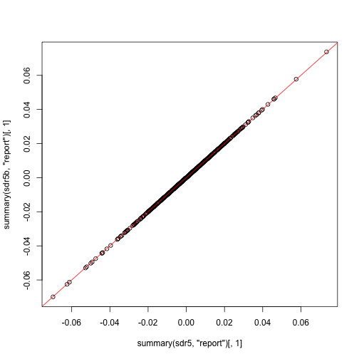

```r
plot(summary(sdr5, "report")[ , 1],
     summary(sdr5b, "report")[ , 1])
abline(0, 1, col = "red")
```

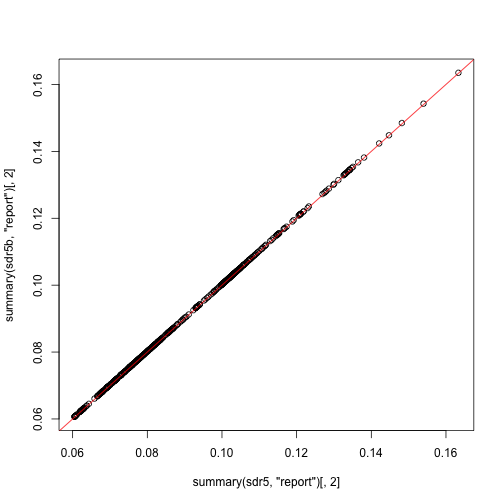

```r
plot(summary(sdr5, "report")[ , 2],
     summary(sdr5b, "report")[ , 2])
abline(0, 1, col = "red")
```

### Model 5c: explicit sum-to-zero constraint

```r
mod <- '
#include <TMB.hpp>

template<class Type>
Type objective_function<Type>::operator() ()
{

  using namespace density;

  DATA_VECTOR(y);
  DATA_VECTOR(E);

  DATA_MATRIX(L_space_time)
  DATA_SPARSE_MATRIX(Z_space_time);
  DATA_SPARSE_MATRIX(LRL_space_time);

  Type val(0);

  PARAMETER(beta0);
  // beta0 ~ 1

  PARAMETER(log_prec_space_time);
  val -= dlgamma(log_prec_space_time, Type(0.001), Type(1.0 / 0.001), true);
  Type sigma_space_time(exp(-0.5 * log_prec_space_time));

  PARAMETER_VECTOR(u_raw_space_time);
  vector<Type> u_space_time(L_space_time * u_raw_space_time * sigma_space_time);

  val += GMRF(LRL_space_time)(u_raw_space_time);

  vector<Type> mu(beta0 +
                  Z_space_time * u_space_time +
                  log(E));
  val -= dpois(y, exp(mu), true).sum();

  ADREPORT(u_space_time);

  return val;
}
'

dll <- tmb_compile_and_load(mod)

qrc <- qr(t(Aconstr))
L_space_time <- qr.Q(qrc, complete=TRUE)[ , (nrow(Aconstr)+1):ncol(Aconstr)]


R_space_time_adj <- R_space_time + Matrix::Diagonal(ncol(R_space_time), diagval)


tmbdata <- list(y = data$Observed,
                E = data$Expected,
                L_space_time = L_space_time,
                Z_space_time = Matrix::sparse.model.matrix(~0 + IDf:Yearf, data),
                LRL_space_time = as(t(L_space_time) %*% R_space_time %*% L_space_time, "dgCMatrix"))

tmbpar <- list(beta0 = 0,
               log_prec_space_time = 0,
               u_raw_space_time = numeric(ncol(tmbdata$L_space_time)))

obj <- TMB::MakeADFun(data = tmbdata,
                      parameters = tmbpar,
                      random = c("beta0", "u_raw_space_time"),
                      DLL = dll)
```

```
## Constructing atomic D_lgamma
## Constructing atomic D_lgamma
```

```r
tmbfit <- nlminb(obj$par, obj$fn, obj$gr)
```

```
## Constructing atomic D_lgamma
## Optimizing tape... Done
## iter: 1  value: 864.1204 mgc: 10.26868 ustep: 1
## iter: 2  value: 862.5904 mgc: 38.99128 ustep: 1
## iter: 3  value: 862.5858 mgc: 1.153982 ustep: 1
## iter: 4  value: 862.5858 mgc: 0.003459819 ustep: 1
## iter: 5  value: 862.5858 mgc: 3.168007e-07 ustep: 1
## iter: 6  mgc: 1.233215e-14
## iter: 1  mgc: 1.233215e-14
## Matching hessian patterns... Done
## outer mgc:  32.31075
## iter: 1  value: 897.9066 mgc: 44.04491 ustep: 1
## iter: 2  value: 897.9044 mgc: 1.632958 ustep: 1
## iter: 3  value: 897.9044 mgc: 0.001903547 ustep: 1
## iter: 4  mgc: 6.258421e-09
## iter: 1  mgc: 6.258421e-09
## outer mgc:  13.02126
## iter: 1  value: 914.3419 mgc: 18.05681 ustep: 1
## iter: 2  value: 914.3418 mgc: 0.2913611 ustep: 1
## iter: 3  value: 914.3418 mgc: 4.661619e-05 ustep: 1
## iter: 4  mgc: 1.894165e-12
## iter: 1  mgc: 1.894165e-12
## outer mgc:  6.081237
## iter: 1  value: 924.4587 mgc: 10.36664 ustep: 1
## iter: 2  value: 924.4587 mgc: 0.1049088 ustep: 1
## iter: 3  value: 924.4587 mgc: 4.947181e-06 ustep: 1
## iter: 4  mgc: 7.46625e-15
## iter: 1  mgc: 7.46625e-15
## outer mgc:  2.703567
## iter: 1  value: 930.2068 mgc: 5.550049 ustep: 1
## iter: 2  value: 930.2068 mgc: 0.04026855 ustep: 1
## iter: 3  value: 930.2068 mgc: 7.445265e-07 ustep: 1
## mgc: 8.554268e-14
## iter: 1  mgc: 8.554268e-14
## outer mgc:  1.222876
## iter: 1  value: 933.6928 mgc: 3.187371 ustep: 1
## iter: 2  value: 933.6928 mgc: 0.01906052 ustep: 1
## iter: 3  value: 933.6928 mgc: 1.617608e-07 ustep: 1
## mgc: 1.694755e-13
## iter: 1  mgc: 1.694755e-13
```

[output cut: 22 more lines]

```
## iter: 1  value: 937.9915 mgc: 0.03491632 ustep: 1
## iter: 2  value: 937.9915 mgc: 5.846401e-06 ustep: 1
## iter: 3  mgc: 2.055023e-13
## iter: 1  mgc: 2.055023e-13
## outer mgc:  0.0002377358
## iter: 1  value: 937.9943 mgc: 0.002172477 ustep: 1
## iter: 2  value: 937.9943 mgc: 2.28968e-08 ustep: 1
## mgc: 7.460699e-14
## iter: 1  mgc: 7.460699e-14
## outer mgc:  2.488526e-06
## iter: 1  value: 937.9943 mgc: 2.297053e-05 ustep: 1
## iter: 2  mgc: 2.488565e-12
## iter: 1  mgc: 2.488565e-12
## outer mgc:  1.557967e-09
## iter: 1  mgc: 2.488565e-12
```

```r
sdr5c <- TMB::sdreport(obj)
```

```
## iter: 1  mgc: 2.488565e-12
## outer mgc:  1.557967e-09
## iter: 1  value: 937.9985 mgc: 0.003218602 ustep: 1
## iter: 2  value: 937.9985 mgc: 5.026736e-08 ustep: 1
## mgc: 1.165734e-14
## outer mgc:  0.0003482446
## iter: 1  value: 937.9901 mgc: 0.003220373 ustep: 1
## iter: 2  value: 937.9901 mgc: 5.037832e-08 ustep: 1
## mgc: 7.738254e-14
## outer mgc:  0.0003488881
## outer mgc:  0.1401916
```

```r
summary(sdr5c, "all")
```

```
##                          Estimate Std. Error
## log_prec_space_time  3.875661e+00 1.69378108
## beta0               -5.221459e-03 0.03087566
## u_raw_space_time    -2.896786e-02 0.49002883
## u_raw_space_time     1.117100e-01 0.53582481
## u_raw_space_time    -8.877444e-02 0.59474099
## u_raw_space_time     9.327017e-02 0.49013512
## u_raw_space_time     1.662071e-01 0.71131738
## u_raw_space_time     7.612835e-02 0.47365455
## u_raw_space_time     1.057382e-01 0.45291800
## u_raw_space_time    -1.508944e-01 0.53754828
## u_raw_space_time    -3.983940e-02 0.51205428
## u_raw_space_time     6.331016e-02 0.70261911
## u_raw_space_time     5.276750e-02 0.40952776
## u_raw_space_time    -2.046752e-02 0.70584993
## u_raw_space_time     1.040578e-01 0.46992149
## u_raw_space_time     1.254558e-01 0.56131317
## u_raw_space_time    -1.378408e-02 0.60364491
## u_raw_space_time    -6.799266e-02 0.54046659
## u_raw_space_time     4.281944e-02 0.65596208
## u_raw_space_time    -1.293708e-02 0.80311525
## u_raw_space_time    -3.548134e-02 0.53336628
## u_raw_space_time    -9.496102e-02 0.71299924
## u_raw_space_time    -1.533059e-01 0.72586155
## u_raw_space_time    -1.117008e-01 0.71024056
## u_raw_space_time     8.187905e-03 0.50659036
## u_raw_space_time     3.481731e-02 0.57389435
## u_raw_space_time    -1.169782e-01 0.93547937
## u_raw_space_time    -1.042277e-01 0.72481393
## u_raw_space_time    -3.656632e-02 0.44488580
## u_raw_space_time     1.494457e-01 0.69758261
## u_raw_space_time    -6.052097e-02 0.72307000
## u_raw_space_time     7.882757e-02 0.70509371
## u_raw_space_time     7.363387e-02 0.53588237
## u_raw_space_time    -1.072031e-01 0.56510612
## u_raw_space_time     9.760119e-03 0.48332324
## u_raw_space_time     1.393751e-01 0.55678205
## u_raw_space_time    -4.154895e-02 0.58035940
## u_raw_space_time     1.166096e-01 0.52535747
## u_raw_space_time     5.334841e-02 0.71668358
```

[output cut: 447 more lines]

```
## u_raw_space_time    -8.415282e-02 0.71644482
## u_raw_space_time     2.616398e-02 0.48141058
## u_raw_space_time     1.819129e-01 0.49853453
## u_raw_space_time     9.775131e-02 0.52493511
## u_raw_space_time     9.310959e-02 0.52659557
## u_raw_space_time    -5.169691e-02 0.70849987
## u_raw_space_time     1.017134e-01 0.44510739
## u_raw_space_time    -5.374919e-02 0.70605690
## u_raw_space_time     7.058449e-02 0.49798655
## u_raw_space_time     4.832551e-01 0.61105863
## u_raw_space_time    -1.273195e-01 0.61136230
## u_raw_space_time     6.504203e-02 0.54605042
## u_raw_space_time    -4.634765e-02 0.65840473
## u_raw_space_time     1.159378e-02 0.80374509
##  [ reached getOption("max.print") -- omitted 699 rows ]
```

Hyper parameters

```r
cbind(inlafit$misc$theta.mode,
  sqrt(diag(inlafit$misc$cov.intern)))
```

```
##          [,1]     [,2]
## [1,] 3.895976 1.933834
```

```r
summary(sdr5, "fixed")
```

```
##                     Estimate Std. Error
## log_prec_space_time 3.875642   1.693761
```

```r
summary(sdr5c, "fixed")
```

```
##                     Estimate Std. Error
## log_prec_space_time 3.875661   1.693781
```

Intercept

```r
inlafit$summary.fixed[ , 1:2]
```

```
##                     mean         sd
## (Intercept) -0.005125148 0.02977067
```

```r
summary(sdr5, "random")[1, ]
```

```
##     Estimate   Std. Error
## -0.005221556  0.030875695
```

```r
summary(sdr5c, "random")[1, ]
```

```
##     Estimate   Std. Error
## -0.005221459  0.030875656
```

Random effects

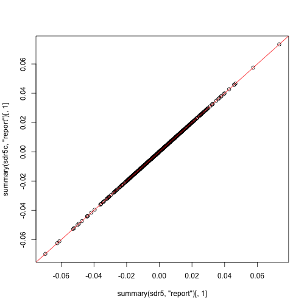

```r
sdr5csum <- summary(sdr5, "all")

plot(summary(sdr5, "report")[ , 1],
     summary(sdr5c, "report")[ , 1])
abline(0, 1, col = "red")
```

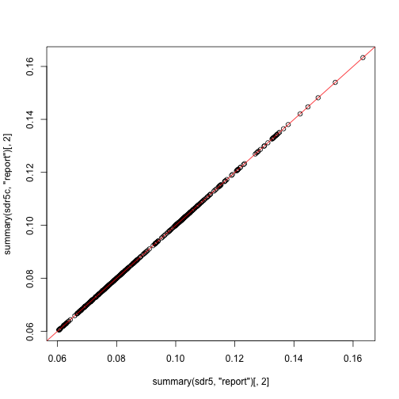

```r
plot(summary(sdr5, "report")[ , 2],
     summary(sdr5c, "report")[ , 2])
abline(0, 1, col = "red")
```

## Model 6: IID x RW1

Use and IID spatial effect, but a RW1 time effect. In this case, INLA by default does not add any constraint because the main effect is proper.

To match the `Cmatrix` implementation with the IID x RW1 implementation with the `group` option, the argument `rankdef` needs to be specified as the rank deficiency of the Kronecker product precision matrix. This is the number of areas.

```r
inlafit6 <- inla(Observed ~
                   f(as.integer(IDf), model = "iid", hyper = prec.prior,
                     graph = adj.mat, diagonal = diagval,
                     group = ID.Year, control.group = list(model = "rw1", scale.model = TRUE)),
                 data = data, E = Expected, family = "poisson",
                 control.inla = list(strategy = "gaussian", int.strategy = "eb"),
                 control.compute = list(config = TRUE))
```

Note that rank deficiency line in the log file pertains to the rank deficiency of the main IID effect, which has zero rank deficiency:

```r
grep(".*rank.*", inlafit6$logfile, value = TRUE)
```

```
## [1] "                computed/guessed rank-deficiency = [0]"
```

For the `group` model, the INLA log file does not make any comment about the rank deficiency. However, we will see below that internally that the rank deficiency which is imposed RW1 group model is accounted for.

#### INLA with custom Cmatrix

```r
R_space <- diag(ncol(adj.mat))

D_time <- diff(diag(length(levels(data$Yearf))), differences = 1)
R_time <- Matrix::Matrix(t(D_time) %*% D_time)
R_time_adj <- R_time + Matrix::Diagonal(ncol(R_time), 1e-6)

R_time_scaled <- inla.scale.model(R_time, constr = list(A = matrix(1, ncol = ncol(R_time)), e = 0))

R_space_time <- kronecker(R_time_scaled, R_space)

inlafit6C <- inla(Observed ~
                    f(id.area.year, model = "generic0", Cmatrix = R_space_time, hyper = prec.prior,
                      diagonal = diagval, rankdef = 32),
                  data = data, E = Expected, family = "poisson",
                  control.inla = list(strategy = "gaussian", int.strategy = "eb"),
                  control.compute = list(config = TRUE))
```

Here's the `rankdef` comment in the logfile:

```r
grep(".*rank.*", inlafit6C$logfile, value = TRUE)
```

```
## [1] "                rank-deficiency is *defined* [32]"
```

These results match:

```r
summary(inlafit6)
```

```
##
## Call:
##    c("inla.core(formula = formula, family = family, contrasts = contrasts, ", " data = data, quantiles = quantiles, E = E, offset = offset, ", " scale = scale, weights = weights, Ntrials = Ntrials, strata = strata, ",
##    " lp.scale = lp.scale, link.covariates = link.covariates, verbose = verbose, ", " lincomb = lincomb, selection = selection, control.compute = control.compute, ", " control.predictor = control.predictor,
##    control.family = control.family, ", " control.inla = control.inla, control.fixed = control.fixed, ", " control.mode = control.mode, control.expert = control.expert, ", " control.hazard = control.hazard,
##    control.lincomb = control.lincomb, ", " control.update = control.update, control.lp.scale = control.lp.scale, ", " control.pardiso = control.pardiso, only.hyperparam = only.hyperparam, ", " inla.call = inla.call,
##    inla.arg = inla.arg, num.threads = num.threads, ", " blas.num.threads = blas.num.threads, keep = keep, working.directory = working.directory, ", " silent = silent, inla.mode = inla.mode, safe = FALSE, debug = debug,
##    ", " .parent.frame = .parent.frame)")
## Time used:
##     Pre = 2.85, Running = 0.278, Post = 0.0364, Total = 3.16
## Fixed effects:
##               mean    sd 0.025quant 0.5quant 0.975quant mode kld
## (Intercept) -0.265 4.067     -8.236   -0.265      7.706   NA   0
##
## Random effects:
##   Name     Model
##     as.integer(IDf) IID model
##
## Model hyperparameters:
##                                 mean     sd 0.025quant 0.5quant 0.975quant mode
## Precision for as.integer(IDf) 463.12 695.03      42.18   261.51    2170.08   NA
##
## Marginal log-Likelihood:  -1089.57
##  is computed
## Posterior summaries for the linear predictor and the fitted values are computed
## (Posterior marginals needs also 'control.compute=list(return.marginals.predictor=TRUE)')
```

```r
summary(inlafit6C)
```

```
##
## Call:
##    c("inla.core(formula = formula, family = family, contrasts = contrasts, ", " data = data, quantiles = quantiles, E = E, offset = offset, ", " scale = scale, weights = weights, Ntrials = Ntrials, strata = strata, ",
##    " lp.scale = lp.scale, link.covariates = link.covariates, verbose = verbose, ", " lincomb = lincomb, selection = selection, control.compute = control.compute, ", " control.predictor = control.predictor,
##    control.family = control.family, ", " control.inla = control.inla, control.fixed = control.fixed, ", " control.mode = control.mode, control.expert = control.expert, ", " control.hazard = control.hazard,
##    control.lincomb = control.lincomb, ", " control.update = control.update, control.lp.scale = control.lp.scale, ", " control.pardiso = control.pardiso, only.hyperparam = only.hyperparam, ", " inla.call = inla.call,
##    inla.arg = inla.arg, num.threads = num.threads, ", " blas.num.threads = blas.num.threads, keep = keep, working.directory = working.directory, ", " silent = silent, inla.mode = inla.mode, safe = FALSE, debug = debug,
##    ", " .parent.frame = .parent.frame)")
## Time used:
##     Pre = 2.67, Running = 0.241, Post = 0.0162, Total = 2.93
## Fixed effects:
##               mean    sd 0.025quant 0.5quant 0.975quant mode kld
## (Intercept) -0.265 4.067     -8.236   -0.265      7.706   NA   0
##
## Random effects:
##   Name     Model
##     id.area.year Generic0 model
##
## Model hyperparameters:
##                              mean     sd 0.025quant 0.5quant 0.975quant mode
## Precision for id.area.year 463.11 694.95      42.18   261.52    2169.93   NA
##
## Marginal log-Likelihood:  -1089.57
##  is computed
## Posterior summaries for the linear predictor and the fitted values are computed
## (Posterior marginals needs also 'control.compute=list(return.marginals.predictor=TRUE)')
```

Marginal likelihood

```r
inlafit6$mlik
```

```
##                                            [,1]
## log marginal-likelihood (integration) -1090.779
## log marginal-likelihood (Gaussian)    -1089.572
```

```r
inlafit6C$mlik
```

```
##                                            [,1]
## log marginal-likelihood (integration) -1090.779
## log marginal-likelihood (Gaussian)    -1089.572
```

Same constraints (none)

```r
all.equal(inlafit6$misc$configs$constr,
          inlafit6C$misc$configs$constr)
```

```
## [1] TRUE
```

Hyper parameters

```r
inlafit6$internal.summary.hyperpar[, 1:2]
```

```
##                                       mean       sd
## Log precision for as.integer(IDf) 5.611272 0.997855
```

```r
inlafit6C$internal.summary.hyperpar[, 1:2]
```

```
##                                   mean        sd
## Log precision for id.area.year 5.61128 0.9978391
```

Fixed effects

```r
inlafit6$summary.fixed
```

```
##                   mean       sd 0.025quant   0.5quant 0.975quant mode kld
## (Intercept) -0.2650521 4.067064  -8.236351 -0.2650521   7.706247   NA   0
```

```r
inlafit6C$summary.fixed
```

```
##                   mean       sd 0.025quant   0.5quant 0.975quant mode kld
## (Intercept) -0.2650521 4.067064  -8.236351 -0.2650521   7.706247   NA   0
```

Random effects

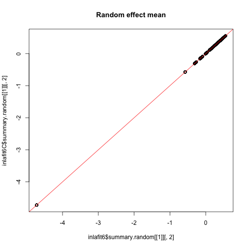

```r
plot(inlafit6$summary.random[[1]][,2],
     inlafit6C$summary.random[[1]][,2],
     main = "Random effect mean")
abline(a = 0, b = 1, col = "red")
```

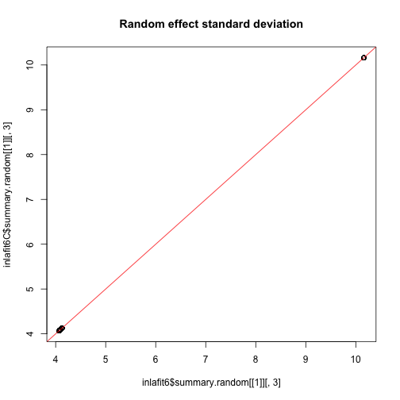

```r
plot(inlafit6$summary.random[[1]][,3],
     inlafit6C$summary.random[[1]][,3],
     main = "Random effect standard deviation")
abline(a = 0, b = 1, col = "red")
```

### TMB

```r
mod <- '
#include <TMB.hpp>

template<class Type>
Type objective_function<Type>::operator() ()
{

  using namespace density;

  DATA_VECTOR(y);
  DATA_VECTOR(E);

  DATA_SPARSE_MATRIX(Z_space_time);
  DATA_SPARSE_MATRIX(R_time);
  DATA_SPARSE_MATRIX(R_space);

  Type val(0);

  PARAMETER(beta0);
  // beta0 ~ 1

  PARAMETER(log_prec_space_time);
  val -= dlgamma(log_prec_space_time, Type(0.001), Type(1.0 / 0.001), true);
  Type sigma_space_time(exp(-0.5 * log_prec_space_time));

  PARAMETER_ARRAY(u_raw_space_time);
  vector<Type> u_space_time(u_raw_space_time * sigma_space_time);

  val += SEPARABLE(GMRF(R_time), GMRF(R_space))(u_raw_space_time);

  vector<Type> mu(beta0 +
                  Z_space_time * u_space_time +
                  log(E));
  val -= dpois(y, exp(mu), true).sum();

  ADREPORT(u_space_time);

  return val;
}
'

dll <- tmb_compile_and_load(mod)

tmbdata <- list(y = data$Observed,
                E = data$Expected,
                Z_space_time = Matrix::sparse.model.matrix(~0 + IDf:Yearf, data),
                R_space = as(R_space, "dgTMatrix"),
                R_time = R_time_adj)

tmbpar <- list(beta0 = 0,
               log_prec_space_time = 0,
               u_raw_space_time = array(0, c(nrow(tmbdata$R_space), nrow(tmbdata$R_time))))

obj <- TMB::MakeADFun(data = tmbdata,
                      parameters = tmbpar,
                      random = c("beta0", "u_raw_space_time"),
                      DLL = dll)
```

```
## Error in getParameterOrder(data, parameters, new.env(), DLL = DLL): Error when reading the variable: 'R_time'. Please check data and parameters.
```

```r
tmbfit <- nlminb(obj$par, obj$fn, obj$gr)
```

```
## iter: 1  value: 862.8109 mgc: 50.22775 ustep: 1
## iter: 2  value: 862.5859 mgc: 14.44042 ustep: 1
## iter: 3  value: 862.5858 mgc: 0.168829 ustep: 1
## iter: 4  value: 862.5858 mgc: 5.396528e-05 ustep: 1
## iter: 5  mgc: 3.49426e-11
## iter: 1  value: 862.8109 mgc: 50.22775 ustep: 1
## iter: 2  value: 862.5859 mgc: 14.44042 ustep: 1
## iter: 3  value: 862.5858 mgc: 0.168829 ustep: 1
## iter: 4  value: 862.5858 mgc: 5.396528e-05 ustep: 1
## iter: 5  mgc: 3.49426e-11
## outer mgc:  32.31075
## iter: 1  value: 897.9224 mgc: 24.08614 ustep: 1
## iter: 2  value: 897.9044 mgc: 4.238436 ustep: 1
## iter: 3  value: 897.9044 mgc: 0.01258994 ustep: 1
## iter: 4  value: 897.9044 mgc: 1.573064e-07 ustep: 1
## iter: 5  mgc: 2.531308e-14
## iter: 1  value: 897.9224 mgc: 24.08614 ustep: 1
## iter: 2  value: 897.9044 mgc: 4.238436 ustep: 1
## iter: 3  value: 897.9044 mgc: 0.01258994 ustep: 1
## iter: 4  value: 897.9044 mgc: 1.573064e-07 ustep: 1
## iter: 5  mgc: 2.531308e-14
## outer mgc:  13.02126
## iter: 1  value: 914.3439 mgc: 14.22568 ustep: 1
## iter: 2  value: 914.3418 mgc: 1.626241 ustep: 1
## iter: 3  value: 914.3418 mgc: 0.001474113 ustep: 1
## iter: 4  mgc: 1.231678e-09
## iter: 1  value: 914.3439 mgc: 14.22568 ustep: 1
## iter: 2  value: 914.3418 mgc: 1.626241 ustep: 1
## iter: 3  value: 914.3418 mgc: 0.001474113 ustep: 1
## iter: 4  mgc: 1.231678e-09
## outer mgc:  6.081237
## iter: 1  value: 924.4589 mgc: 8.452999 ustep: 1
## iter: 2  value: 924.4587 mgc: 0.5813331 ustep: 1
## iter: 3  value: 924.4587 mgc: 0.0001635456 ustep: 1
## iter: 4  mgc: 1.225231e-11
## iter: 1  value: 924.4589 mgc: 8.452999 ustep: 1
## iter: 2  value: 924.4587 mgc: 0.5813331 ustep: 1
## iter: 3  value: 924.4587 mgc: 0.0001635456 ustep: 1
## iter: 4  mgc: 1.225231e-11
## outer mgc:  2.703567
```

[output cut: 49 more lines]

```
## iter: 2  value: 937.9915 mgc: 2.339703e-08 ustep: 1
## mgc: 1.887379e-15
## iter: 1  value: 937.9915 mgc: 0.002194839 ustep: 1
## iter: 2  value: 937.9915 mgc: 2.339703e-08 ustep: 1
## mgc: 1.887379e-15
## outer mgc:  0.0002377358
## iter: 1  value: 937.9943 mgc: 2.297047e-05 ustep: 1
## iter: 2  mgc: 2.636003e-12
## iter: 1  value: 937.9943 mgc: 2.297047e-05 ustep: 1
## iter: 2  mgc: 2.636003e-12
## outer mgc:  2.488526e-06
## iter: 1  mgc: 2.45215e-12
## iter: 1  mgc: 2.45215e-12
## outer mgc:  1.557964e-09
## iter: 1  mgc: 2.45215e-12
```

```r
sdr6 <- TMB::sdreport(obj)
```

[output not shown]

```r
summary(sdr6, "all")
```

```
##                          Estimate Std. Error
## log_prec_space_time  3.875661e+00 1.69378108
## beta0               -5.221459e-03 0.03087566
## u_raw_space_time    -2.896786e-02 0.49002883
## u_raw_space_time     1.117100e-01 0.53582481
## u_raw_space_time    -8.877444e-02 0.59474099
## u_raw_space_time     9.327017e-02 0.49013512
## u_raw_space_time     1.662071e-01 0.71131738
## u_raw_space_time     7.612835e-02 0.47365455
## u_raw_space_time     1.057382e-01 0.45291800
## u_raw_space_time    -1.508944e-01 0.53754828
## u_raw_space_time    -3.983940e-02 0.51205428
## u_raw_space_time     6.331016e-02 0.70261911
## u_raw_space_time     5.276750e-02 0.40952776
## u_raw_space_time    -2.046752e-02 0.70584993
## u_raw_space_time     1.040578e-01 0.46992149
## u_raw_space_time     1.254558e-01 0.56131317
## u_raw_space_time    -1.378408e-02 0.60364491
## u_raw_space_time    -6.799266e-02 0.54046659
## u_raw_space_time     4.281944e-02 0.65596208
## u_raw_space_time    -1.293708e-02 0.80311525
## u_raw_space_time    -3.548134e-02 0.53336628
## u_raw_space_time    -9.496102e-02 0.71299924
## u_raw_space_time    -1.533059e-01 0.72586155
## u_raw_space_time    -1.117008e-01 0.71024056
## u_raw_space_time     8.187905e-03 0.50659036
## u_raw_space_time     3.481731e-02 0.57389435
## u_raw_space_time    -1.169782e-01 0.93547937
## u_raw_space_time    -1.042277e-01 0.72481393
## u_raw_space_time    -3.656632e-02 0.44488580
## u_raw_space_time     1.494457e-01 0.69758261
## u_raw_space_time    -6.052097e-02 0.72307000
## u_raw_space_time     7.882757e-02 0.70509371
## u_raw_space_time     7.363387e-02 0.53588237
## u_raw_space_time    -1.072031e-01 0.56510612
## u_raw_space_time     9.760119e-03 0.48332324
## u_raw_space_time     1.393751e-01 0.55678205
## u_raw_space_time    -4.154895e-02 0.58035940
## u_raw_space_time     1.166096e-01 0.52535747
## u_raw_space_time     5.334841e-02 0.71668358
```

[output cut: 447 more lines]

```
## u_raw_space_time    -8.415282e-02 0.71644482
## u_raw_space_time     2.616398e-02 0.48141058
## u_raw_space_time     1.819129e-01 0.49853453
## u_raw_space_time     9.775131e-02 0.52493511
## u_raw_space_time     9.310959e-02 0.52659557
## u_raw_space_time    -5.169691e-02 0.70849987
## u_raw_space_time     1.017134e-01 0.44510739
## u_raw_space_time    -5.374919e-02 0.70605690
## u_raw_space_time     7.058449e-02 0.49798655
## u_raw_space_time     4.832551e-01 0.61105863
## u_raw_space_time    -1.273195e-01 0.61136230
## u_raw_space_time     6.504203e-02 0.54605042
## u_raw_space_time    -4.634765e-02 0.65840473
## u_raw_space_time     1.159378e-02 0.80374509
##  [ reached getOption("max.print") -- omitted 699 rows ]
```

Hyper parameter comparison

The standard devation from TMB is somewhat larger than INLA.

```r
summary(sdr6, "fixed")
```

```
##                     Estimate Std. Error
## log_prec_space_time 3.875661   1.693781
```

```r
cbind("mean" = inlafit6$misc$theta.mode,
      "se" = sqrt(diag(inlafit6$misc$cov.intern)))
```

```
##          mean       se
## [1,] 5.386291 1.276547
```

Fixed effects (Intercept)

```r
summary(sdr6, "random")[1, , drop = FALSE]
```

```
##           Estimate Std. Error
## beta0 -0.005221459 0.03087566
```

```r
inlafit6$summary.fixed[ , 1:2]
```

```
##                   mean       sd
## (Intercept) -0.2650521 4.067064
```

```r
inlafit6C$summary.fixed[ , 1:2]
```

```
##                   mean       sd
## (Intercept) -0.2650521 4.067064
```

Random effects mean and standard deviation

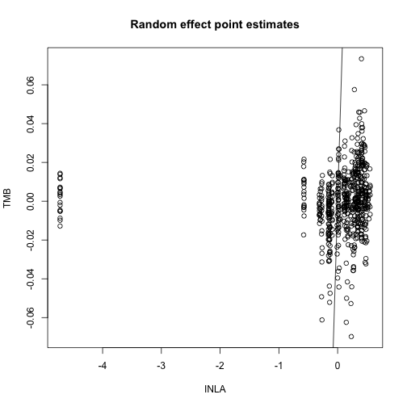

```r
plot(inlafit6$summary.random[[1]][,2], summary(sdr6, "report")[,1],
     xlab = "INLA", ylab = "TMB", main = "Random effect point estimates")
abline(0, 1)
```

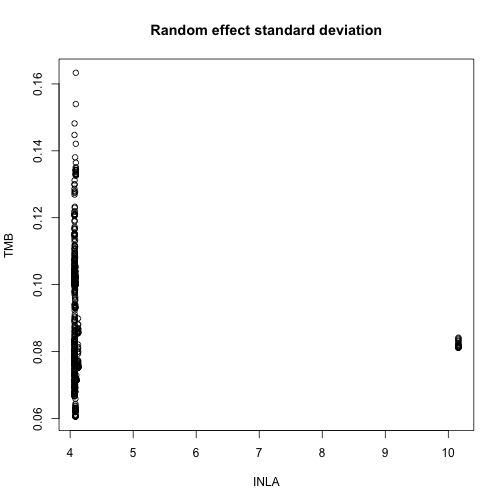

```r
plot(inlafit6$summary.random[[1]][,3], summary(sdr6, "report")[,2],
     xlab = "INLA", ylab = "TMB", main = "Random effect standard deviation")
abline(0, 1)
```

### Model 6b: Express GMRF as a Kronecker product

```r
mod <- '
#include <TMB.hpp>

template<class Type>
Type objective_function<Type>::operator() ()
{

  using namespace density;

  DATA_VECTOR(y);
  DATA_VECTOR(E);

  DATA_SPARSE_MATRIX(Z_space_time);
  DATA_SPARSE_MATRIX(R_space_time);

  Type val(0);

  PARAMETER(beta0);
  // beta0 ~ 1

  PARAMETER(log_prec_space_time);
  val -= dlgamma(log_prec_space_time, Type(0.001), Type(1.0 / 0.001), true);
  Type sigma_space_time(exp(-0.5 * log_prec_space_time));

  PARAMETER_ARRAY(u_raw_space_time);
  vector<Type> u_space_time(u_raw_space_time * sigma_space_time);

  val += GMRF(R_space_time)(u_raw_space_time);

  vector<Type> mu(beta0 +
                  Z_space_time * u_space_time +
                  log(E));
  val -= dpois(y, exp(mu), true).sum();

  ADREPORT(u_space_time);

  return val;
}
'

dll <- tmb_compile_and_load(mod)

## R_space_time_adj <- R_space_time + Matrix::Diagonal(ncol(R_space_time), diagval)
R_space_time_adj <- kronecker(R_time_adj, R_space)

tmbdata <- list(y = data$Observed,
                E = data$Expected,
                Z_space_time = Matrix::sparse.model.matrix(~0 + IDf:Yearf, data),
                R_space_time = R_space_time_adj)

tmbpar <- list(beta0 = 0,
               log_prec_space_time = 0,
               u_raw_space_time = array(0, c(nrow(tmbdata$R_space), nrow(tmbdata$R_time))))

obj <- TMB::MakeADFun(data = tmbdata,
                      parameters = tmbpar,
                      random = c("beta0", "u_raw_space_time"),
                      DLL = dll)
```

```
## Constructing atomic D_lgamma
## Constructing atomic D_lgamma
```

```r
tmbfit <- nlminb(obj$par, obj$fn, obj$gr)
```

[output not shown]

[output cut: 41 more lines]

```
## iter: 1  value: 1524.058 mgc: 1.972413 ustep: 1
## iter: 2  value: 1524.058 mgc: 0.003468667 ustep: 1
## iter: 3  mgc: 6.913069e-09
## iter: 1  mgc: 6.913069e-09
## outer mgc:  0.02462276
## iter: 1  value: 1524.033 mgc: 0.1627297 ustep: 1
## iter: 2  value: 1524.033 mgc: 2.355867e-05 ustep: 1
## iter: 3  mgc: 2.319811e-13
## iter: 1  mgc: 2.319811e-13
## outer mgc:  0.0002286624
## iter: 1  value: 1524.034 mgc: 0.00149678 ustep: 1
## iter: 2  mgc: 1.993601e-09
## iter: 1  mgc: 1.993601e-09
## outer mgc:  1.876793e-07
## iter: 1  mgc: 1.993601e-09
```

```r
sdr6b <- TMB::sdreport(obj)
```

```
## iter: 1  mgc: 1.993601e-09
## outer mgc:  1.876793e-07
## iter: 1  value: 1524.048 mgc: 0.09715469 ustep: 1
## iter: 2  value: 1524.048 mgc: 8.400313e-06 ustep: 1
## iter: 3  mgc: 8.815171e-14
## outer mgc:  0.01484237
## iter: 1  value: 1524.019 mgc: 0.09722075 ustep: 1
## iter: 2  value: 1524.019 mgc: 8.408516e-06 ustep: 1
## iter: 3  mgc: 9.267814e-14
## outer mgc:  0.01482806
## outer mgc:  0.6160524
```

```r
summary(sdr6b, "all")
```

```
##                          Estimate  Std. Error
## log_prec_space_time  9.558215e+00   0.2596289
## beta0               -1.476750e-01   0.3478549
## u_raw_space_time     2.777543e+01  41.9670255
## u_raw_space_time    -2.248671e+01  86.3536077
## u_raw_space_time     3.805117e+01  44.0952263
## u_raw_space_time    -1.214896e+01  53.8202427
## u_raw_space_time     2.024617e+01  45.5889354
## u_raw_space_time    -2.830052e+01  86.1829076
## u_raw_space_time     1.179770e+01  43.3376305
## u_raw_space_time    -1.241089e+01  45.4971490
## u_raw_space_time    -3.025881e+01  50.0311401
## u_raw_space_time     5.189801e+00  69.5374671
## u_raw_space_time    -1.466181e+02 155.2819607
## u_raw_space_time     4.689832e+00  65.1244306
## u_raw_space_time    -2.956390e+01  46.0953632
## u_raw_space_time    -4.822344e+01  59.6468240
## u_raw_space_time     3.670473e+01  49.2571397
## u_raw_space_time    -4.490938e+01  54.0678828
## u_raw_space_time     3.439532e+01  45.9310570
## u_raw_space_time    -7.291325e+01  85.1027599
## u_raw_space_time    -3.154737e+01  47.5817547
## u_raw_space_time     2.563180e+01  52.2343838
## u_raw_space_time     3.559764e+01  46.6155827
## u_raw_space_time     1.953930e+01  50.3851646
## u_raw_space_time     2.464318e+01  47.6707198
## u_raw_space_time    -1.218690e+01  47.0191422
## u_raw_space_time     1.647580e+01  44.1963040
## u_raw_space_time     3.081966e+01  43.4987549
## u_raw_space_time     4.249013e+01  50.1282846
## u_raw_space_time     4.859942e+01  51.2194822
## u_raw_space_time    -5.303429e-01  50.3410887
## u_raw_space_time     4.916402e-01  59.5315476
## u_raw_space_time     2.645714e+01  62.1310198
## u_raw_space_time     4.107684e+01  44.3680458
## u_raw_space_time     2.777958e+01  41.9562157
## u_raw_space_time    -2.248593e+01  86.3483679
## u_raw_space_time     3.805745e+01  44.0848147
## u_raw_space_time    -1.214454e+01  53.8118734
## u_raw_space_time     2.024459e+01  45.5790677
```

[output cut: 447 more lines]

```
## u_raw_space_time     1.991114e+01  45.5611062
## u_raw_space_time    -2.838635e+01  86.1694699
## u_raw_space_time     1.225653e+01  43.2845200
## u_raw_space_time    -1.215606e+01  45.4641119
## u_raw_space_time    -3.010324e+01  49.9994221
## u_raw_space_time     5.379052e+00  69.5212930
## u_raw_space_time    -1.466173e+02 155.2754093
## u_raw_space_time     4.531954e+00  65.1023551
## u_raw_space_time    -2.962887e+01  46.0601092
## u_raw_space_time    -4.815146e+01  59.6155853
## u_raw_space_time     3.704848e+01  49.2161255
## u_raw_space_time    -4.491174e+01  54.0337708
## u_raw_space_time     3.440836e+01  45.8965507
## u_raw_space_time    -7.293377e+01  85.0882537
##  [ reached getOption("max.print") -- omitted 718 rows ]
```

Hyper parameter comparison

The standard devation from TMB is somewhat larger than INLA.

```r
summary(sdr6, "fixed")
```

```
##                     Estimate Std. Error
## log_prec_space_time 3.875661   1.693781
```

```r
summary(sdr6b, "fixed")
```

```
##                     Estimate Std. Error
## log_prec_space_time 9.558215  0.2596289
```

```r
cbind("mean" = inlafit6$misc$theta.mode,
      "se" = sqrt(diag(inlafit6$misc$cov.intern)))
```

```
##          mean       se
## [1,] 5.386291 1.276547
```

Fixed effects (Intercept)

```r
summary(sdr6, "random")[1, , drop = FALSE]
```

```
##           Estimate Std. Error
## beta0 -0.005221459 0.03087566
```

```r
summary(sdr6b, "random")[1, , drop = FALSE]
```

```
##        Estimate Std. Error
## beta0 -0.147675  0.3478549
```

Random effects mean and standard deviation

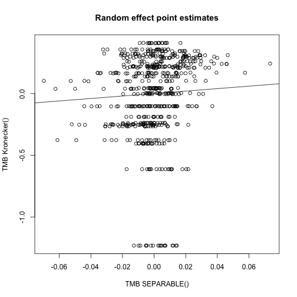

```r
plot(summary(sdr6, "report")[,1], summary(sdr6b, "report")[,1],
     xlab = "TMB SEPARABLE()", ylab = "TMB Kronecker()", main = "Random effect point estimates")
abline(0, 1)
```

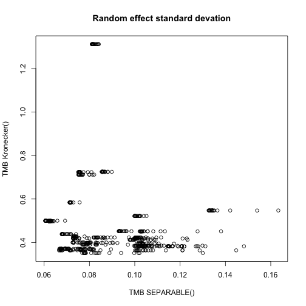

```r
plot(summary(sdr6, "report")[,2], summary(sdr6b, "report")[,2],
     xlab = "TMB SEPARABLE()", ylab = "TMB Kronecker()", main = "Random effect standard devation")
abline(0, 1)
```

## Model 7: IID x RW1 with constraints

By changing the order of the main and group terms in the INLA smooth formula, we can implement the same model with constratints on the RW1 terms

First fit the unconstrained model and confirm it matches the previous version.

```r
inlafit7_unconstr <- inla(Observed ~
                            f(ID.Year, model = "rw1", hyper = prec.prior,
                              scale.model = TRUE, diagonal = diagval, constr = FALSE,
                              group = ID, control.group = list(model = "iid")),
                          data = data, E = Expected, family = "poisson",
                          control.inla = list(strategy = "gaussian", int.strategy = "eb"),
                          control.compute = list(config = TRUE))

summary(inlafit6)
```

```
##
## Call:
##    c("inla.core(formula = formula, family = family, contrasts = contrasts, ", " data = data, quantiles = quantiles, E = E, offset = offset, ", " scale = scale, weights = weights, Ntrials = Ntrials, strata = strata, ",
##    " lp.scale = lp.scale, link.covariates = link.covariates, verbose = verbose, ", " lincomb = lincomb, selection = selection, control.compute = control.compute, ", " control.predictor = control.predictor,
##    control.family = control.family, ", " control.inla = control.inla, control.fixed = control.fixed, ", " control.mode = control.mode, control.expert = control.expert, ", " control.hazard = control.hazard,
##    control.lincomb = control.lincomb, ", " control.update = control.update, control.lp.scale = control.lp.scale, ", " control.pardiso = control.pardiso, only.hyperparam = only.hyperparam, ", " inla.call = inla.call,
##    inla.arg = inla.arg, num.threads = num.threads, ", " blas.num.threads = blas.num.threads, keep = keep, working.directory = working.directory, ", " silent = silent, inla.mode = inla.mode, safe = FALSE, debug = debug,
##    ", " .parent.frame = .parent.frame)")
## Time used:
##     Pre = 2.85, Running = 0.278, Post = 0.0364, Total = 3.16
## Fixed effects:
##               mean    sd 0.025quant 0.5quant 0.975quant mode kld
## (Intercept) -0.265 4.067     -8.236   -0.265      7.706   NA   0
##
## Random effects:
##   Name     Model
##     as.integer(IDf) IID model
##
## Model hyperparameters:
##                                 mean     sd 0.025quant 0.5quant 0.975quant mode
## Precision for as.integer(IDf) 463.12 695.03      42.18   261.51    2170.08   NA
##
## Marginal log-Likelihood:  -1089.57
##  is computed
## Posterior summaries for the linear predictor and the fitted values are computed
## (Posterior marginals needs also 'control.compute=list(return.marginals.predictor=TRUE)')
```

```r
summary(inlafit7_unconstr)
```

```
##
## Call:
##    c("inla.core(formula = formula, family = family, contrasts = contrasts, ", " data = data, quantiles = quantiles, E = E, offset = offset, ", " scale = scale, weights = weights, Ntrials = Ntrials, strata = strata, ",
##    " lp.scale = lp.scale, link.covariates = link.covariates, verbose = verbose, ", " lincomb = lincomb, selection = selection, control.compute = control.compute, ", " control.predictor = control.predictor,
##    control.family = control.family, ", " control.inla = control.inla, control.fixed = control.fixed, ", " control.mode = control.mode, control.expert = control.expert, ", " control.hazard = control.hazard,
##    control.lincomb = control.lincomb, ", " control.update = control.update, control.lp.scale = control.lp.scale, ", " control.pardiso = control.pardiso, only.hyperparam = only.hyperparam, ", " inla.call = inla.call,
##    inla.arg = inla.arg, num.threads = num.threads, ", " blas.num.threads = blas.num.threads, keep = keep, working.directory = working.directory, ", " silent = silent, inla.mode = inla.mode, safe = FALSE, debug = debug,
##    ", " .parent.frame = .parent.frame)")
## Time used:
##     Pre = 2.73, Running = 0.306, Post = 0.0229, Total = 3.06
## Fixed effects:
##               mean    sd 0.025quant 0.5quant 0.975quant mode kld
## (Intercept) -0.265 4.067     -8.236   -0.265      7.706   NA   0
##
## Random effects:
##   Name     Model
##     ID.Year RW1 model
##
## Model hyperparameters:
##                         mean     sd 0.025quant 0.5quant 0.975quant mode
## Precision for ID.Year 463.12 695.01      42.18   261.51    2170.03   NA
##
## Marginal log-Likelihood:  -1089.57
##  is computed
## Posterior summaries for the linear predictor and the fitted values are computed
## (Posterior marginals needs also 'control.compute=list(return.marginals.predictor=TRUE)')
```

Fit the model with default sum-to-zero constraints on each group.

```r
inlafit7 <- inla(Observed ~
                   f(ID.Year, model = "rw1", hyper = prec.prior,
                     scale.model = TRUE, diagonal = diagval, constr = TRUE,
                     group = ID, control.group = list(model = "iid")),
                 data = data, E = Expected, family = "poisson",
                 control.inla = list(strategy = "gaussian", int.strategy = "eb"),
                 control.compute = list(config = TRUE))

grep(".*rank.*", inlafit7_unconstr$logfile, value = TRUE)
```

```
## [1] "                computed/guessed rank-deficiency = [1]"
```

#### INLA with custom Cmatrix

```r
R_space <- diag(ncol(adj.mat))

D_time <- diff(diag(length(levels(data$Yearf))), differences = 1)
R_time <- Matrix::Matrix(t(D_time) %*% D_time)
R_time_adj <- R_time + Matrix::Diagonal(ncol(R_time), 1e-6)

R_time_scaled <- inla.scale.model(R_time, constr = list(A = matrix(1, ncol = ncol(R_time)), e = 0))

R_space_time <- kronecker(R_time_scaled, R_space)

Aconstr <- t(model.matrix(~0+factor(IDf), data[order(data$id.area.year), ]))

inlafit7C <- inla(Observed ~
                   f(id.area.year, model = "generic0", Cmatrix = R_space_time, hyper = prec.prior,
                     extraconstr = list(A = Aconstr, e = numeric(nrow(Aconstr))),
                     diagonal = diagval),
                  data = data, E = Expected, family = "poisson",
                  control.inla = list(strategy = "gaussian", int.strategy = "eb"),
                  control.compute = list(config = TRUE))


grep(".*rank.*", inlafit7C$logfile, value = TRUE)
```

```
## [1] "                computed/guessed rank-deficiency = [32]"
```

These results match:

```r
summary(inlafit7)
```

```
##
## Call:
##    c("inla.core(formula = formula, family = family, contrasts = contrasts, ", " data = data, quantiles = quantiles, E = E, offset = offset, ", " scale = scale, weights = weights, Ntrials = Ntrials, strata = strata, ",
##    " lp.scale = lp.scale, link.covariates = link.covariates, verbose = verbose, ", " lincomb = lincomb, selection = selection, control.compute = control.compute, ", " control.predictor = control.predictor,
##    control.family = control.family, ", " control.inla = control.inla, control.fixed = control.fixed, ", " control.mode = control.mode, control.expert = control.expert, ", " control.hazard = control.hazard,
##    control.lincomb = control.lincomb, ", " control.update = control.update, control.lp.scale = control.lp.scale, ", " control.pardiso = control.pardiso, only.hyperparam = only.hyperparam, ", " inla.call = inla.call,
##    inla.arg = inla.arg, num.threads = num.threads, ", " blas.num.threads = blas.num.threads, keep = keep, working.directory = working.directory, ", " silent = silent, inla.mode = inla.mode, safe = FALSE, debug = debug,
##    ", " .parent.frame = .parent.frame)")
## Time used:
##     Pre = 2.57, Running = 0.323, Post = 0.0229, Total = 2.91
## Fixed effects:
##               mean    sd 0.025quant 0.5quant 0.975quant mode kld
## (Intercept) -0.004 0.029     -0.061   -0.004      0.054   NA   0
##
## Random effects:
##   Name     Model
##     ID.Year RW1 model
##
## Model hyperparameters:
##                         mean     sd 0.025quant 0.5quant 0.975quant mode
## Precision for ID.Year 453.97 768.35      40.68   238.75    2237.85   NA
##
## Marginal log-Likelihood:  -1150.48
##  is computed
## Posterior summaries for the linear predictor and the fitted values are computed
## (Posterior marginals needs also 'control.compute=list(return.marginals.predictor=TRUE)')
```

```r
summary(inlafit7C)
```

```
##
## Call:
##    c("inla.core(formula = formula, family = family, contrasts = contrasts, ", " data = data, quantiles = quantiles, E = E, offset = offset, ", " scale = scale, weights = weights, Ntrials = Ntrials, strata = strata, ",
##    " lp.scale = lp.scale, link.covariates = link.covariates, verbose = verbose, ", " lincomb = lincomb, selection = selection, control.compute = control.compute, ", " control.predictor = control.predictor,
##    control.family = control.family, ", " control.inla = control.inla, control.fixed = control.fixed, ", " control.mode = control.mode, control.expert = control.expert, ", " control.hazard = control.hazard,
##    control.lincomb = control.lincomb, ", " control.update = control.update, control.lp.scale = control.lp.scale, ", " control.pardiso = control.pardiso, only.hyperparam = only.hyperparam, ", " inla.call = inla.call,
##    inla.arg = inla.arg, num.threads = num.threads, ", " blas.num.threads = blas.num.threads, keep = keep, working.directory = working.directory, ", " silent = silent, inla.mode = inla.mode, safe = FALSE, debug = debug,
##    ", " .parent.frame = .parent.frame)")
## Time used:
##     Pre = 2.88, Running = 0.327, Post = 0.017, Total = 3.22
## Fixed effects:
##               mean    sd 0.025quant 0.5quant 0.975quant mode kld
## (Intercept) -0.004 0.029     -0.061   -0.004      0.054   NA   0
##
## Random effects:
##   Name     Model
##     id.area.year Generic0 model
##
## Model hyperparameters:
##                              mean     sd 0.025quant 0.5quant 0.975quant mode
## Precision for id.area.year 453.97 768.35      40.68   238.75    2237.85   NA
##
## Marginal log-Likelihood:  -1150.48
##  is computed
## Posterior summaries for the linear predictor and the fitted values are computed
## (Posterior marginals needs also 'control.compute=list(return.marginals.predictor=TRUE)')
```

Marginal likelihood

```r
inlafit7$mlik
```

```
##                                            [,1]
## log marginal-likelihood (integration) -1151.690
## log marginal-likelihood (Gaussian)    -1150.483
```

```r
inlafit7C$mlik
```

```
##                                            [,1]
## log marginal-likelihood (integration) -1151.690
## log marginal-likelihood (Gaussian)    -1150.483
```

Same constraints

```r
dim(inlafit7$misc$configs$constr$A)
```

```
## [1]   32 1217
```

```r
dim(inlafit7C$misc$configs$constr$A)
```

```
## [1]   32 1217
```

Hyper parameters

```r
inlafit7$internal.summary.hyperpar[, 1:2]
```

```
##                               mean       sd
## Log precision for ID.Year 5.546423 1.020042
```

```r
inlafit7C$internal.summary.hyperpar[, 1:2]
```

```
##                                    mean       sd
## Log precision for id.area.year 5.546424 1.020041
```

Fixed effects

```r
inlafit7$summary.fixed
```

```
##                     mean         sd  0.025quant     0.5quant 0.975quant mode kld
## (Intercept) -0.003723029 0.02931042 -0.06117039 -0.003723029 0.05372434   NA   0
```

```r
inlafit7C$summary.fixed
```

```
##                    mean         sd  0.025quant    0.5quant 0.975quant mode kld
## (Intercept) -0.00372303 0.02931042 -0.06117039 -0.00372303 0.05372433   NA   0
```

Random effects

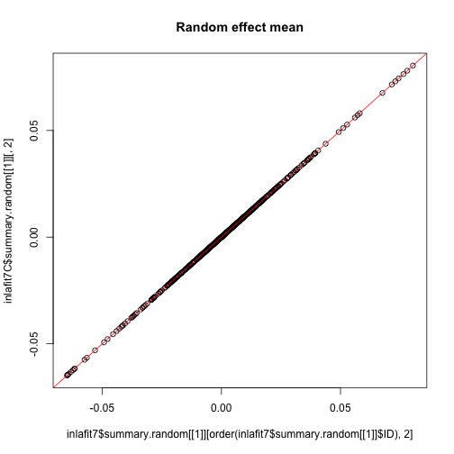

```r
plot(inlafit7$summary.random[[1]][order(inlafit7$summary.random[[1]]$ID), 2],
     inlafit7C$summary.random[[1]][,2],
     main = "Random effect mean")
abline(a = 0, b = 1, col = "red")
```

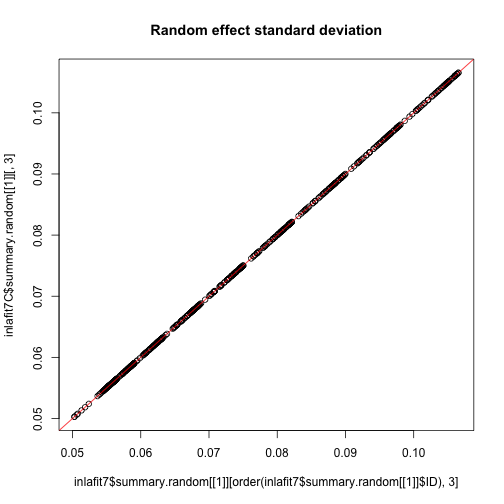

```r
plot(inlafit7$summary.random[[1]][order(inlafit7$summary.random[[1]]$ID), 3],
     inlafit7C$summary.random[[1]][,3],
     main = "Random effect standard deviation")
abline(a = 0, b = 1, col = "red")
```

### TMB

```r
mod <- '
#include <TMB.hpp>

template<class Type>
Type objective_function<Type>::operator() ()
{

  using namespace density;

  DATA_VECTOR(y);
  DATA_VECTOR(E);

  DATA_MATRIX(Aconstr);
  DATA_SPARSE_MATRIX(Z_space_time);
  DATA_SPARSE_MATRIX(R_time);
  DATA_SPARSE_MATRIX(R_space);

  Type val(0);

  PARAMETER(beta0);
  // beta0 ~ 1

  PARAMETER(log_prec_space_time);
  val -= dlgamma(log_prec_space_time, Type(0.001), Type(1.0 / 0.001), true);
  Type sigma_space_time(exp(-0.5 * log_prec_space_time));

  PARAMETER_ARRAY(u_raw_space_time);
  vector<Type> u_raw_space_time_v(u_raw_space_time);
  vector<Type> u_space_time(u_raw_space_time_v * sigma_space_time);

  val += SEPARABLE(GMRF(R_time), GMRF(R_space))(u_raw_space_time);
  val -= dnorm(Aconstr * u_raw_space_time_v, Type(0), Type(0.001) * u_raw_space_time.cols(), true).sum();  // soft sum-to-zero constraint

  vector<Type> mu(beta0 +
                  Z_space_time * u_space_time +
                  log(E));
  val -= dpois(y, exp(mu), true).sum();

  ADREPORT(u_space_time);

  return val;
}
'

dll <- tmb_compile_and_load(mod)

tmbdata <- list(y = data$Observed,
                E = data$Expected,
                Aconstr = Aconstr,
                Z_space_time = Matrix::sparse.model.matrix(~0 + IDf:Yearf, data),
                R_space = as(R_space, "dgTMatrix"),
                R_time = R_time_adj)

tmbpar <- list(beta0 = 0,
               log_prec_space_time = 0,
               u_raw_space_time = array(0, c(nrow(tmbdata$R_space), nrow(tmbdata$R_time))))

obj <- TMB::MakeADFun(data = tmbdata,
                      parameters = tmbpar,
                      random = c("beta0", "u_raw_space_time"),
                      DLL = dll)
```

[output not shown]

```r
tmbfit <- nlminb(obj$par, obj$fn, obj$gr)
```

[output not shown]

[output cut: 283 more lines]

```
## iter: 2  value: 1524.058 mgc: 2.309505e-05 ustep: 1
## iter: 3  mgc: 1.517675e-13
## iter: 1  value: 1524.058 mgc: 0.1610824 ustep: 1
## iter: 2  value: 1524.058 mgc: 2.309505e-05 ustep: 1
## iter: 3  mgc: 1.517675e-13
## outer mgc:  0.02462229
## iter: 1  value: 1524.033 mgc: 0.001496749 ustep: 1
## iter: 2  mgc: 1.993273e-09
## iter: 1  value: 1524.033 mgc: 0.001496749 ustep: 1
## iter: 2  mgc: 1.993273e-09
## outer mgc:  0.0002286556
## iter: 1  mgc: 1.654667e-09
## iter: 1  mgc: 1.654667e-09
## outer mgc:  1.876232e-07
## iter: 1  mgc: 1.654667e-09
```

```r
sdr7 <- TMB::sdreport(obj)
```

```
## iter: 1  mgc: 1.654667e-09
## outer mgc:  1.876232e-07
## iter: 1  value: 1524.048 mgc: 0.09715469 ustep: 1
## iter: 2  value: 1524.048 mgc: 8.400313e-06 ustep: 1
## iter: 3  mgc: 1.548761e-13
## outer mgc:  0.01484237
## iter: 1  value: 1524.019 mgc: 0.09722075 ustep: 1
## iter: 2  value: 1524.019 mgc: 8.408516e-06 ustep: 1
## iter: 3  mgc: 1.0722e-13
## outer mgc:  0.01482806
## outer mgc:  0.6160524
```

```r
summary(sdr7, "all")
```

```
##                          Estimate  Std. Error
## log_prec_space_time  9.558215e+00   0.2596289
## beta0               -1.476750e-01   0.3478549
## u_raw_space_time     2.777543e+01  41.9670255
## u_raw_space_time    -2.248671e+01  86.3536077
## u_raw_space_time     3.805117e+01  44.0952263
## u_raw_space_time    -1.214896e+01  53.8202427
## u_raw_space_time     2.024617e+01  45.5889354
## u_raw_space_time    -2.830052e+01  86.1829076
## u_raw_space_time     1.179770e+01  43.3376305
## u_raw_space_time    -1.241089e+01  45.4971490
## u_raw_space_time    -3.025881e+01  50.0311401
## u_raw_space_time     5.189801e+00  69.5374671
## u_raw_space_time    -1.466181e+02 155.2819607
## u_raw_space_time     4.689832e+00  65.1244306
## u_raw_space_time    -2.956390e+01  46.0953632
## u_raw_space_time    -4.822344e+01  59.6468240
## u_raw_space_time     3.670473e+01  49.2571397
## u_raw_space_time    -4.490938e+01  54.0678828
## u_raw_space_time     3.439532e+01  45.9310570
## u_raw_space_time    -7.291325e+01  85.1027599
## u_raw_space_time    -3.154737e+01  47.5817547
## u_raw_space_time     2.563180e+01  52.2343838
## u_raw_space_time     3.559764e+01  46.6155827
## u_raw_space_time     1.953930e+01  50.3851646
## u_raw_space_time     2.464318e+01  47.6707198
## u_raw_space_time    -1.218690e+01  47.0191422
## u_raw_space_time     1.647580e+01  44.1963040
## u_raw_space_time     3.081966e+01  43.4987549
## u_raw_space_time     4.249013e+01  50.1282846
## u_raw_space_time     4.859942e+01  51.2194822
## u_raw_space_time    -5.303429e-01  50.3410887
## u_raw_space_time     4.916402e-01  59.5315476
## u_raw_space_time     2.645714e+01  62.1310198
## u_raw_space_time     4.107684e+01  44.3680458
## u_raw_space_time     2.777958e+01  41.9562157
## u_raw_space_time    -2.248593e+01  86.3483679
## u_raw_space_time     3.805745e+01  44.0848147
## u_raw_space_time    -1.214454e+01  53.8118734
## u_raw_space_time     2.024459e+01  45.5790677
```

[output cut: 447 more lines]

```
## u_raw_space_time     1.991114e+01  45.5611062
## u_raw_space_time    -2.838635e+01  86.1694699
## u_raw_space_time     1.225653e+01  43.2845200
## u_raw_space_time    -1.215606e+01  45.4641119
## u_raw_space_time    -3.010324e+01  49.9994221
## u_raw_space_time     5.379052e+00  69.5212930
## u_raw_space_time    -1.466173e+02 155.2754093
## u_raw_space_time     4.531954e+00  65.1023551
## u_raw_space_time    -2.962887e+01  46.0601092
## u_raw_space_time    -4.815146e+01  59.6155853
## u_raw_space_time     3.704848e+01  49.2161255
## u_raw_space_time    -4.491174e+01  54.0337708
## u_raw_space_time     3.440836e+01  45.8965507
## u_raw_space_time    -7.293377e+01  85.0882537
##  [ reached getOption("max.print") -- omitted 718 rows ]
```

Hyper parameter comparison

```r
summary(sdr7, "fixed")
```

```
##                     Estimate Std. Error
## log_prec_space_time 9.558215  0.2596289
```

```r
cbind("mean" = inlafit7C$misc$theta.mode,
      "se" = sqrt(diag(inlafit7C$misc$cov.intern)))
```

```
##          mean       se
## [1,] 5.187209 1.178537
```

Fixed effects (Intercept)

```r
summary(sdr7, "random")[1, , drop = FALSE]
```

```
##        Estimate Std. Error
## beta0 -0.147675  0.3478549
```

```r
inlafit7$summary.fixed[ , 1:2]
```

```
##                     mean         sd
## (Intercept) -0.003723029 0.02931042
```

```r
inlafit7C$summary.fixed[ , 1:2]
```

```
##                    mean         sd
## (Intercept) -0.00372303 0.02931042
```

Random effects mean and standard deviation

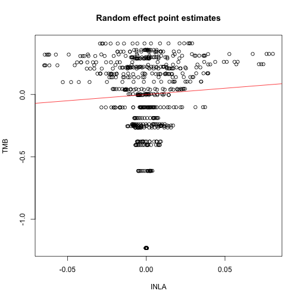

```r
plot(inlafit7C$summary.random[[1]][,2], summary(sdr7, "report")[,1],
     xlab = "INLA", ylab = "TMB", main = "Random effect point estimates")
abline(0, 1, col = "red")
```

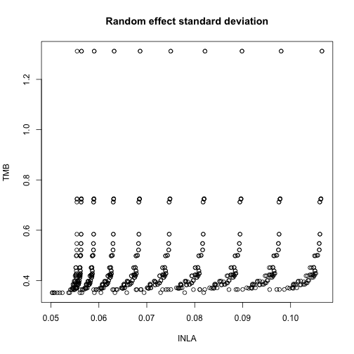

```r
plot(inlafit7C$summary.random[[1]][,3], summary(sdr7, "report")[,2],
     xlab = "INLA", ylab = "TMB", main = "Random effect standard deviation")
abline(0, 1, col = "red")
```

### Model 7b: Explicit sum-to-zero constraint

```r
mod <- '
#include <TMB.hpp>

template<class Type>
Type objective_function<Type>::operator() ()
{

  using namespace density;

  DATA_VECTOR(y);
  DATA_VECTOR(E);

  DATA_MATRIX(L_space_time)
  DATA_SPARSE_MATRIX(Z_space_time);
  DATA_SPARSE_MATRIX(LRL_space_time);

  Type val(0);

  PARAMETER(beta0);
  // beta0 ~ 1

  PARAMETER(log_prec_space_time);
  val -= dlgamma(log_prec_space_time, Type(0.001), Type(1.0 / 0.001), true);
  Type sigma_space_time(exp(-0.5 * log_prec_space_time));

  PARAMETER_VECTOR(u_raw_space_time);
  vector<Type> u_space_time(L_space_time * u_raw_space_time * sigma_space_time);

  val += GMRF(LRL_space_time)(u_raw_space_time);

  vector<Type> mu(beta0 +
                  Z_space_time * u_space_time +
                  log(E));
  val -= dpois(y, exp(mu), true).sum();

  ADREPORT(u_space_time);

  return val;
}
'

dll <- tmb_compile_and_load(mod)

qrc <- qr(t(Aconstr))
L_space_time <- qr.Q(qrc, complete=TRUE)[ , (nrow(Aconstr)+1):ncol(Aconstr)]

tmbdata <- list(y = data$Observed,
                E = data$Expected,
                L_space_time = L_space_time,
                Z_space_time = Matrix::sparse.model.matrix(~0 + IDf:Yearf, data),
                LRL_space_time = as(t(L_space_time) %*% R_space_time %*% L_space_time, "dgCMatrix"))

tmbpar <- list(beta0 = 0,
               log_prec_space_time = 0,
               u_raw_space_time = numeric(ncol(tmbdata$L_space_time)))

obj <- TMB::MakeADFun(data = tmbdata,
                      parameters = tmbpar,
                      random = c("beta0", "u_raw_space_time"),
                      DLL = dll)
```

```
## Constructing atomic D_lgamma
## Constructing atomic D_lgamma
```

```r
tmbfit <- nlminb(obj$par, obj$fn, obj$gr)
```

[output not shown]

[output cut: 19 more lines]

```
## iter: 1  value: 974.5184 mgc: 0.07018747 ustep: 1
## iter: 2  value: 974.5184 mgc: 2.597085e-05 ustep: 1
## iter: 3  mgc: 3.614886e-13
## iter: 1  mgc: 3.614886e-13
## outer mgc:  0.001234539
## iter: 1  value: 974.5234 mgc: 0.004346034 ustep: 1
## iter: 2  value: 974.5234 mgc: 1.005215e-07 ustep: 1
## mgc: 8.193446e-14
## iter: 1  mgc: 8.193446e-14
## outer mgc:  1.275038e-05
## iter: 1  value: 974.5235 mgc: 4.532512e-05 ustep: 1
## iter: 2  mgc: 1.091305e-11
## iter: 1  mgc: 1.091305e-11
## outer mgc:  7.804207e-09
## iter: 1  mgc: 1.091305e-11
```

```r
sdr7b <- TMB::sdreport(obj)
```

```
## iter: 1  mgc: 1.091305e-11
## outer mgc:  7.804207e-09
## iter: 1  value: 974.5264 mgc: 0.002528744 ustep: 1
## iter: 2  value: 974.5264 mgc: 3.40326e-08 ustep: 1
## mgc: 7.771561e-15
## outer mgc:  0.0007108925
## iter: 1  value: 974.5206 mgc: 0.002530358 ustep: 1
## iter: 2  value: 974.5206 mgc: 3.411937e-08 ustep: 1
## mgc: 1.423306e-13
## outer mgc:  0.0007114098
## outer mgc:  0.07154979
```

```r
summary(sdr7b, "all")
```

```
##                          Estimate Std. Error
## log_prec_space_time  5.187216e+00 1.18582076
## beta0               -3.722469e-03 0.02944028
## u_raw_space_time    -7.060124e-01 0.81226878
## u_raw_space_time    -8.113415e-02 1.07396708
## u_raw_space_time    -6.841674e-01 1.04289438
## u_raw_space_time    -6.955986e-03 1.05691721
## u_raw_space_time     4.255400e-01 1.04592457
## u_raw_space_time     1.040200e-01 1.07419372
## u_raw_space_time    -5.072628e-01 0.99715253
## u_raw_space_time    -2.281876e-01 1.01949252
## u_raw_space_time    -1.338802e-01 1.04480063
## u_raw_space_time    -2.271769e-01 1.07830340
## u_raw_space_time    -4.653864e-03 1.07502399
## u_raw_space_time     2.226836e-01 1.07661509
## u_raw_space_time     1.678756e-01 1.01627524
## u_raw_space_time     5.748908e-03 1.06017694
## u_raw_space_time    -4.368179e-01 1.08014594
## u_raw_space_time     1.022142e-01 1.05309465
## u_raw_space_time    -7.011092e-02 1.03699335
## u_raw_space_time     1.164380e-02 1.07012985
## u_raw_space_time     1.425252e-01 1.02935391
## u_raw_space_time    -1.651308e-01 1.06307420
## u_raw_space_time     1.285608e-01 1.04370277
## u_raw_space_time     8.723741e-02 1.05513568
## u_raw_space_time    -3.817783e-01 1.06413415
## u_raw_space_time     1.994751e-01 1.03749127
## u_raw_space_time    -6.514972e-02 1.00791929
## u_raw_space_time    -2.055218e-01 0.98967065
## u_raw_space_time    -6.433440e-02 1.05848594
## u_raw_space_time    -3.038383e-01 1.07407116
## u_raw_space_time    -6.415935e-02 1.05153231
## u_raw_space_time     1.038974e-01 1.06726745
## u_raw_space_time     1.252057e-01 1.07123156
## u_raw_space_time     1.815722e-01 1.02345493
## u_raw_space_time    -6.955209e-01 0.75792313
## u_raw_space_time    -7.656194e-02 0.99773201
## u_raw_space_time    -6.724300e-01 0.97409582
## u_raw_space_time    -6.124616e-03 0.98205213
## u_raw_space_time     4.201326e-01 0.97520243
```

[output cut: 447 more lines]

```
## u_raw_space_time    -4.880790e-01 1.32650580
## u_raw_space_time    -1.425314e-01 1.37885875
## u_raw_space_time     3.674407e-01 1.21974586
## u_raw_space_time     4.667548e-01 1.30339872
## u_raw_space_time     1.851085e-01 1.33203866
## u_raw_space_time     3.818833e-01 1.39066036
## u_raw_space_time     5.765068e-03 1.38009282
## u_raw_space_time    -2.371536e-01 1.37746121
## u_raw_space_time    -1.588999e-01 1.28807309
## u_raw_space_time     1.004186e-01 1.35728885
## u_raw_space_time     5.902189e-01 1.38275596
## u_raw_space_time    -2.996529e-02 1.34226121
## u_raw_space_time     1.171675e-01 1.32107950
## u_raw_space_time    -6.382768e-02 1.37327871
##  [ reached getOption("max.print") -- omitted 686 rows ]
```

Hyper parameter comparison

```r
summary(sdr7, "fixed")
```

```
##                     Estimate Std. Error
## log_prec_space_time 9.558215  0.2596289
```

```r
summary(sdr7b, "fixed")
```

```
##                     Estimate Std. Error
## log_prec_space_time 5.187216   1.185821
```

```r
cbind("mean" = inlafit7C$misc$theta.mode,
      "se" = sqrt(diag(inlafit7C$misc$cov.intern)))
```

```
##          mean       se
## [1,] 5.187209 1.178537
```

Fixed effects (Intercept)

```r
summary(sdr7, "random")[1, , drop = FALSE]
```

```
##        Estimate Std. Error
## beta0 -0.147675  0.3478549
```

```r
summary(sdr7b, "random")[1, , drop = FALSE]
```

```
##           Estimate Std. Error
## beta0 -0.003722469 0.02944028
```

```r
inlafit7C$summary.fixed[ , 1:2]
```

```
##                    mean         sd
## (Intercept) -0.00372303 0.02931042
```

Random effects mean and standard deviation

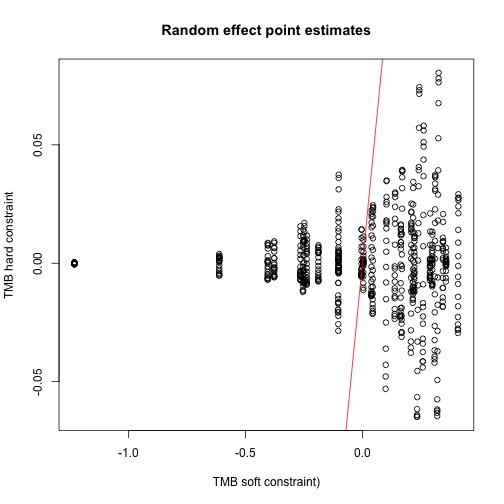

```r
plot(summary(sdr7, "report")[,1], summary(sdr7b, "report")[,1],
     xlab = "TMB soft constraint)", ylab = "TMB hard constraint",
     main = "Random effect point estimates")
abline(0, 1, col = "red")
```

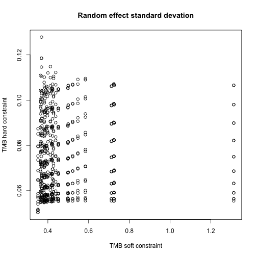

```r
plot(summary(sdr7, "report")[,2], summary(sdr7b, "report")[,2],
     xlab = "TMB soft constraint", ylab = "TMB hard constraint",
     main = "Random effect standard devation")
abline(0, 1, col = "red")
```

[figure not shown]

```r
plot(inlafit7C$summary.random[[1]][ , 2], summary(sdr7b, "report")[,1],
     xlab = "TMB soft constraint)", ylab = "TMB hard constraint",
     main = "Random effect point estimates")
abline(0, 1, col = "red")
```

[figure not shown]

```r
plot(inlafit7C$summary.random[[1]][ , 3], summary(sdr7b, "report")[,2],
     xlab = "TMB soft constraint", ylab = "TMB hard constraint",
     main = "Random effect standard devation")
abline(0, 1, col = "red")
```

## Model 8: ICAR space x RW1

For the `Cmatrix` version of the of the INLA model, the rank deficiency is \(rows + columns - 1\) since both are rank deficient one.

INLA automatically applies a sum-to-zero constraint for the spatial field at each time. This is too many constraints for an intercept plus interaction only model because it imposes that the average is the intercept at each time, and hence there is no time trend in the model.

The correct specification for this model should probably be a single sum-to-zero constraint to account for the lost degree of freedom from the intercept term

```r
inlafit8 <- inla(Observed ~
                   f(Year, model = "rw1", scale.model = TRUE,
                     hyper = prec.prior, diagonal = diagval, constr = TRUE,
                     group = ID,
                     control.group = list(model = "besag", graph = adj.mat, scale.model = TRUE)),
                 data = data, E = Expected, family = "poisson",
                 control.inla = list(strategy = "gaussian", int.strategy = "eb"),
                 control.compute = list(config = TRUE))
```

```r
grep(".*rank.*", inlafit8$logfile, value = TRUE)
```

```
## [1] "                computed/guessed rank-deficiency = [1]"
```

#### INLA with custom Cmatrix

```r
R_space <- diag(rowSums(adj.mat)) - adj.mat
R_space_scaled <- inla.scale.model(R_space, constr = list(A = matrix(1, ncol = ncol(R_space)), e = 0))
R_space_scaled_adj <- R_space_scaled + Matrix::Diagonal(ncol(R_space_scaled), diagval)

D_time <- diff(diag(length(levels(data$Yearf))), differences = 1)
R_time <- Matrix::Matrix(t(D_time) %*% D_time)
R_time_scaled <- inla.scale.model(R_time, constr = list(A = matrix(1, ncol = ncol(R_time)), e = 0))
R_time_scaled_adj <- R_time_scaled + Matrix::Diagonal(ncol(R_time_scaled), diagval)

R_space_time <- kronecker(R_time_scaled, R_space_scaled)

rankdef <- nrow(R_space) + ncol(R_time) - 1

Aconstr <- t(model.matrix(~0+IDf, data[order(data$id.area.year), ]))

inlafit8C <- inla(Observed ~
                   f(id.area.year, model = "generic0", Cmatrix = R_space_time,
                     hyper = prec.prior, diagonal = diagval, rankdef = rankdef,
                     extraconstr = list(A = Aconstr, e = numeric(nrow(Aconstr)))),
                 data = data, E = Expected, family = "poisson",
                 control.inla = list(strategy = "gaussian", int.strategy = "eb"),
                 control.compute = list(config = TRUE))

grep(".*rank.*", inlafit8C$logfile, value = TRUE)
```

```
## [1] "                rank-deficiency is *defined* [50]"
```

The precision parameter estimates match

```r
summary(inlafit8)
```

```
##
## Call:
##    c("inla.core(formula = formula, family = family, contrasts = contrasts, ", " data = data, quantiles = quantiles, E = E, offset = offset, ", " scale = scale, weights = weights, Ntrials = Ntrials, strata = strata, ",
##    " lp.scale = lp.scale, link.covariates = link.covariates, verbose = verbose, ", " lincomb = lincomb, selection = selection, control.compute = control.compute, ", " control.predictor = control.predictor,
##    control.family = control.family, ", " control.inla = control.inla, control.fixed = control.fixed, ", " control.mode = control.mode, control.expert = control.expert, ", " control.hazard = control.hazard,
##    control.lincomb = control.lincomb, ", " control.update = control.update, control.lp.scale = control.lp.scale, ", " control.pardiso = control.pardiso, only.hyperparam = only.hyperparam, ", " inla.call = inla.call,
##    inla.arg = inla.arg, num.threads = num.threads, ", " blas.num.threads = blas.num.threads, keep = keep, working.directory = working.directory, ", " silent = silent, inla.mode = inla.mode, safe = FALSE, debug = debug,
##    ", " .parent.frame = .parent.frame)")
## Time used:
##     Pre = 2.52, Running = 0.435, Post = 0.0331, Total = 2.99
## Fixed effects:
##               mean   sd 0.025quant 0.5quant 0.975quant mode kld
## (Intercept) -0.019 0.03     -0.078   -0.019      0.039   NA   0
##
## Random effects:
##   Name     Model
##     Year RW1 model
##
## Model hyperparameters:
##                      mean     sd 0.025quant 0.5quant 0.975quant mode
## Precision for Year 569.88 667.77      50.16   368.25    2327.13   NA
##
## Marginal log-Likelihood:  -1201.32
##  is computed
## Posterior summaries for the linear predictor and the fitted values are computed
## (Posterior marginals needs also 'control.compute=list(return.marginals.predictor=TRUE)')
```

```r
summary(inlafit8C)
```

```
##
## Call:
##    c("inla.core(formula = formula, family = family, contrasts = contrasts, ", " data = data, quantiles = quantiles, E = E, offset = offset, ", " scale = scale, weights = weights, Ntrials = Ntrials, strata = strata, ",
##    " lp.scale = lp.scale, link.covariates = link.covariates, verbose = verbose, ", " lincomb = lincomb, selection = selection, control.compute = control.compute, ", " control.predictor = control.predictor,
##    control.family = control.family, ", " control.inla = control.inla, control.fixed = control.fixed, ", " control.mode = control.mode, control.expert = control.expert, ", " control.hazard = control.hazard,
##    control.lincomb = control.lincomb, ", " control.update = control.update, control.lp.scale = control.lp.scale, ", " control.pardiso = control.pardiso, only.hyperparam = only.hyperparam, ", " inla.call = inla.call,
##    inla.arg = inla.arg, num.threads = num.threads, ", " blas.num.threads = blas.num.threads, keep = keep, working.directory = working.directory, ", " silent = silent, inla.mode = inla.mode, safe = FALSE, debug = debug,
##    ", " .parent.frame = .parent.frame)")
## Time used:
##     Pre = 2.63, Running = 0.421, Post = 0.0201, Total = 3.07
## Fixed effects:
##               mean   sd 0.025quant 0.5quant 0.975quant mode kld
## (Intercept) -0.019 0.03     -0.078   -0.019      0.039   NA   0
##
## Random effects:
##   Name     Model
##     id.area.year Generic0 model
##
## Model hyperparameters:
##                              mean     sd 0.025quant 0.5quant 0.975quant mode
## Precision for id.area.year 569.88 667.76      50.16   368.25    2327.12   NA
##
## Marginal log-Likelihood:  -1201.32
##  is computed
## Posterior summaries for the linear predictor and the fitted values are computed
## (Posterior marginals needs also 'control.compute=list(return.marginals.predictor=TRUE)')
```

Marginal likelihood

```r
inlafit8$mlik
```

```
##                                            [,1]
## log marginal-likelihood (integration) -1202.529
## log marginal-likelihood (Gaussian)    -1201.322
```

```r
inlafit8C$mlik
```

```
##                                            [,1]
## log marginal-likelihood (integration) -1202.529
## log marginal-likelihood (Gaussian)    -1201.322
```

Same number of constraints. Different order since we switched the main and group effect order.

```r
nrow(inlafit8$misc$configs$constr$A)
```

```
## [1] 32
```

```r
nrow(inlafit8C$misc$configs$constr$A)
```

```
## [1] 32
```

Hyper parameters

```r
inlafit8$internal.summary.hyperpar[, 1:2]
```

```
##                            mean        sd
## Log precision for Year 5.885989 0.9721213
```

```r
inlafit8C$internal.summary.hyperpar[, 1:2]
```

```
##                                    mean        sd
## Log precision for id.area.year 5.885989 0.9721182
```

Fixed effects

```r
inlafit8$summary.fixed[ , 1:2]
```

```
##                    mean         sd
## (Intercept) -0.01943739 0.03001591
```

```r
inlafit8C$summary.fixed[ , 1:2]
```

```
##                    mean         sd
## (Intercept) -0.01943739 0.03001591
```

Random effects

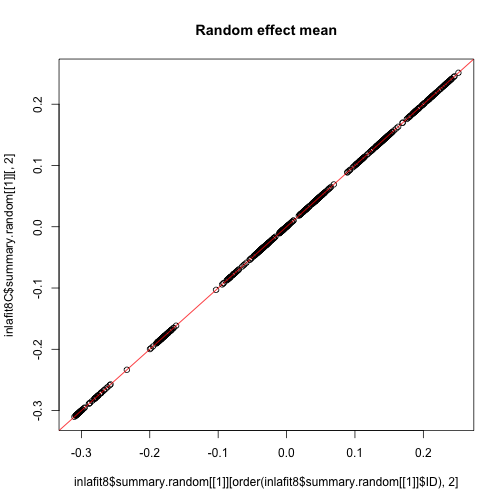

```r
plot(inlafit8$summary.random[[1]][order(inlafit8$summary.random[[1]]$ID), 2],
     inlafit8C$summary.random[[1]][,2],
     main = "Random effect mean")
abline(a = 0, b = 1, col = "red")
```

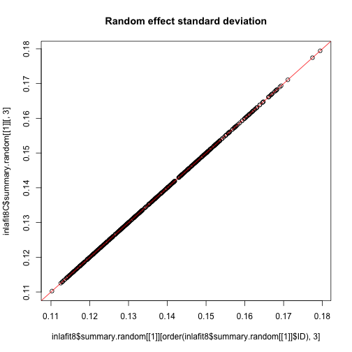

```r
plot(inlafit8$summary.random[[1]][order(inlafit8$summary.random[[1]]$ID), 3],
     inlafit8C$summary.random[[1]][,3],
     main = "Random effect standard deviation")
abline(a = 0, b = 1, col = "red")
```